# 基于 Reinforce Tactics 的策略类强化学习学习指南

# 基于 Reinforce Tactics 的策略类强化学习学习指南

## 从游戏机制、数学基础到 PPO、分层强化学习与 AlphaZero

版本 2.0 基准日期 2026-07-29

> 本合订本由分章 Markdown 自动生成。正文、图表和实验材料均来自新版目录。

# 第 00 章 序言、学习目标与实践路线

## 0.1 本书要解决的问题

强化学习教材常从马尔可夫决策过程或 Bellman 方程开始。这样的安排在数学上严谨，却容易使初学者把“公式”“框架接口”和“真实游戏行为”视为三件互不相干的事情。本书采用相反的路线：先观察一局可运行的策略游戏，再逐层回答以下问题。

1. 游戏中的局面怎样变成神经网络能够接收的数值？
2. 建造、移动、攻击和结束回合怎样变成动作空间？
3. 胜负很晚才发生时，算法如何判断早先哪一步有贡献？
4. 为什么一个语法正确的奖励函数仍可能教出拖延、刷伤害或只造单一兵种的策略？
5. PPO、DQN、A2C、MCTS 和 AlphaZero 分别解决什么问题，哪些真正适合本项目？
6. 训练曲线好看是否表示模型真的更会玩游戏？

读完全书后，读者应能独立完成“检查环境—选择动作表示—设计奖励—训练—评估—诊断—复现实验”的闭环，而不只是复制一条训练命令。

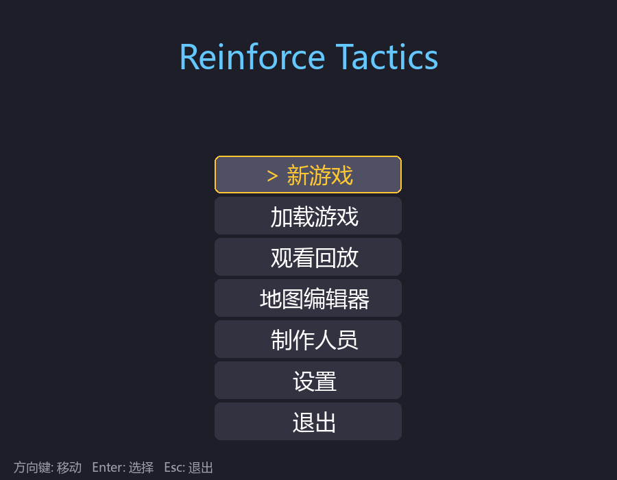

中文主菜单

## 0.2 读者需要具备什么

本书假定读者：

- 能阅读 Python 函数、类、列表、字典和异常；
- 理解循环、条件分支和基本调试；
- 知道程序会从文件读取配置并产生输出；
- 不要求学过概率论、微积分、线性代数或机器学习。

第三至第五章会补齐后续公式真正需要的数学。这里的“补齐”不是回避推导，而是把推导拆成可以逐步核验的小问题。每个核心公式都会说明计算对象、每个符号、数值例子、代码位置和易错理解。

## 0.3 项目在本书中的角色

Reinforce Tactics 是一个回合制策略游戏，同时提供可无界面运行的游戏引擎和 Gymnasium 环境。它适合作为学习载体，原因不是“规则简单”，而是它包含许多现实强化学习系统共有的困难：

| 项目现象 | 强化学习问题 |
| --- | --- |
| 一回合可连续操作多支单位 | 环境步与领域回合不一致 |
| 动作由类型、单位、起点和终点组成 | 结构化动作与组合爆炸 |
| 大多数动作组合违反游戏规则 | 非法动作掩码 |
| 赢棋要经过造兵、行军、战斗和占领 | 长期信用分配 |
| 对手也在学习或变化 | 非平稳训练分布 |
| 地图尺寸不同 | 观察与动作空间兼容 |
| 中间奖励可被反复获取 | 奖励投机 |
| 胜率来自有限局数 | 统计不确定性 |

因此，本项目既能演示标准接口，也能说明“算法公式正确”为什么不等于“完整系统正确”。

## 0.4 五层知识结构

本书把一个强化学习项目分成五层。

1. **领域层**：游戏规则、状态、合法动作和胜负。
2. **环境层**：观察、动作编码、奖励、终止与截断。
3. **算法层**：价值估计、策略更新、搜索与模仿。
4. **训练层**：课程、对手池、回调、日志和 checkpoint。
5. **证据层**：评估设计、置信区间、回放和可复现记录。

排查问题时必须先确定错误属于哪一层。例如，模型持续输出无效动作可能来自环境掩码，而不是 PPO 学习率；胜率突然下降可能来自评估对手变化，而不是模型权重退化。

## 0.5 环境安装与验证

本机约定使用 Conda 环境 `reinforce-tactics`。从仓库根目录执行：

```powershell
conda activate reinforce-tactics
python -c "import sys, gymnasium, stable_baselines3, sb3_contrib, torch; print(sys.version); print(gymnasium.__version__, stable_baselines3.__version__, sb3_contrib.__version__, torch.__version__)"
```

本书验证输出的主要版本为 Python 3.12.13、Gymnasium 1.3.0、Stable-Baselines3 2.9.0、sb3-contrib 2.9.0 和 PyTorch 2.13.0 CPU。若第一行的 Python 不是 Conda 环境中的解释器，后续出现 `ModuleNotFoundError` 时应先修正环境，而不是重复安装到系统 Python。

检查包和项目导入：

```powershell
python -c "from reinforcetactics.rl.gym_env import StrategyGameEnv; env=StrategyGameEnv(map_file='maps/1v1/starter.csv', opponent='noop'); print(env.observation_space); print(env.action_space); env.close()"
```

这条命令不训练模型，只确认项目、地图、观察空间和动作空间能够创建。

## 0.6 如何理解“冒烟实验”

强化学习具有随机性，短跑只能验证接口，不能验证最终能力。本书使用三类证据，标记方式如下。

| 标记 | 含义 | 可以得出的结论 |
| --- | --- | --- |
| CPU 冒烟 | 数十至数千步 | 接口可运行、张量形状正确、损失可计算 |
| 历史长训 | 仓库保存的长期运行记录 | 在特定版本、配置和随机种子下出现过某结果 |
| 算法性质 | 公式、论文或实现逻辑 | 在相应假设下成立的理论或结构事实 |

“64 步训练成功”只表示训练循环完成，不表示策略学会获胜。反过来，单次长训成功也不证明参数普遍有效；需要多随机种子和固定评估协议。

## 0.7 代码阅读方法

阅读本书中的代码时，建议保持三个问题：

1. 输入和输出的形状是什么？
2. 这个函数改变了什么状态？
3. 这个数值是游戏规则、训练信号还是评估指标？

例如 `reward` 是训练信号，不是 GUI 中的游戏积分；`step` 是一次环境微动作，不一定是一整个玩家回合；`done` 在现代 Gymnasium 中应拆成 `terminated` 与 `truncated`。

## 0.8 学习检查

完成本章后，应能回答：

1. 为什么本项目比单步分类任务更适合展示信用分配？
2. 为什么训练短跑不能证明模型已经学会游戏？
3. 环境创建失败时，为什么先检查 Python 解释器比调算法超参数更合理？
4. 领域层、环境层和算法层分别负责什么？

下一章先建立领域层：游戏究竟要求智能体做什么。

# 第 01 章 游戏规则与策略问题

## 1.1 棋盘与一局游戏

Reinforce Tactics 在方格地图上进行。地图包含可通行地形、阻挡地形以及总部、塔楼等建筑。每名玩家拥有金币、单位和建筑控制权。玩家在自己的回合中可以执行多个微动作，最后显式结束回合。对局通常通过占领敌方总部、消灭满足规则条件的敌方力量，或在最大回合数处形成和局而结束。

[figure not shown]

Beginner 地图对局

游戏逻辑的单一真源是 `reinforcetactics/core/game_state.py` 中的 `GameState`。GUI、规则 Bot、LLM Bot、强化学习环境和锦标赛都应通过同一规则层改变状态。这个设计非常重要：如果训练环境另写一套简化规则，模型可能在训练器里合法、进入 GUI 后却无法行动。

## 1.2 八类单位

项目包含八类单位。精确数值由常量和可能的 `engine_overrides` 决定，因此本书以稳定的功能角色为主。

| 单位 | 代码 | 主要角色 | 学习上的意义 |
| --- | --- | --- | --- |
| Warrior | `W` | 低成本近战基础单位 | 容易形成单兵种局部最优 |
| Mage | `M` | 法术攻击 | 需要选择高价值目标 |
| Cleric | `C` | 治疗或净化 | 奖励常延迟体现为存活率 |
| Archer | `A` | 远程攻击 | 位置和射程关系重要 |
| Knight | `K` | 高机动或冲击 | 行动价值依赖路径与时机 |
| Rogue | `R` | 灵活战术单位 | 增加动作组合和反制关系 |
| Sorcerer | `S` | 增益、减益和控制 | 动作目标依赖更复杂 |
| Barbarian | `B` | 高攻击近战 | 成本、伤害与生存的权衡 |

单位类型不是独立标签。选择造什么兵取决于金币、建筑、地图距离、敌方组成和未来数个回合。仅按“当前伤害最大”行动会忽略经济与占领目标。

## 1.3 建筑、收入与占领

建筑同时承担经济、生产和胜负功能。控制建筑通常会在回合转换时产生收入；某些建筑允许创建单位；敌方总部是核心战略目标。占领不是瞬时视觉效果，而是由单位在合法位置执行 `seize` 一类动作改变控制进度或归属。

经济系统制造了强化学习中的延迟收益：

- 花费金币造兵会使当前资源减少；
- 新单位可能数回合后才参与战斗；
- 占领中立建筑的直接收益有限，但之后每回合增加收入；
- 过度储蓄在数值上安全，却可能失去地图控制。

因此，一步奖励不能只按金币余额增加。否则智能体可能拒绝合理消费。

## 1.4 玩家回合与环境步

游戏回合不是强化学习环境中的一个 `step`。智能体的一回合可表示为：

```
创建单位 → 移动单位 A → 攻击 → 移动单位 B → 占领 → 结束回合
```

上述每个箭头前的操作通常各占一个环境步。只有执行 `end_turn` 后，环境才让规则 Bot 完成其整个回合，再把控制权交回智能体。

| 概念 | 作用域 | 典型代码 |
| --- | --- | --- |
| 环境步 | 一次微动作 | `StrategyGameEnv.step(action)` |
| 玩家回合 | 当前玩家的一组动作 | `GameState.current_player` |
| 完整轮次 | 双方都行动一次 | 由游戏回合计数体现 |
| 一局 episode | 从初始状态到终止或截断 | `reset` 到下一次 `reset` |

这个区别影响折扣：若一局有 80 个游戏回合，但每回合平均有 8 个微动作，终局奖励可能距离开局约 640 个环境步。

## 1.5 合法动作

`GameState.get_legal_actions(player)` 根据当前状态生成合法操作。合法性至少依赖：

- 当前玩家及单位所有权；
- 单位是否已行动、是否受到状态效果；
- 起点、终点、射程和路径；
- 目标位置是否被占用；
- 金币是否足够、建筑是否允许生产；
- 技能类型与目标类型是否匹配；
- 游戏是否已结束。

合法动作集合会在每一步后变化。移动一个单位可能使另一个单位的路径失效；购买会改变金币；攻击可能消灭目标；占领会改变建筑归属。因此，动作掩码不能只在 `reset` 时计算一次。

## 1.6 胜利与失败

强化学习环境关心的是终局语义，而不是 GUI 是否显示结束画面。项目的 `info["end_reason"]` 可区分总部占领、消灭、最大回合和最大环境步等原因。需要特别区分：

- **规则终止**：游戏规则确认胜、负或和，例如最大游戏回合导致和局；
- **外部截断**：环境达到 `max_steps`，但规则内的游戏仍可能继续。

终止意味着该轨迹在 MDP 内真正结束；截断通常意味着数据收集器提前停止。二者对价值函数是否继续 bootstrap 的处理不同，第七和第十二章会严格展开。

## 1.7 策略不只是战斗

一个完整策略至少包含四个互相制约的层面。

1. **经济**：何时消费、生产何种单位。
2. **机动**：如何分配单位、选择路径和保持阵形。
3. **战斗**：目标优先级、射程、治疗、控制与风险。
4. **目标**：占领中立建筑、防守总部、推进敌方总部并结束游戏。

历史训练中出现“只造 Warrior”并不表示模型完全没有学习。它可能学到了一个在当前价格、对手和奖励下足够稳定的局部最优。要判断问题来自算法还是平衡，需要将单位组成、对局结果和地图目标一起分析。

## 1.8 对手是环境的一部分

从智能体的接口看，执行 `end_turn` 后发生的对手行动属于环境转移。若对手是固定脚本，转移分布相对稳定；若对手从池中随机抽取，转移带有额外随机性；若对手不断换成当前策略的最新快照，环境变得非平稳。

同一策略面对不同对手可能呈现不同胜率。因此，“模型强度”不是脱离对手定义的单一数值。课程学习需要明确每一阶段的对手，最终评估需要固定锚点。

## 1.9 一个手工决策例

假设当前有足够金币建造一个 Warrior 或保留资金，前方有中立塔楼：

- 立即造兵：当前金币下降，但下一回合多一个可推进单位；
- 保留金币：当前资源指标更高，但可能让对手先占塔；
- 移动现有单位：短期没有伤害奖励，但缩短占领距离；
- 攻击附近敌人：获得即时战斗信号，却可能偏离总部目标。

这个例子说明奖励函数必须表达“最终赢棋优先”，中间信号只能充当路标。若击伤奖励可以无限获取而占领只奖励一次，智能体就可能主动维持战斗而不结束游戏。

## 1.10 本章练习

1. 给出一个“当前金币减少但长期价值增加”的动作。
2. 为什么 `end_turn` 必须是一个可学习的动作，而不能总由环境自动执行？
3. 若评估时换了更强 Bot，胜率下降是否足以证明模型退化？
4. 为什么合法动作必须在每个环境步重新计算？

# 第 02 章 智能体、环境与马尔可夫决策过程

## 2.1 强化学习闭环

强化学习研究连续决策。智能体观察环境，选择动作；环境执行规则，返回新观察和奖励；这一过程重复到 episode 结束。

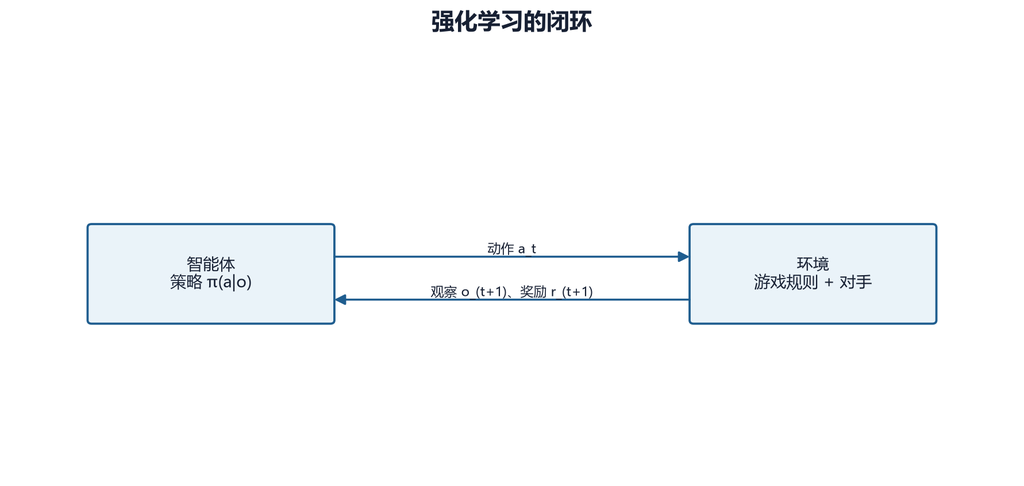

智能体与环境闭环

形式化地，一条轨迹写作：

$$\tau=(S_0,A_0,R_1,S_1,A_1,R_2,\ldots,S_T)$$

| 符号 | 含义 | 本项目实例 |
| --- | --- | --- |
| $S_t$ | 时刻 $t$ 的完整状态 | 棋盘、双方单位、金币、回合等 |
| $A_t$ | 在状态 $S_t$ 选择的动作 | 创建、移动、攻击、占领或结束回合 |
| $R_{t+1}$ | 动作后得到的即时奖励 | 终局、占领、势能变化等 |
| $T$ | episode 最后一步 | 胜负、规则和局或外部截断 |

奖励下标写成 $R_{t+1}$，强调它是在执行 $A_t$ 后才得到。不同资料也会写成 $r_t$；只要定义一致，两种记法都可使用。

## 2.2 MDP 五元组

马尔可夫决策过程（MDP）通常定义为：

$$\mathcal{M}=(\mathcal{S},\mathcal{A},P,R,\gamma)$$

- $\mathcal{S}$：所有可能状态的集合；
- $\mathcal{A}$：动作集合；
- $P(s'|s,a)$：在状态 $s$ 执行动作 $a$ 后转移到 $s'$ 的概率；
- $R(s,a,s')$：转移对应的奖励；
- $\gamma$：折扣因子，决定未来奖励的当前权重。

“马尔可夫”不是说未来与历史毫无关系，而是说：给定当前完整状态后，预测下一状态不再需要更早历史。

$$P(S_{t+1}|S_t,A_t,S_{t-1},A_{t-1},\ldots)=P(S_{t+1}|S_t,A_t)$$

在本项目中，若 `GameState` 包含单位状态、金币、当前玩家、回合、控制权和所有会影响规则的计数器，它可以近似视为马尔可夫状态。若漏掉“单位本回合是否行动”等变量，相同棋盘外观可能产生不同合法动作，观察便不再满足马尔可夫性。

## 2.3 状态与观察

算法通常不直接接收 `GameState` 对象，而接收数值观察 $O_t$：

$$O_t = f(S_t)$$

函数 $f$ 把复杂状态编码成 `grid`、`units` 和 `global_features`。若编码保留了决策所需的全部信息，可以把观察近似当作状态；若启用战争迷雾，智能体只能看见局部信息，问题更接近部分可观测 MDP（POMDP）。

POMDP 额外考虑隐藏状态和观察生成：

$$O_t \sim \Omega(\cdot|S_t)$$

此时同一个观察可能对应多个真实局面。无记忆策略只能按当前可见信息行动；带循环网络、历史堆叠或显式信念状态的策略才可能利用过去推断隐藏单位。本项目主线策略没有完整的信念状态建模，因此战争迷雾应被视为显著增加难度的实验条件。

## 2.4 转移概率从何而来

游戏规则本身大多是确定的，但整体转移仍可能随机：

- Bot 的随机选择或随机决胜规则；
- 地图随机生成；
- 初始状态或玩家座次；
- 自对弈对手池抽样；
- 随机种子未统一时的多个随机数生成器。

即使环境完全确定，随机策略也会产生不同轨迹。训练中的随机性至少来自策略采样、环境随机和优化器的小批次。

## 2.5 策略

策略 $\pi$ 描述在观察下如何选择动作。随机策略写作：

$$\pi_\theta(a|o)=P(A_t=a|O_t=o;\theta)$$

$\theta$ 是神经网络参数。确定性评估通常选择概率最大的合法动作；随机训练则按分布采样，以获得探索。

策略不是“把局面映射为唯一动作”的表。对 PPO 而言，它是可微的概率分布；对 DQN 而言，常先估计每个动作的 $Q$ 值，再用 ε-greedy 选择；对 MCTS 而言，最终动作分布来自搜索访问次数。

## 2.6 为什么本项目训练接口是单智能体 1v1

游戏引擎支持多种玩家布局，但 `StrategyGameEnv` 的 RL 观察采用“自己/对手”相对通道，且以 `opp = 3 - player` 的方式确定唯一对手。这一编码天然面向两名玩家。

训练时，学习智能体控制一方；另一方 Bot 在智能体结束回合后由环境内部执行。因此，从 Gymnasium API 看只有一个学习者。这样可以直接使用 Stable-Baselines3 的单智能体算法。

真正的多智能体环境需要明确：

- 每个智能体分别看到什么；
- 同时还是轮流行动；
- 奖励是共享、零和还是个体化；
- 智能体退出后环境怎样继续；
- 队友与敌人的相对编码。

`pyproject.toml` 虽列出 PettingZoo 依赖，但当前主训练路径没有实现 PettingZoo 的 AEC 或 Parallel 环境。不能因为依赖存在就声称项目已经具备通用多智能体训练接口。

## 2.7 微动作 MDP 的时间尺度

设一个玩家回合平均含 $m$ 个微动作，一局含 $H$ 个玩家回合，则 episode 大约含 $mH$ 个智能体环境步，再加上对手在环境内部执行的动作。折扣按环境步生效：

$$\text{终局权重}\approx\gamma^{mH}$$

若 $\gamma=0.99$、$mH=500$：

$$0.99^{500}\approx 0.0066$$

开局看到的终局奖励只剩原始量级的约 0.66%。这不是说 PPO完全忽略终局，而是说明长微动作轨迹会加剧信用分配困难。提高 $\gamma$、缩短 episode、合理塑形、课程学习和分层决策都在不同层面缓解该问题。

## 2.8 终止与截断属于模型定义

若总部被占领，后续状态没有意义，属于 `terminated=True`。若达到外部 `max_steps`，游戏规则仍可继续，属于 `truncated=True`。对价值目标：

$$y_t =
\begin{cases}
r_{t+1}, & \text{规则终止}\\
r_{t+1}+\gamma V(s_{t+1}), & \text{时间截断且下一状态可估值}
\end{cases}$$

把两者都当作终止会在截断边界错误地把未来价值设为零；反过来，把真正失败也 bootstrap 会让价值穿过不应存在的终局。

## 2.9 MDP 建模检查表

建立新地图或新规则实验时，应检查：

1. 观察是否包含影响合法动作和奖励的状态变量？
2. 动作编码是否能唯一还原领域动作？
3. 奖励是否与最终目标一致？
4. `terminated` 和 `truncated` 是否语义正确？
5. 对手、随机地图和座次是否进入种子控制？
6. 不同地图的空间形状是否与同一模型兼容？

## 2.10 本章练习

1. 指出一个在 GUI 中可见但可能不应直接作为奖励的量。
2. 战争迷雾为何使问题从近似 MDP 变成 POMDP？
3. 计算 $\gamma=0.99$ 时距离 200 步的终局奖励权重。
4. 为什么“项目依赖 PettingZoo”不等于“当前 RL 环境是 PettingZoo 多智能体环境”？

# 第 03 章 概率与统计基础

## 3.1 为什么强化学习离不开概率

同一个模型在同一地图上重复对局，结果仍可能不同。原因包括策略采样、随机对手、随机座次和环境随机。训练日志记录的是随机变量的样本，不是永远不变的真值。

理解概率的目标不是手算复杂积分，而是能够区分：

- 一局结果与长期平均；
- 观测到的胜率与真实胜率；
- 策略给出的动作概率与动作价值；
- 随机波动与系统性退化。

## 3.2 样本空间、事件与概率

一次评估对局的样本空间可简化为：

$$\Omega=\{\text{胜},\text{负},\text{和}\}$$

事件“未输”包含胜与和。概率满足 $0\le P(E)\le1$，所有互斥完备结果的概率和为 1。

若固定模型和评估协议，重复对局可视为从某个未知分布采样。改变对手、地图、座次或确定性参数，会改变分布；此时不能把两组结果直接合并成同一个胜率。

## 3.3 随机变量

随机变量把随机结果映射成数值。例如定义得分：

$$X=
\begin{cases}
1,&\text{胜}\\
0.5,&\text{和}\\
0,&\text{负}
\end{cases}$$

这样平均得分可以同时反映胜、和、负。若只计算 `wins / games`，和局与失败都会计为 0；这种定义可以使用，但必须在报告中写清楚。

回报 $G$、episode 长度、单位数量和伤害也都是随机变量。

## 3.4 期望

离散随机变量的期望是概率加权平均：

$$\mathbb{E}[X]=\sum_x P(X=x)x$$

若胜、和、负概率分别为 0.6、0.2、0.2，则上面的期望得分为：

$$0.6\times1+0.2\times0.5+0.2\times0=0.7$$

期望 0.7 不表示某一局会得到 0.7，而表示大量同分布对局的长期平均趋近 0.7。

强化学习的目标通常写成：

$$J(\theta)=\mathbb{E}_{\tau\sim\pi_\theta}[G(\tau)]$$

它表示按当前策略产生轨迹时，轨迹回报的期望。训练无法枚举所有轨迹，只能用有限批轨迹估计。

## 3.5 方差与标准差

期望描述中心，方差描述波动：

$$\mathrm{Var}(X)=\mathbb{E}\left[(X-\mathbb{E}[X])^2\right]$$

标准差是方差的平方根：

$$\sigma_X=\sqrt{\mathrm{Var}(X)}$$

两个策略平均回报相同，但一个每局接近平均，另一个在大胜与惨败之间跳动，它们的稳定性不同。训练中高方差会使优势估计噪声增大；评估中高方差需要更多对局。

数字例：样本 $2,4,6$ 的均值为 4。与均值的差为 $-2,0,2$，平方为 $4,0,4$。若按总体方差除以 3：

$$\mathrm{Var}(X)=\frac{4+0+4}{3}=\frac83,\quad \sigma\approx1.63$$

## 3.6 样本均值与标准误

评估 $n$ 局得到样本 $X_1,\ldots,X_n$，样本均值为：

$$\bar X=\frac1n\sum_{i=1}^{n}X_i$$

样本均值本身也会随机变化。其标准误近似为：

$$\mathrm{SE}(\bar X)=\frac{s}{\sqrt n}$$

局数扩大 4 倍，标准误约减半，而不是缩小到四分之一。这说明从 20 局提高到 80 局很有价值，但继续从 800 局提高到 860 局的边际收益很小。

## 3.7 胜率的二项近似

暂时忽略和局，将胜负视为 Bernoulli 变量。真实胜率为 $p$，评估 $n$ 局的胜率估计 $\hat p$ 的标准误近似：

$$\mathrm{SE}(\hat p)=\sqrt{\frac{\hat p(1-\hat p)}{n}}$$

若 $\hat p=0.70,n=80$：

$$\mathrm{SE}\approx\sqrt{\frac{0.7\times0.3}{80}}\approx0.051$$

粗略 95% 区间用 $\hat p\pm1.96\,\mathrm{SE}$，约为 $0.70\pm0.10$。因此观测 70% 不代表真实胜率精确等于 70%。

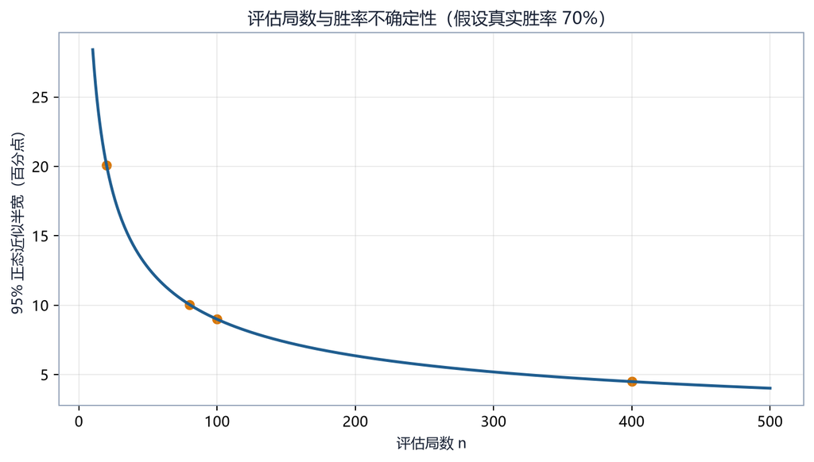

评估局数与不确定性

在局数很少或胜率接近 0/1 时，正态近似可能不可靠。正式报告可使用 Wilson 区间或 bootstrap，但不能只显示一个百分比。

## 3.8 条件概率

条件概率表示已知条件后的概率：

$$P(A|B)=\frac{P(A\cap B)}{P(B)}$$

例如“总体胜率 70%”可能掩盖：

| 条件 | 胜率 |
| --- | --- |
| 先手 | 85% |
| 后手 | 55% |

若训练与评估座次比例不同，总体胜率变化可能只是条件分布改变。分析时应按地图、对手、座次和终局原因分组。

## 3.9 独立性与伪重复

如果确定性 Bot、固定地图和固定种子产生完全相同的轨迹，重复 100 次不等于获得 100 个独立样本。样本数看似增大，实际有效信息没有增加。

历史平衡实验曾遇到重复轨迹：相同开局和确定性决胜规则使多局结果完全一致。解决方式不是只增加局数，而是引入受控随机性、交换座次并检查轨迹哈希或行为统计。

## 3.10 多随机种子

神经网络训练结果受初始化、采样和并行调度影响。比较算法时至少应报告多个训练种子：

$$\bar m=\frac1K\sum_{k=1}^K m_k$$

这里 $m_k$ 是第 $k$ 个训练种子的最终指标。评估局数增加只能降低“对局采样误差”，不能消除“训练种子差异”。二者必须分开。

## 3.11 本章练习

1. 策略 A 在 20 局中赢 14 局，计算胜率和近似标准误。
2. 为什么把相同确定性轨迹重复 100 次不能提供 100 个独立样本？
3. 平均回报相同的两个模型，为什么还要比较方差和终局类型？
4. 将评估局数从 25 提高到 100，标准误约缩小为原来的多少？

# 第 04 章 微积分、梯度与神经网络

## 4.1 从函数开始

函数把输入映射成输出：

$$y=f(x)$$

例如，线性函数 $f(x)=2x+1$ 在 $x=3$ 时输出 7。神经网络也是函数，只是输入、参数和输出都可能是高维数组。

在强化学习中常见三类函数：

- 策略函数：观察 $o$ 映射为动作概率；
- 价值函数：观察 $o$ 映射为期望回报；
- Q 函数：观察与动作 $(o,a)$ 映射为动作价值。

训练的本质是调整函数的参数，使损失减小或期望回报增大。

## 4.2 标量、向量、矩阵和张量

| 对象 | 例子 | 程序中的典型形状 |
| --- | --- | --- |
| 标量 | 奖励 $r=1.5$ | `()` |
| 向量 | 5 个全局特征 | `(5,)` |
| 矩阵 | 高 × 宽的地图 | `(H, W)` |
| 三阶张量 | 带通道的地图 | `(H, W, C)` |
| 批张量 | 一批地图 | `(B, H, W, C)` |

“维数”可能指向量长度，也可能指张量轴数。阅读代码时应直接写形状，避免只说“高维”。

向量点积：

$$\mathbf{w}^{\mathsf T}\mathbf{x}=\sum_{i=1}^d w_i x_i$$

若 $\mathbf{x}=[2,3]$、$\mathbf{w}=[0.5,-1]$，点积为：

$$0.5\times2+(-1)\times3=-2$$

神经网络的全连接层对一批输入执行矩阵乘法并加偏置：

$$\mathbf{y}=W\mathbf{x}+\mathbf{b}$$

## 4.3 导数表示局部变化率

导数回答：“输入稍微变化，输出怎样变化？”

$$f'(x)=\lim_{\Delta x\to0}\frac{f(x+\Delta x)-f(x)}{\Delta x}$$

对 $f(x)=x^2$，导数为 $f'(x)=2x$。在 $x=3$ 处导数为 6，表示输入增加一个很小的量 $\Delta x$ 时，输出约增加 $6\Delta x$。

训练不要求手算极限，但需要理解导数的符号：

- 正导数：参数增大时目标局部增大；
- 负导数：参数增大时目标局部减小；
- 接近零：局部变化不敏感，可能接近极值或进入平坦区。

## 4.4 偏导数与梯度

损失通常依赖许多参数：

$$L=L(\theta_1,\theta_2,\ldots,\theta_n)$$

对每个参数分别求偏导，组成梯度：

$$\nabla_\theta L=
\left[
\frac{\partial L}{\partial\theta_1},
\frac{\partial L}{\partial\theta_2},
\ldots,
\frac{\partial L}{\partial\theta_n}
\right]$$

梯度指向损失局部增长最快的方向。要减小损失，梯度下降更新为：

$$\theta\leftarrow\theta-\alpha\nabla_\theta L$$

其中 $\alpha$ 是学习率。若参数 $\theta=2$、梯度为 3、学习率为 0.1，则新参数为 $2-0.1\times3=1.7$。

学习率太大可能越过低点甚至发散；太小则训练缓慢。梯度是局部信息，不保证一步到达全局最优。

## 4.5 链式法则

神经网络由多层函数复合而成：

$$y=f(g(x))$$

链式法则：

$$\frac{dy}{dx}=\frac{df}{dg}\frac{dg}{dx}$$

数字例：$g(x)=2x$，$f(g)=g^2$，则 $y=(2x)^2=4x^2$。

$$\frac{df}{dg}=2g,\quad\frac{dg}{dx}=2,\quad\frac{dy}{dx}=4g=8x$$

反向传播就是从损失向前层反向应用链式法则。PyTorch 自动记录运算图并计算这些梯度。

## 4.6 激活函数

如果连续多层都只有线性变换，它们仍等价于一个线性变换。激活函数引入非线性。

ReLU：

$$\mathrm{ReLU}(x)=\max(0,x)$$

双曲正切：

$$\tanh(x)=\frac{e^x-e^{-x}}{e^x+e^{-x}}$$

Softmax 把 logits 转为离散概率：

$$p_i=\frac{e^{z_i}}{\sum_j e^{z_j}}$$

若 logits 为 $[2,1,0]$，指数近似为 $[7.39,2.72,1]$，概率约为 $[0.665,0.245,0.090]$。logit 增大不等于概率等量增加，因为概率还受其他动作影响。

## 4.7 对数与对数概率

策略梯度使用 $\log\pi_\theta(a|o)$。对数有两个重要性质：

$$\log(xy)=\log x+\log y,\qquad \frac{d}{dx}\log x=\frac1x$$

轨迹概率是多个动作概率的乘积，取对数后变成和，数值更稳定。对小概率动作，$\log p$ 是较大的负数：

| $p$ | $\log p$ |
| --- | --- |
| 0.9 | -0.105 |
| 0.5 | -0.693 |
| 0.1 | -2.303 |
| 0.01 | -4.605 |

负对数似然损失 $-\log p$ 会在正确动作概率很小时产生较大惩罚。

## 4.8 神经网络的一次训练

以监督目标 $y$ 为例：

1. 前向：$\hat y=f_\theta(x)$；
2. 损失：$L(\hat y,y)$；
3. 清空旧梯度；
4. 反向：计算 $\nabla_\theta L$；
5. 优化器更新参数。

```python
optimizer.zero_grad()
prediction = network(x)
loss = loss_fn(prediction, target)
loss.backward()
optimizer.step()
```

强化学习的不同之处主要在“目标从哪里来”。行为克隆有专家标签；DQN 的标签来自奖励和目标网络；PPO 的目标来自轨迹、价值估计和新旧策略概率比。

## 4.9 卷积与空间结构

棋盘相邻关系具有局部性。卷积层用一个小核在地图上滑动，在不同位置共享参数。相同的“附近有敌人”检测器可应用于地图各处。

展平输入会把相邻格变成向量中相邻或不相邻的索引，网络需要重新学习空间关系；卷积直接编码局部连接和平移共享。项目的 `SpatialFeatureExtractor` 将 `grid` 与 `units` 通道组合后使用卷积，并可加入坐标通道与掩码平均池化。

## 4.10 常见误解

- 梯度不是“正确答案”，只是当前参数附近的改进方向。
- 损失下降不保证游戏胜率上升；损失只反映训练目标。
- Softmax 概率高不表示动作合法，合法性仍需掩码。
- 网络更大不必然更强；数据分布、动作表示和奖励错误会限制上限。
- 反向传播不是强化学习特有技术，RL 只是用不同方式构造损失。

## 4.11 本章练习

1. 计算 $[1,2,3]$ 与 $[2,0,-1]$ 的点积。
2. 若梯度为 $-4$、学习率为 0.05，梯度下降对参数增加还是减少多少？
3. 为什么多个线性层之间必须加入非线性激活？
4. 为什么棋盘观察通常比纯展平输入更适合卷积？

# 第 05 章 强化学习基础

## 5.1 即时奖励与回报

即时奖励 $R_{t+1}$ 只描述一次转移。智能体要最大化的是从当前开始的长期回报：

$$G_t=R_{t+1}+\gamma R_{t+2}+\gamma^2R_{t+3}+\cdots$$

也可写成：

$$G_t=\sum_{k=0}^{T-t-1}\gamma^kR_{t+k+1}$$

| 符号 | 含义 | 范围 |
| --- | --- | --- |
| $G_t$ | 从时刻 $t$ 开始的折扣回报 | 由奖励尺度决定 |
| $\gamma$ | 折扣因子 | 通常 $0\le\gamma\le1$ |
| $k$ | 距离当前的步数 | 0,1,2,… |
| $T$ | episode 结束时刻 | 正整数 |

若奖励为 $1,1,1$，$\gamma=0.9$：

$$G_0=1+0.9+0.9^2=2.71$$

回报不等于日志里的“episode reward”在所有实现中的含义。监控器常记录未折扣奖励之和，而算法内部计算折扣目标。

## 5.2 折扣与有效时间范围

折扣有三种作用：

- 表达更早收益通常更确定；
- 控制无限序列的数学收敛；
- 决定信用能向多远传播。

常用近似有效范围：

$$H_{\mathrm{eff}}\approx\frac1{1-\gamma}$$

$\gamma=0.99$ 时约 100 步，$\gamma=0.997$ 时约 333 步。它不是硬边界，而是量级判断。

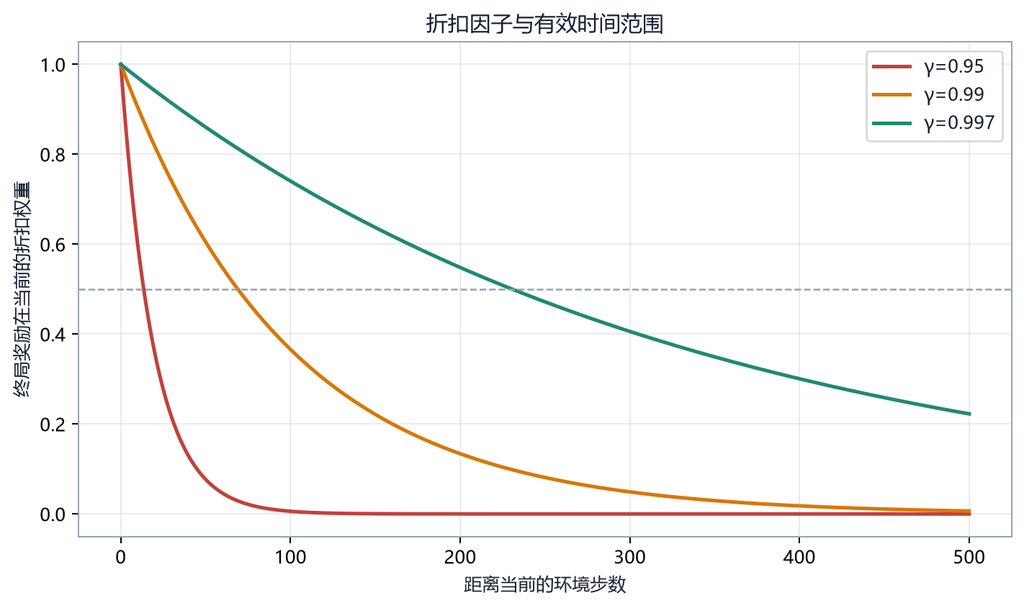

折扣因子与时间范围

项目一局可能包含数百微动作，因此固定使用 0.99 会使早期状态对远端终局的直接权重很低。提高 $\gamma$ 也会增加价值估计方差，不能只看“越长期越好”。

## 5.3 状态价值函数

策略 $\pi$ 下的状态价值：

$$V^\pi(s)=\mathbb{E}_\pi[G_t|S_t=s]$$

它表示从状态 $s$ 出发继续按策略 $\pi$ 行动的期望回报。价值是期望，不是胜负确定预测。

若某局面有 60% 概率得到 +10、40% 概率得到 -10：

$$V^\pi(s)=0.6\times10+0.4\times(-10)=2$$

实际一局不会得到 2，但长期平均为 2。

## 5.4 动作价值函数

$$Q^\pi(s,a)=\mathbb{E}_\pi[G_t|S_t=s,A_t=a]$$

它表示在 $s$ 先执行 $a$，以后再按 $\pi$ 行动的期望回报。DQN 直接近似 $Q$；Actor-Critic 通常分别表示策略和 $V$。

## 5.5 优势函数

$$A^\pi(s,a)=Q^\pi(s,a)-V^\pi(s)$$

优势衡量动作相对当前状态下策略平均水平的好坏。若 $V(s)=5$、$Q(s,a)=8$，优势为 +3；若 $Q=2$，优势为 -3。

使用优势而不是原始回报可以减少“本来就处于好局面”造成的共同偏移。策略梯度据此提高正优势动作的概率、降低负优势动作的概率。

## 5.6 Bellman 递推

回报可拆成当前奖励与下一状态回报：

$$G_t=R_{t+1}+\gamma G_{t+1}$$

对条件期望取平均：

$$V^\pi(s)=\mathbb{E}_\pi[R_{t+1}+\gamma V^\pi(S_{t+1})|S_t=s]$$

这就是 Bellman 期望方程。它的关键不是形式复杂，而是允许用“一步奖励 + 下一状态估值”学习长期价值。

Q 函数对应：

$$Q^\pi(s,a)=\mathbb{E}[R_{t+1}+\gamma\mathbb{E}_{a'\sim\pi}Q^\pi(S_{t+1},a')]$$

最优 Q 的 Bellman 方程将下一个动作替换为最大值：

$$Q^*(s,a)=\mathbb{E}[R_{t+1}+\gamma\max_{a'}Q^*(S_{t+1},a')]$$

## 5.7 Monte Carlo 与 TD

Monte Carlo（MC）等 episode 结束后用实际回报：

$$\text{target}_{MC}=G_t$$

优点是目标不依赖当前价值估计，缺点是必须等待终局且方差高。

一步 Temporal Difference（TD）使用：

$$\text{target}_{TD}=R_{t+1}+\gamma V(S_{t+1})$$

TD 可以在线更新，方差较低，但目标依赖不完美的 $V$，引入偏差。TD 误差：

$$\delta_t=R_{t+1}+\gamma V(S_{t+1})-V(S_t)$$

## 5.8 n 步回报与 GAE

n 步目标在 MC 与一步 TD 之间折中：

$$G_t^{(n)}=R_{t+1}+\gamma R_{t+2}+\cdots+\gamma^{n-1}R_{t+n}+\gamma^nV(S_{t+n})$$

GAE 用参数 $\lambda$ 对不同长度的 TD 信息加权：

$$\hat A_t^{GAE}=\sum_{l=0}^{\infty}(\gamma\lambda)^l\delta_{t+l}$$

$\lambda$ 越接近 0，越接近短程 TD；越接近 1，越依赖长程实际奖励。PPO 常见 $\gamma=0.99,\lambda=0.95$，但长微动作任务需要结合 episode 长度验证。

## 5.9 探索与利用

**利用**选择当前估计最好的动作，**探索**尝试不确定动作。只利用可能过早锁定局部最优；只探索则无法稳定执行已学策略。

不同算法使用不同机制：

- DQN：ε-greedy；
- PPO/A2C：从随机策略分布采样，并可加入熵奖励；
- AlphaZero：MCTS 访问分布与根节点 Dirichlet 噪声；
- 自对弈：改变对手分布形成战略探索。

策略熵：

$$\mathcal{H}(\pi)=-\sum_a\pi(a|s)\log\pi(a|s)$$

均匀分布熵高，单一动作概率接近 1 时熵低。熵系数太高会妨碍收敛，太低则容易过早确定化。

## 5.10 信用分配

信用分配回答：最终胜利应归因于哪些早期动作。策略游戏的困难来自：

- 因果链长；
- 同一动作在不同局面作用不同；
- 对手行动介于自己的两次决策之间；
- 奖励塑形可能提供错误捷径。

解决方案不是单一算法开关，而是组合：

- 正确的观察与动作表示；
- 合理 $\gamma$ 与 GAE；
- 价值函数；
- 势能塑形；
- 课程学习；
- 分层目标；
- 高质量评估。

## 5.11 On-policy 与 Off-policy

On-policy 算法主要使用当前策略刚产生的数据。PPO、A2C 属于此类；策略更新后旧数据很快失效，样本利用率较低但更新定义清晰。

Off-policy 算法可以重复使用旧策略数据。DQN 使用经验回放；样本利用率较高，但旧数据分布和当前策略不同，需要目标网络等稳定机制。

## 5.12 本章练习

1. 计算奖励 $2,0,3$、$\gamma=0.9$ 时的 $G_0$。
2. 若 $V=7,Q=4$，优势是多少，策略应倾向提高还是降低该动作概率？
3. 说明 MC 与一步 TD 的偏差—方差差别。
4. 为什么提高 $\gamma$ 不能自动解决长局训练？

# 第 06 章 用于强化学习的 PyTorch

## 6.1 张量与形状

PyTorch 的核心对象是 `torch.Tensor`。张量同时保存数值、数据类型、设备和可选梯度信息。

```python
import torch

x = torch.tensor([[1.0, 2.0], [3.0, 4.0]])
print(x.shape)   # torch.Size([2, 2])
print(x.dtype)   # torch.float32
print(x.device)  # cpu
```

强化学习中最常见的错误不是公式，而是形状：

- 环境返回 `(H,W,C)`，CNN 需要 `(B,C,H,W)`；
- 单个动作是 `(6,)`，批动作是 `(B,6)`；
- 布尔掩码长度必须与对应 logits 完全一致；
- 价值输出通常是 `(B,1)`，优势可能是 `(B,)`。

项目特征提取器会把批维和通道维整理为卷积所需格式。阅读 `permute`、`reshape`、`unsqueeze` 时，应在注释旁写出变换前后的形状。

## 6.2 自动求导

```python
x = torch.tensor(3.0, requires_grad=True)
y = x**2
y.backward()
print(x.grad)  # 6
```

PyTorch 在前向计算时记录运算图；`backward()` 从输出向参数应用链式法则。只有参与图且 `requires_grad=True` 的叶张量会积累梯度。

梯度默认累积，因此训练循环必须在每次更新前清零：

```python
optimizer.zero_grad()
loss.backward()
optimizer.step()
```

忘记清零会把多批梯度意外相加；在有意做梯度累积时才保留。

## 6.3 `nn.Module`

网络继承 `torch.nn.Module`：

```python
from torch import nn

class ValueNet(nn.Module):
    def __init__(self, input_dim: int):
        super().__init__()
        self.net = nn.Sequential(
            nn.Linear(input_dim, 128),
            nn.ReLU(),
            nn.Linear(128, 1),
        )

    def forward(self, x):
        return self.net(x)
```

`model.parameters()` 返回优化器要更新的参数；`state_dict()` 保存具名权重。checkpoint 若只保存 `state_dict`，可能遗漏优化器、训练步数、地图尺寸和架构超参数。本项目的 Feudal 与 AlphaZero checkpoint 因此还要保存 hyperparameters 和训练状态。

## 6.4 训练模式与评估模式

```python
model.train()
# 更新参数

model.eval()
with torch.no_grad():
    prediction = model(x)
```

`eval()` 会改变 dropout、batch normalization 等层的行为；`torch.no_grad()` 则关闭梯度记录以减少内存。二者作用不同，评估时通常都需要。

## 6.5 优化器

Adam 为每个参数维护一阶和二阶矩估计，常用于深度强化学习：

```python
optimizer = torch.optim.Adam(model.parameters(), lr=3e-4)
```

学习率仍是最重要的尺度之一。PPO 一次 rollout 会重复训练多个 epoch；学习率、epoch 数、batch size 和 clip range共同决定一次采样数据引起多大变化。

梯度裁剪：

```python
torch.nn.utils.clip_grad_norm_(model.parameters(), max_norm=0.5)
```

它限制整体梯度范数，缓解异常批次造成的巨大更新，但不能修复错误奖励尺度或 NaN 输入。

## 6.6 概率分布

离散策略常用 `torch.distributions.Categorical`：

```python
from torch.distributions import Categorical

logits = torch.tensor([[2.0, 1.0, 0.0]])
dist = Categorical(logits=logits)
action = dist.sample()
log_prob = dist.log_prob(action)
entropy = dist.entropy()
```

PPO 需要保存旧策略对已执行动作的 `log_prob`，更新时再用新策略计算同一动作的 `log_prob`。二者相减后取指数即可得到概率比：

$$\frac{\pi_{\mathrm{new}}(a|s)}{\pi_{\mathrm{old}}(a|s)}
=\exp(\log\pi_{\mathrm{new}}-\log\pi_{\mathrm{old}})$$

## 6.7 动作掩码在 logits 层生效

非法动作应在 softmax 前赋极小 logit：

```python
masked_logits = logits.masked_fill(~mask, -1e8)
dist = Categorical(logits=masked_logits)
```

这样非法动作概率近似为 0，合法动作重新归一化。若所有掩码均为 False，分布没有可选动作，因此项目保证 `end_turn` 始终可用。

逐维 MultiDiscrete 会为六个维度创建六个独立分布。即使每个维度值合法，组合仍可能非法；这是第十一章的核心问题。

## 6.8 项目的空间特征提取

`reinforcetactics/rl/extractors.py` 中的 `SpatialFeatureExtractor` 接收：

- `grid`：地形、建筑和归属通道；
- `units`：单位类型、归属、生命和状态通道；
- `global_features`：金币、回合和单位数量等摘要。

空间通道拼接后转为 `(B,C,H,W)`，经多层卷积提取局部关系。可选设计包括：

- `coord_conv`：加入归一化横纵坐标，使网络区分绝对位置；
- `extra_conv`：扩大感受野；
- `masked_avg`：跨地图 padding 时忽略填充格；
- 固定 `features_dim`：向策略和价值头提供稳定维度。

普通平均池化在 6×6 地图填充到 10×12 时，会把大量零填充纳入平均。掩码平均只统计真实地图区域，减少阶段切换造成的尺度变化。

## 6.9 数值稳定性

需要重点监控：

- logits 是否出现 `inf` 或 `nan`；
- value loss 是否被大终局奖励放大；
- `log(0)` 是否通过稳定分布实现避免；
- 观察是否归一化到合理范围；
- 掩码后是否至少有一个动作；
- 梯度范数是否持续撞上裁剪上限。

项目全局特征使用缩放和 `tanh`，避免金币数千而单位数量个位数造成输入尺度悬殊。归一化是表示设计的一部分，不是单纯“让网络更快”。

## 6.10 CPU 冒烟

```powershell
python -c "import torch; from reinforcetactics.rl.extractors import SpatialFeatureExtractor; print(torch.__version__, torch.cuda.is_available())"
```

本书基准输出为 CPU 版本且 `cuda=False`。所有短实验应显式允许 CPU；生产长训才需要结合硬件选择批大小和并行环境数。

## 6.11 本章练习

1. `(8,10,12,32)` 若代表 `(B,H,W,C)`，怎样变成 CNN 常用形状？
2. `model.eval()` 与 `torch.no_grad()` 有何不同？
3. 为什么梯度裁剪不能修复奖励正负号错误？
4. 为什么跨地图 padding 时掩码平均优于普通平均？

# 第 07 章 Gymnasium 环境契约

## 7.1 环境的最小接口

Gymnasium 将算法与领域规则隔离。算法只需要空间定义以及 `reset`、`step`：

```python
obs, info = env.reset(seed=42)
obs, reward, terminated, truncated, info = env.step(action)
```

`StrategyGameEnv` 继承 `gymnasium.Env`。创建后应满足：

- `obs` 属于 `observation_space`；
- `action` 属于 `action_space`；
- `reward` 可转换为标量浮点数；
- `terminated`、`truncated` 是布尔值；
- `info` 是诊断字典，不应被策略依赖为隐藏观察。

## 7.2 `reset`

`reset(seed=...)` 开始新 episode，重建游戏状态、对手、计数器和奖励势能基线。第一次重置通常应调用父类种子逻辑，以创建环境自己的随机数生成器。

```python
obs, info = env.reset(seed=7)
```

同一种子可帮助重现环境随机序列，但不能保证 GPU 并行训练逐位一致。项目还包含游戏引擎 RNG、Bot RNG、NumPy、Python 和 PyTorch 随机源，完整复现必须统一记录。

## 7.3 `step`

一次环境步的顺序可概括为：

1. 解码动作；
2. 按规则执行或判定无效；
3. 更新动作统计和即时奖励；
4. 若智能体结束回合，让对手完成回合；
5. 检查规则终局和外部步数上限；
6. 构造下一观察、奖励分解和诊断信息。

调用方循环：

```python
obs, info = env.reset(seed=42)
while True:
    action = env.action_space.sample()
    obs, reward, terminated, truncated, info = env.step(action)
    if terminated or truncated:
        break
```

随机采样没有使用合法动作掩码，因此可能产生无效动作；它只能验证接口，不是合理基线。

## 7.4 观察空间

默认观察是 `spaces.Dict`：

```
grid              (H, W, GRID_CHANNELS)
units             (H, W, UNIT_CHANNELS)
global_features   (5,)
visibility        (H, W)  # 仅战争迷雾
```

空间声明是契约。若 `Box` 声明范围 `[0,1]`，实际观察就不应出现未缩放金币 5000。`gymnasium.utils.env_checker.check_env` 可以发现形状、dtype 和返回值错误。

## 7.5 动作空间

默认：

```
MultiDiscrete([10, 8, W, H, W, H])
```

六个字段依次表示动作类型、单位类型、起点横纵坐标、目标横纵坐标。

Flat Discrete 模式：

```
Discrete(max_flat_actions)
```

每个索引在当前步骤映射到一条完整合法动作。两种模式的网络输出形状不同，模型不可互换。

## 7.6 终止与截断

Gymnasium 明确区分：

- `terminated=True`：任务定义内的终局；
- `truncated=True`：任务外条件提前停止，常见为时间限制。

价值目标在规则终止处不 bootstrap，在纯截断处通常要 bootstrap。官方 Gymnasium 文档专门强调这一差别，因为旧版 `done` 无法直接表达。

项目中：

| 原因 | 标志 | 含义 |
| --- | --- | --- |
| 总部占领、消灭 | `terminated` | 规则终局 |
| `max_turns` 和局 | `terminated` | 规则定义的和局 |
| `max_steps` | `truncated` | 收集器截断 |

将 `max_steps` 截断再额外施加 `draw` 惩罚，可能与算法的时间限制 bootstrap 同时作用，形成双重边界效应。当前环境把截断奖励设为显式可选项。

## 7.7 `info` 的作用

`info` 应保存诊断信息，例如：

- `winner`、`game_over`、`end_reason`；
- `reward_breakdown`；
- `n_legal_actions`；
- 单位创建、伤害、治疗和占领统计；
- episode 长度和累计奖励。

训练策略不应把只存在于 `info` 的隐藏敌方信息作为输入，否则训练和部署接口不一致。评估器可以使用它分解结果。

## 7.8 Wrapper

Wrapper 在不改领域环境的情况下增加行为。项目中的 `ActionMaskedEnv` 和自对弈环境都是 wrapper 或类似包装层。常见用途：

- 统一动作掩码接口；
- 记录 episode 指标；
- 向量化多个环境；
- 翻转玩家相对观察；
- 注入对手快照。

Wrapper 必须正确转发属性和 `reset/step`。多层 wrapper 下直接访问 `env.game_state` 可能失败，应通过框架提供的属性转发或 `unwrapped` 谨慎访问。

## 7.9 向量环境

VecEnv 同时推进多个独立环境，收集形状为 `(n_envs, ...)` 的批数据。若 PPO 的 `n_steps=2048,n_envs=8`，每次 rollout 收集：

$$2048\times8=16384$$

条转移。配置中的 `eval_freq`、callback 调用次数和实际总环境步之间可能因此出现倍数关系。解释训练日志必须知道指标按“算法调用”还是“总环境步”计数。

## 7.10 PettingZoo 边界

PettingZoo 为多智能体环境定义 AEC 和 Parallel API。当前项目虽依赖该包，但主环境仍是 Gymnasium 单智能体包装：对手回合发生在环境内部。若未来实现真正多智能体训练，需要新环境接口，而不是仅把 `opponent="self"` 称为 PettingZoo。

## 7.11 验证命令

```powershell
python -c "from gymnasium.utils.env_checker import check_env; from reinforcetactics.rl.gym_env import StrategyGameEnv; e=StrategyGameEnv(map_file='maps/1v1/starter.csv',opponent='noop',max_steps=16); check_env(e); print('check_env passed'); e.close()"
```

`check_env` 通过只说明 Gymnasium 契约基本一致，不验证奖励是否合理、掩码是否精确或 Bot 是否有竞争力。

## 7.12 本章练习

1. 写出当前 Gymnasium `step` 的五个返回值。
2. 为什么 `max_turns` 和 `max_steps` 在项目中采用不同结束标志？
3. `n_steps=512,n_envs=4` 时每次 PPO rollout 有多少条转移？
4. 为什么环境契约通过仍不能证明训练问题建模正确？

# 第 08 章 Stable-Baselines3 训练框架

## 8.1 框架负责什么

Stable-Baselines3（SB3）实现常用深度强化学习算法和训练基础设施。它负责：

- 策略、价值或 Q 网络；
- rollout buffer 或 replay buffer；
- 批处理、反向传播和优化器；
- 模型保存与加载；
- callback、日志与向量环境；
- `learn` 和 `predict` 的统一接口。

项目仍需负责环境、观察、动作、奖励、对手与评估。框架不会判断奖励是否鼓励真实胜利，也不会自动修复非法动作表示。

## 8.2 模型构造

```python
from stable_baselines3 import PPO

model = PPO(
    "MultiInputPolicy",
    env,
    learning_rate=3e-4,
    n_steps=2048,
    batch_size=64,
    n_epochs=10,
    gamma=0.99,
    gae_lambda=0.95,
    clip_range=0.2,
    verbose=1,
)
```

`MultiInputPolicy` 用于 `spaces.Dict` 观察。它不是算法名称，而是策略类选择。`policy_kwargs` 可以指定网络结构和自定义特征提取器。

## 8.3 `learn`

```python
model.learn(total_timesteps=100_000, callback=callbacks)
```

对 on-policy 算法，`learn` 循环收集 rollout、计算优势、进行多轮小批优化，再收集新数据。`total_timesteps` 是目标环境步数；向量环境和固定 rollout 长度可能使最终计数略超过目标。

PPO 的每次更新数据量：

$$N_{\mathrm{rollout}}=n_{\mathrm{steps}}\times n_{\mathrm{envs}}$$

若 batch size 不能整除该值，最后出现较小批次并产生警告。短实验应把 `batch_size` 设为 rollout 大小的因数。

## 8.4 `predict`

```python
action, state = model.predict(obs, deterministic=True)
```

`deterministic=True` 通常选择分布众数或最大 Q 动作，适合稳定评估；训练时算法会自行采样。对于 MaskablePPO，预测还需提供当前掩码：

```python
action, state = model.predict(
    obs,
    action_masks=env.action_masks(),
    deterministic=True,
)
```

若训练使用掩码而评估忘记传掩码，模型可能在评估时选择非法动作，造成“训练正常、评估很差”的测量错误。

## 8.5 On-policy rollout buffer

PPO/A2C 的 buffer 保存一段当前策略数据：

```
observation, action, reward, done,
value, log_probability, advantage, return
```

更新后通常清空，继续用新策略收集。旧 `log_probability` 用于计算 PPO 新旧概率比；value 用于 GAE。

## 8.6 DQN replay buffer

DQN 保存：

```
(observation, action, reward, next_observation, done)
```

训练时随机采样旧转移，打破相邻样本相关性并重复利用数据。由于数据来自旧策略，DQN 是 off-policy。经验回放不适用于普通 PPO，因为 PPO 目标假设数据来自旧策略的已知快照且只进行受限更新。

## 8.7 Monitor 与日志

`Monitor` 记录 episode 回报、长度和额外信息。TensorBoard 展示：

- `rollout/ep_rew_mean`、`ep_len_mean`；
- `train/policy_gradient_loss`；
- `train/value_loss`；
- `train/entropy_loss`；
- `train/approx_kl`；
- `train/clip_fraction`；
- `time/fps` 和步数。

这些指标必须结合环境结果解释。价值损失下降不等于胜率上升；平均回报上涨可能来自塑形刷分；熵降低可能是合理收敛，也可能是过早坍缩。

## 8.8 Callback

Callback 在训练事件上执行逻辑：

- 周期评估；
- checkpoint 保存；
- 课程晋级；
- 熵系数调度；
- 指标记录；
- 早停或停滞异常。

回调频率容易受 `n_envs` 影响。应在代码中确认 `n_calls`、`num_timesteps` 和实际环境步的关系，而不是只看配置名。

项目的 `PeriodicEvalCallback` 和 `PromotionCallback` 进一步记录胜负、终局原因、动作分布和晋级状态。

## 8.9 模型保存与环境兼容

SB3 `.zip` 通常保存策略参数、算法超参数和空间信息。加载时环境必须兼容：

- 观察键、形状和 dtype；
- 动作空间类型与尺寸；
- 自定义特征提取器导入路径；
- 掩码接口；
- 地图 padding 与单位集合。

MultiDiscrete 模型不能直接放到 Flat Discrete 环境，因为输出头完全不同。仅文件能加载不代表环境语义相同；奖励和对手变化也会影响评估。

## 8.10 `sb3-contrib`

实验性或扩展算法位于 `sb3-contrib`。项目主线使用 `MaskablePPO`。官方接口要求环境暴露 `action_masks()`；在 `SubprocVecEnv` 下，掩码必须在环境内部实现，不能只靠主进程包装函数。

项目提供 `make_maskable_env` 和 `make_maskable_vec_env` 统一构建环境，避免不同训练脚本漏传参数。

## 8.11 配置优先级

项目高级训练脚本通常采用：

1. dataclass 默认；
2. YAML/JSON 配置；
3. CLI 显式覆盖。

最终运行配置必须落盘。只保存原始 YAML 不够，因为 CLI 可能改过值；只保存命令也不够，因为默认值可能随版本变化。`run_config` 一类工具应记录合并后的配置、版本、Git 提交、设备和种子。

## 8.12 最小接口检查

```powershell
python -c "from sb3_contrib import MaskablePPO; from reinforcetactics.rl.masking import make_maskable_env; e=make_maskable_env(map_file='maps/1v1/starter.csv',opponent='noop',action_space_type='flat_discrete',max_flat_actions=128); m=MaskablePPO('MultiInputPolicy',e,n_steps=32,batch_size=32,n_epochs=1,device='cpu',verbose=0); m.learn(64); print('learn passed'); e.close()"
```

这条命令验证 64 步训练循环，不评价策略强度。

## 8.13 本章练习

1. `MultiInputPolicy` 与 PPO 的关系是什么？
2. 为什么 PPO 不能像 DQN 一样任意重复使用很久以前的数据？
3. 训练使用动作掩码时，评估为何也必须传掩码？
4. 模型文件能加载时，还需要检查哪些环境兼容项？

# 第 09 章 项目运行时与数据流

## 9.1 分层结构

项目不是“一个训练脚本加一个环境”。主要层次如下：

| 层 | 主要职责 | 代表模块 |
| --- | --- | --- |
| 入口 | 参数解析与模式分发 | `main.py`、`reinforcetactics/cli` |
| 应用 | GUI 会话、输入和 Bot 工厂 | `reinforcetactics/app` |
| 领域 | 游戏状态、单位、地图和规则 | `reinforcetactics/core`、`game` |
| RL 环境 | 观察、动作、奖励、掩码 | `reinforcetactics/rl/gym_env.py` |
| 训练 | PPO、课程、自对弈、Feudal、AlphaZero | `reinforcetactics/rl`、`scripts/train` |
| 评估 | 模型评估、锦标赛、Elo | `rl/evaluation.py`、`tournament` |

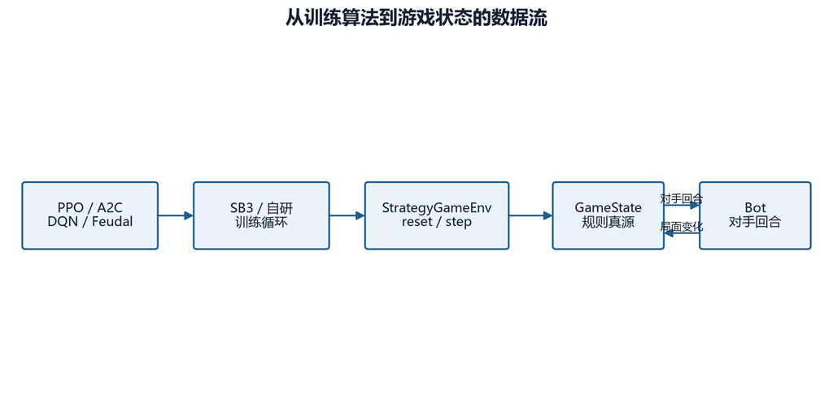

项目数据流

领域层应保持为规则真源。RL 环境可以编码和计分，却不应偷偷改变移动、攻击或占领规则。

## 9.2 CLI 的四种模式

`main.py` 提供 `train`、`evaluate`、`play` 和 `stats`。

```powershell
python main.py --mode play
python main.py --mode train --algorithm ppo --timesteps 100000
python main.py --mode evaluate --model models/ppo_final.zip --episodes 20
python main.py --mode stats
```

基础 CLI 适合理解入口，但不是当前最可靠的生产训练路径：

- `ppo` 使用普通 PPO，不自动使用动作掩码；
- `a2c` 同样没有掩码；
- `dqn` 默认创建 MultiDiscrete 环境，而 SB3 DQN 只接受 Discrete，当前会在模型构造处失败；
- 课程、BC、自对弈、Feudal 和 AlphaZero 各有独立脚本。

教材不会把“参数可选”误写成“训练路径已验证”。

## 9.3 `GameState` 的职责

`GameState` 保存并改变：

- 地图与建筑；
- 单位及其生命、位置和状态；
- 当前玩家、回合和金币；
- 合法动作；
- 移动、攻击、治疗、技能和占领；
- 胜负与最大回合；
- 可选的规则常量覆盖。

GUI 人类操作、Bot 和环境最终都应调用这些领域操作。例如环境解码出 `move` 后，仍由规则层验证移动。训练环境不能假设掩码永远正确；执行时必须再次校验。

## 9.4 `StrategyGameEnv.__init__`

构造函数把游戏实例包装为 RL 任务。关键参数：

| 参数 | 作用 |
| --- | --- |
| `map_file` | 固定地图；为空时随机生成 |
| `opponent` | 规则 Bot、随机、noop、自对弈或空 |
| `max_steps` | 外部环境步上限 |
| `max_turns` | 游戏规则回合上限 |
| `reward_config` | 奖励权重覆盖 |
| `enabled_units` | 可创建兵种集合 |
| `fog_of_war` | 部分可观测模式 |
| `action_space_type` | `multi_discrete` 或 `flat_discrete` |
| `max_flat_actions` | Flat 模式固定上限 |
| `max_actions_per_turn` | 防止永不结束回合 |
| `gamma` | 势能塑形折扣，应与训练器一致 |
| `pad_to_size` | 跨地图统一观察尺寸 |
| `engine_overrides` | 平衡实验覆盖 |

构造函数固定 RL 环境为 1v1；GUI 的多人模式不经过同一观察契约。

## 9.5 `reset` 数据流

重置时必须同时恢复领域状态和训练辅助状态：

```
加载初始地图
→ 创建新的 GameState
→ 初始化/重新绑定对手
→ 确定 agent_player
→ 清零步数、动作与 episode 统计
→ 初始化势函数 Φ(s₀)
→ 构建 flat 合法动作（若启用）
→ 返回观察和 info
```

势能塑形的 `_prev_potential` 必须设为初始状态的 $\Phi(s_0)$，不能简单设为 0；否则 episode 第一步会凭空得到 $\gamma\Phi(s_1)$。

## 9.6 `step` 数据流

环境每步大致执行：

```
输入动作
→ 根据动作空间解码为六字段动作
→ 执行领域动作
→ 记录无效、伤害、治疗、购买、占领等事件
→ 计算本方动作即时奖励
→ 如果 end_turn：运行对手完整回合并记录对手事件
→ 检查规则终局 / max_steps
→ 计算势能变化和终局奖励
→ 构建下一观察、掩码所需合法动作和 info
```

动作执行和奖励计算不能随意交换。若在对手回合前就计算完整势能差，就会漏掉对手夺取建筑和造成伤害；若终局先关闭势能而后又重复计算，奖励分解会不守恒。

## 9.7 对手回合

智能体选择 `end_turn` 后：

1. `GameState.end_turn()` 把控制权给对手；
2. 环境调用对手 `take_turn()`；
3. Bot 内部执行多个领域动作并结束自己的回合；
4. 控制权回到智能体。

历史实现曾出现环境在 Bot 已结束回合后再调用一次 `end_turn`，导致玩家被切换两次。此类错误会让观察与当前玩家不一致，训练表现看似随机。当前逻辑应检查 Bot 执行后 `current_player`，只在仍未归还时补救。

## 9.8 自对弈工厂

`opponent="self"` 本身不包含对手网络。训练脚本通过：

```
set_self_play_opponent_factory(factory)
```

注入一个函数，根据新的 `GameState` 和对手玩家创建快照 Bot。每次 `reset` 都要重新绑定到新状态，不能让 Bot 保留上一个 episode 的 `GameState` 引用。

## 9.9 配置流

高级训练使用 `reinforcetactics/rl/config.py` 的 dataclass：

```
EnvConfig
PPOConfig
FeudalConfig
SelfPlayConfig
AlphaZeroConfig
CurriculumStage / CurriculumConfig
EvalConfig / LoggingConfig
TrainingConfig
```

`load_config` 读取 YAML/JSON，`apply_overrides` 应用点号路径 CLI 覆盖。训练器最终得到一个合并后的 `TrainingConfig`。记录实验时必须保存这一最终对象，而非只保存原始 YAML。

## 9.10 数据形状穿过各层

```
GameState 对象
  ↓ build_observation
Dict[str, np.ndarray]
  ↓ VecEnv
Dict[str, np.ndarray]，带批维 B
  ↓ features extractor
Tensor[B, features_dim]
  ↓ 策略/价值头
动作分布 + V(o)
  ↓ sample / predict
NumPy 动作
  ↓ env.step
领域动作
```

调试时沿这条链逐层打印形状，比直接查看最终 loss 更有效。

## 9.11 失败归属示例

| 现象 | 优先检查层 |
| --- | --- |
| 动作索引越界 | 动作编码/环境 |
| 训练 loss 为 NaN | 观察、奖励尺度、网络 |
| 只会结束回合 | 掩码、奖励、探索和对手 |
| 训练胜率高、GUI 不能加载 | 空间/特征提取器/checkpoint |
| 换地图构造失败 | observation/action shape |
| 同模型重复评估结果完全相同 | 对手 RNG 与种子 |

## 9.12 本章练习

1. 为什么 Bot 必须在每次 `reset` 后绑定新的 `GameState`？
2. 势能基线若错误设为 0，第一步奖励会出现什么偏差？
3. 基础 CLI 的 DQN 为什么不是当前可直接运行的默认路径？
4. 说明从 `GameState` 到策略 logits 的数据形状链。

# 第 10 章 观察编码与空间特征

## 10.1 观察设计决定可学信息

神经网络只能使用观察中出现的信息。奖励再合理、算法再先进，也无法弥补关键状态缺失。反过来，把无关或泄漏的信息加入观察，会让训练指标虚高、部署失败。

项目观察为字典：

$$o_t=\{\text{grid},\text{units},\text{global\_features},[\text{visibility}]\}$$

字典观察允许分别处理空间平面和全局向量。

## 10.2 `grid`

`grid` 的形状为：

```
(H, W, GRID_CHANNELS)
```

通道表达地形、建筑类别、相对归属和结构生命等。使用 one-hot 或归一化通道而不是把所有类别压成一个整数，有两个优点：

- 数字大小不暗示不存在的顺序关系；
- 卷积可以分别学习“水域”“总部”“敌方归属”等检测器。

若用地形编号 1、2、3，网络会把编号 3 当作比 1“大”；one-hot 不引入这种错误几何。

## 10.3 `units`

`units` 也是 `(H,W,C)`，包含：

- 单位类型 one-hot；
- 自己/对手相对归属；
- 是否已行动；
- 生命比例；
- 麻痹、加速、防御和攻击增益等状态。

“是否已行动”是马尔可夫状态的重要部分。若只编码单位位置和类型，相同画面下合法动作可能不同。

## 10.4 `global_features`

五维全局摘要包括双方金币、回合与双方单位数。原始数值量级差异很大，因此构造观察时按 `gold_scale`、`turn_scale` 和 `unit_count_scale` 缩放，再通过 `tanh` 映射到稳定范围。

例如金币特征可写为：

$$x_{\mathrm{gold}}=\tanh\left(\frac{\mathrm{gold}}{c_{\mathrm{gold}}}\right)$$

若缩放常数为 1000，金币 100 的输入约 0.10，金币 5000 接近饱和。缩放常数应覆盖课程中的典型经济范围；太小会让大量状态挤在 1 附近，太大则差异过小。

## 10.5 玩家相对视角

观察不是固定用“玩家 1/玩家 2”通道，而是“自己/对手”。这使同一策略可以控制不同座次：

```
绝对 player 1 / player 2
          ↓ perspective_player
相对 self / opponent
```

自对弈翻转视角时，还要交换金币、归属、可见性和当前玩家含义。只交换单位 owner 而不交换全局特征会产生内部矛盾。

## 10.6 战争迷雾

启用 `fog_of_war` 后增加可见性平面，并隐藏不可见敌军。需要同时检查：

- 隐藏单位是否从 `units` 移除；
- 合法动作是否泄漏隐藏目标；
- LLM 序列化是否泄漏；
- 自对弈翻转后是否用正确玩家可见性；
- `info` 中的诊断是否被策略误用。

普通无记忆策略面对同一观察无法区分不同隐藏局面。若研究战争迷雾，应考虑循环策略、观察历史或信念建模，而不是只打开布尔开关后沿用所有结论。

## 10.7 跨地图 padding

同一个神经网络要求固定输入形状。课程从 6×6 到 10×12 时，可把小地图补零到最大尺寸：

```
真实 6×6 区域 + 其余 padding
```

`pad_to_size=(pad_h,pad_w)` 不能小于当前地图。当前实现只对 Flat Discrete 模式完整支持，因为 MultiDiscrete 的动作维度本身包含 $W,H$，仅填充观察仍不能统一动作空间。

padding 需要配套：

- 空间通道填零；
- 坐标通道按统一规则生成；
- 池化忽略填充格；
- 合法动作只指向真实地图；
- LLM 或 GUI 坐标转换保持原地图坐标。

## 10.8 默认展平的代价

SB3 的普通组合提取器会将空间张量展平，再送入线性层。输入维度随地图面积增长：

$$D=H\times W\times(C_{\mathrm{grid}}+C_{\mathrm{units}})$$

第一层参数约为 $D\times d_{\mathrm{hidden}}$。地图扩大时参数数量增长，且相邻关系没有显式结构。

## 10.9 `SpatialFeatureExtractor`

空间提取器的概念流程：

```
grid + units
→ 通道拼接
→ (B,H,W,C) 转 (B,C,H,W)
→ 可选坐标通道
→ 多层 3×3 卷积
→ masked average / average / flatten
→ 拼接 global_features
→ 线性投影到 features_dim
```

坐标卷积解决“卷积平移共享但总部角落具有绝对意义”的矛盾。额外卷积扩大感受野，使高层特征能覆盖更大邻域。掩码平均使小地图的特征不被零填充稀释。

## 10.10 观察检查

```powershell
python -c "from reinforcetactics.rl.gym_env import StrategyGameEnv; e=StrategyGameEnv(map_file='maps/1v1/beginner.csv',opponent='noop'); o,_=e.reset(seed=42); print({k:(v.shape,v.dtype,float(v.min()),float(v.max())) for k,v in o.items()}); e.close()"
```

应检查每个键的形状、dtype、最小最大值以及 `observation_space.contains(obs)`。只检查 shape 不足以发现越界或 NaN。

## 10.11 历史问题：空间盲性

2026-07-24 的管线审查指出，早期生产配置使用默认展平网络，策略需要从头学习地图邻接关系。后续配置引入 `SpatialFeatureExtractor`、坐标通道、更深卷积和掩码池化。

这个修复提高了表示能力，但不能单独证明胜率提升。正确实验需要保持动作空间、奖励、对手、种子和训练预算不变，只替换特征提取器，并进行多种子对比。

## 10.12 本章练习

1. 为什么单位“是否已行动”必须进入观察？
2. one-hot 地形相比单整数编码避免了什么错误假设？
3. 为什么 padding 观察不能自动解决 MultiDiscrete 跨地图动作空间变化？
4. 设计一个检查战争迷雾信息泄漏的测试。

# 第 11 章 动作空间与动作掩码

## 11.1 六字段动作

默认动作向量：

$$a=(t,u,x_s,y_s,x_d,y_d)$$

| 字段 | 含义 | 典型范围 |
| --- | --- | --- |
| $t$ | 动作类型 | 0-9 |
| $u$ | 创建单位类型 | 0-7 |
| $x_s,y_s$ | 起点 | 地图坐标 |
| $x_d,y_d$ | 目标点 | 地图坐标 |

动作类型包括创建、移动、攻击、占领、治疗、结束回合以及多种技能。并非所有字段对每类动作有意义，例如 `end_turn` 不需要坐标，但固定长度便于统一接口。

## 11.2 组合空间

6×6 地图的完整组合数：

$$10\times8\times6\times6\times6\times6=103680$$

某一步真正合法动作常只有几十条。随机采样几乎必然无效。仅给无效动作负奖励会浪费样本，并使惩罚淹没游戏信号。

## 11.3 逐维掩码

MultiDiscrete MaskablePPO 为每个维度提供独立布尔掩码。例如合法动作只有：

```
move   from (1,0) to (2,0)
attack from (3,2) to (4,2)
end_turn
```

逐维掩码会分别允许：

```
type: move, attack, end_turn
from_x: 1, 3
from_y: 0, 2
to_x: 2, 4
to_y: 0, 2
```

独立分布可重组出 `move from (3,0) to (4,2)` 等从未存在的动作。掩码保证每个字段值曾在某条合法动作出现，却不能保证字段组合合法。

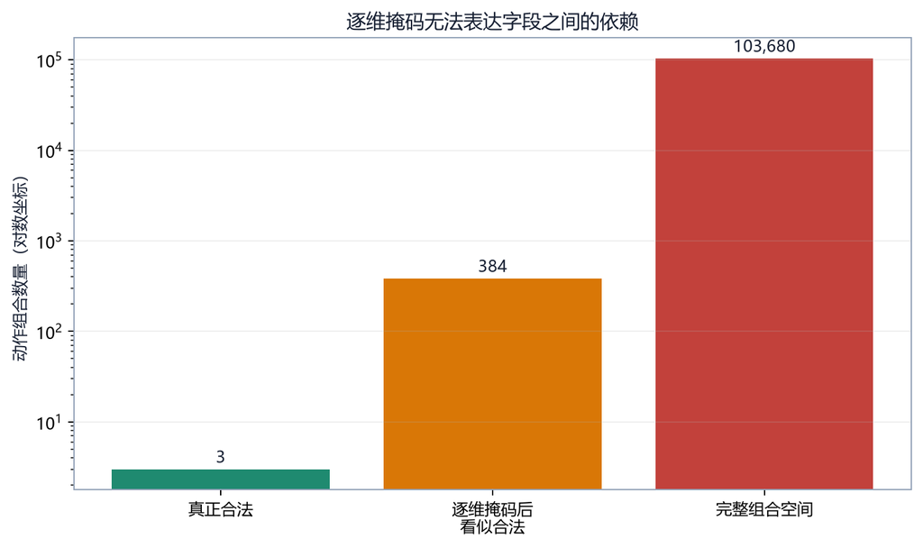

逐维掩码过度近似

若上述掩码还允许 8 个单位类型，近似组合为：

$$3\times8\times2\times2\times2\times2=384$$

真正合法只有 3 条，表面“通过掩码”的组合约 99.2% 仍无效。

## 11.4 历史基准证据

历史 PPO vs SimpleBot 基准在 10K、50K、200K 和 1M 步时胜率均为 0。前 200K 步 episode 常达到 500 步截断，平均回报约 -4965；1M 步后模型学会频繁 `end_turn`，平均局长降到约 10，但全部失败。

如果每局 500 步、无效率约 99%、无效惩罚 -10：

$$500\times0.99\times(-10)=-4950$$

这与观测回报接近，说明训练主要在学习避免接口惩罚，而不是游戏策略。

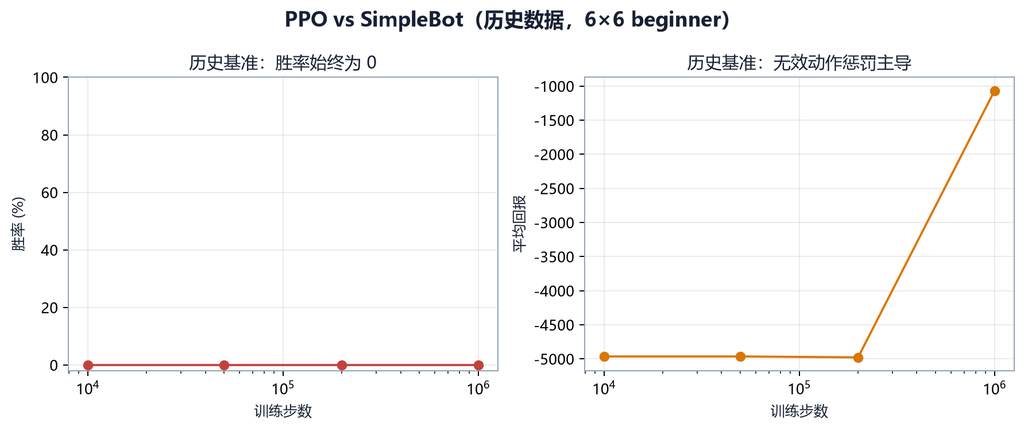

历史掩码失败基准

后期 `end_turn` 坍缩也有因果解释：它始终合法，可以避免 -10；但对手得到连续发展机会，模型迅速失败。

## 11.5 Flat Discrete 精确掩码

Flat 模式在每步枚举完整合法动作：

```
_current_actions = [
  [create, unit_type, x, y, x, y],
  [move, _, sx, sy, dx, dy],
  ...
  [end_turn, _, 0, 0, 0, 0],
]
```

动作空间固定为 `Discrete(max_flat_actions)`。前 `len(_current_actions)` 个索引对应真实动作，其余 padding 索引为 False。策略采样一个索引即可得到完整组合，因此掩码是精确的。

优势：

- 消除字段重组无效动作；
- DQN 也能使用 Discrete；
- 固定 `max_flat_actions` 可与观察 padding 共同支持跨地图。

代价：

- 索引语义随当前合法动作列表变化；
- 上限太小会截断合法动作；
- 上限太大使策略输出头变大；
- 若列表排序不稳定，同一索引在相似状态中含义变化剧烈。

2026-07-24 审查特别指出 Flat 动作索引按当前列表位置重建，策略难以形成稳定动作语义。精确合法性不等于理想表示。

## 11.6 上限与截断

`max_flat_actions` 必须覆盖课程最密集局面。若实际合法动作数超过上限，简单截断可能系统性丢掉排序靠后的单位或动作。

正确做法：

1. 在代表地图与高单位密度下记录 `n_legal_actions`；
2. 观察最大值和高分位数；
3. 检查截断日志；
4. 明确动作排序；
5. 必要时提高上限或改用结构化动作网络。

## 11.7 自回归动作头

自回归分解按条件选择：

$$p(a|s)=p(t|s)\,p(u|t,s)\,p(x_s,y_s|t,u,s)\,p(x_d,y_d|t,u,x_s,y_s,s)$$

先选动作类型，再根据类型生成相关字段掩码；选定起点后，目标掩码只包含该单位可执行目标。这样既保留结构语义，又能表达字段依赖。

项目 Feudal AR Worker 使用 `structured_action_masks()` 提供阶段条件掩码。代价是采样、log probability、entropy、训练评估和 batch 化都更复杂；任何阶段掩码错位都会破坏 PPO 概率比。

## 11.8 掩码概率

给合法指示 $m_i\in\{0,1\}$：

$$\pi'(a=i|s)=\frac{m_i e^{z_i}}{\sum_jm_je^{z_j}}$$

非法动作概率为 0，合法动作重新归一化。若 logits 对两个合法动作分别为 2 和 1，其他动作即使 logit 为 100 也会被掩掉，合法动作概率仍约为 0.731 与 0.269。

## 11.9 掩码必须进入整条链

- rollout 采样必须使用掩码；
- buffer 要保留与动作对应的掩码或能重建；
- 更新时计算 log probability 必须用相同语义掩码；
- `predict` 评估必须传掩码；
- 自对弈对手从翻转观察行动时也要用对手视角合法动作；
- SubprocVecEnv 的子环境必须原生暴露 `action_masks`。

只在训练 `sample` 时掩码、更新时不掩码，会使新旧概率不可比。

## 11.10 动手观察

```powershell
python agents/learning-guide-v2/tools/smoke_labs.py
```

结果中的 `mask_cross_product` 与 `domain_legal_actions` 展示逐维掩码的过度近似比；`action_space_compatibility` 展示 DQN 在两种空间下的构造差异。

## 11.11 选择建议

| 场景 | 建议 |
| --- | --- |
| 小地图、先验证可训练性 | Flat Discrete + MaskablePPO |
| 默认 MultiDiscrete 基线 | 可研究，但必须监控无效率 |
| 大地图、动作很多 | 自回归或合法动作评分网络 |
| DQN 实验 | 只能使用 Discrete 路径 |
| 跨地图同一模型 | Flat + padding，或重新设计固定结构动作 |

## 11.12 本章练习

1. 为什么每个维度都合法仍可能组成非法动作？
2. Flat Discrete 精确掩码解决了什么，又引入什么语义问题？
3. 为什么训练和评估必须使用一致掩码？
4. 写出自回归动作概率的条件分解。

# 第 12 章 奖励塑形、终止与截断

## 12.1 奖励不是评价报告

奖励是算法每步收到的训练信号。最终研究结论仍应依据规则胜负、固定对手和统计协议。一个模型可以获得高塑形回报却从不赢棋。

环境奖励可分为：

| 类别 | 示例 | 作用 |
| --- | --- | --- |
| 终局 | `win`、`loss`、`draw` | 明确任务目标 |
| 事件 | 创建、伤害、击杀、占领、治疗、技能 | 缩短信号距离 |
| 势能 | 收入差、单位差、建筑控制 | 对状态进展计分 |
| 约束 | 无效动作、回合限制 | 抑制退化行为 |

## 12.2 稀疏奖励

只在终局给：

$$r_t=
\begin{cases}
+1,&\text{胜}\\
-1,&\text{负}\\
0,&\text{其他}
\end{cases}$$

优点是目标纯净；缺点是随机策略很难产生胜利，数百步中大多数奖励为 0，信用分配困难。

## 12.3 直接稠密奖励的风险

若伤害 +1、击杀 +5、占领 +10，算法会最大化这些数字，而不是理解设计者意图。只要战斗可反复发生，累计伤害可能超过一次终局胜利。

奖励黑客不是模型“作弊”，而是模型正确优化了错误目标。处理方式是重新审视可重复性、量级和终局主导关系。

## 12.4 势能塑形

选择状态势函数 $\Phi(s)$，塑形项为：

$$F(s_t,s_{t+1})=\gamma\Phi(s_{t+1})-\Phi(s_t)$$

新奖励：

$$r'_t=r_t+F(s_t,s_{t+1})$$

在满足假设时，这种形式不会改变最优策略，只改变学习过程。直观上，状态变好时提前获得进展信号；将各步折扣求和后中间势能会相消。

三步展开：

$$\begin{aligned}
F_0+\gamma F_1+\gamma^2F_2
&=(\gamma\Phi_1-\Phi_0)
+\gamma(\gamma\Phi_2-\Phi_1)
+\gamma^2(\gamma\Phi_3-\Phi_2)\\
&=-\Phi_0+\gamma^3\Phi_3
\end{aligned}$$

中间 $\Phi_1,\Phi_2$ 抵消，这就是“势能差”而非“每步重复发钱”的关键。

## 12.5 势函数组成

项目可用加权状态差构造：

$$\Phi(s)=w_I\Delta I+w_U\Delta U+w_C\Delta C$$

- $\Delta I$：己方与对手收入差；
- $\Delta U$：单位数量或价值差；
- $\Delta C$：建筑控制差；
- $w_I,w_U,w_C$：`reward_config` 权重。

若 $\Phi(s_t)=10,\Phi(s_{t+1})=13,\gamma=0.99$：

$$F=0.99\times13-10=2.87$$

若状态保持不变，$F=0.99\times10-10=-0.1$。这反映折扣下维持势能也有轻微时间成本。

训练器和环境的 $\gamma$ 必须一致。否则塑形抵消关系相对于算法目标不成立。

## 12.6 终局的势能关闭

终局后不存在下一状态价值。若简单把 $\Phi(s_{T})$ 继续保留，策略可能偏好以高势能结束。项目在规则终止处对势能进行关闭处理，使塑形总和不改变终局排序；在纯截断处则按普通转移保留下一状态信息。

这再次说明 `terminated` 与 `truncated` 不能合并。

## 12.7 杀敌刷分

历史训练出现过 kill-farm draw plateau：

1. 智能体学会交战；
2. 伤害和击杀带来正奖励；
3. 对手补充单位，战斗可持续；
4. 占领与结束游戏的边际收益不足；
5. 双方战斗到最大回合，塑形回报仍较高。

修复不是单独“多训一会儿”，而是重新设计奖励几何：

- 降低可重复伤害/击杀权重；
- 对受到的伤害计负项，使交换近似零和；
- 提高占领和终局相对量级；
- 对和局给明确代价；
- 用 `max_turns` 形成规则和局；
- 按终局原因和奖励分解验证。

## 12.8 永不结束回合

早期 `turn_penalty` 只在 `end_turn` 时扣分。模型发现不结束回合即可回避该负奖励，于是反复执行合法但无进展动作，直到 `max_steps` 截断。

当前默认 `turn_penalty=0`。推进压力可通过终局速度奖励、折扣和每回合动作上限实现。`max_actions_per_turn` 达到上限后把掩码收缩到 `end_turn`，从环境约束层阻止无限循环。

这个案例说明：惩罚一个动作与惩罚一种行为并不等价。

## 12.9 和棋与截断

规则和棋应使用 `terminated=True` 并应用 `draw`。外部步数截断使用 `truncated=True`，默认不自动收取 draw；若要惩罚截断，应显式配置 `truncation` 并理解 SB3 的时间限制 bootstrap。

把截断同时当作负和局又 bootstrap 下一状态，会混合两个不同语义。实验报告必须分别统计 `max_turns_draw` 与 `max_steps_truncate`。

## 12.10 奖励分解

`info["reward_breakdown"]` 应满足：

$$r_{\mathrm{step}}=\sum_k r_{\mathrm{component},k}$$

建议至少记录：

- 终局；
- 势能；
- 创建、伤害、受伤、击杀；
- 占领进度与完成；
- 对手夺取建筑；
- 无效动作；
- 截断或和局。

若平均回报上涨，首先查看增长来自哪一项。只有终局胜率和任务相关行为同步改善，才能把它解释为策略进步。

## 12.11 奖励量级检查

设计前估算一局的最大累计量：

```
单次奖励 × 一局可能发生次数
```

一次击杀 +5 看似远小于胜利 +1000；若一局可发生 300 次伤害事件且每次 +5，累计可超过终局。应使用上界、历史分位数和实际分解，而不只比较单步权重。

## 12.12 设计流程

1. 先定义规则胜负指标；
2. 用稀疏终局建立基准；
3. 逐个加入有因果理由的塑形项；
4. 检查是否可重复刷取；
5. 保持训练 $\gamma$ 与势能 $\gamma$ 一致；
6. 记录分解和终局原因；
7. 做单变量消融和多种子评估；
8. 用回放确认行为。

## 12.13 本章练习

1. 计算 $\Phi_t=20,\Phi_{t+1}=22,\gamma=0.99$ 的势能塑形。
2. 为什么只在 `end_turn` 扣分会鼓励“永不结束回合”？
3. 规则和局与外部截断在价值 bootstrap 上有何区别？
4. 若击杀奖励很小，为什么仍要估算一局可累计次数？

# 第 13 章 DQN：从动作价值到深度 Q 网络

## 13.1 DQN 解决什么问题

DQN（Deep Q-Network）用神经网络近似最优动作价值：

$$Q_\theta(s,a)\approx Q^*(s,a)$$

在离散动作空间中，若能估计每个动作的长期价值，就可以选择：

$$a_t=\arg\max_a Q_\theta(s_t,a)$$

DQN 适合动作集合固定且可枚举的离散任务。它不是本项目主线算法，但 `main.py` 暴露了 `--algorithm dqn`，因此必须说明真实兼容边界。

## 13.2 从 Q-learning 开始

表格 Q-learning 更新：

$$Q(s_t,a_t)\leftarrow Q(s_t,a_t)+\alpha\left[
r_{t+1}+\gamma\max_{a'}Q(s_{t+1},a')-Q(s_t,a_t)
\right]$$

方括号是 TD 误差。定义目标：

$$y_t=r_{t+1}+\gamma(1-d_t)\max_{a'}Q_{\theta^-}(s_{t+1},a')$$

- $d_t=1$ 表示规则终止；
- $\theta^-$ 是目标网络参数；
- $Q_\theta(s_t,a_t)$ 是在线网络当前预测。

DQN 最小化：

$$L(\theta)=\mathbb{E}\left[(y_t-Q_\theta(s_t,a_t))^2\right]$$

数字例：奖励 2，$\gamma=0.9$，下一状态最大目标 Q 为 5，当前 Q 为 4：

$$y=2+0.9\times5=6.5,\qquad y-Q=2.5$$

网络应提高已执行动作的 Q 预测。

## 13.3 经验回放

连续游戏转移高度相关。DQN 把转移存入 replay buffer：

$$(s_t,a_t,r_{t+1},s_{t+1},d_t)$$

训练时随机抽取小批。作用：

- 打破相邻样本相关性；
- 同一昂贵转移可重复使用；
- 使数据分布比单条当前轨迹更平滑。

代价是样本来自旧策略。环境和动作语义必须稳定；若 Flat Discrete 索引在每个状态按列表位置重建，索引 17 不具有固定语义，网络学习难度显著增加。

## 13.4 目标网络

若用同一网络同时预测当前 Q 和目标最大 Q，更新目标会随参数同时移动，可能形成正反馈。DQN 使用延迟目标网络 $\theta^-$，每隔若干步从在线网络复制或缓慢更新：

$$\theta^-\leftarrow\theta$$

这不是让目标绝对正确，而是让优化期间目标变化更慢。

## 13.5 ε-greedy

$$a_t=
\begin{cases}
\text{随机动作},&\text{概率 }\epsilon\\
\arg\max_aQ_\theta(s_t,a),&\text{概率 }1-\epsilon
\end{cases}$$

训练早期 $\epsilon$ 较高以探索，之后衰减。若随机动作不使用合法掩码，探索会浪费在非法动作。Flat Discrete 精确掩码可限制随机索引；普通 SB3 DQN 本身不接受 sb3-contrib MaskablePPO 的掩码接口，因此需要环境保证动作集合或定制策略。

## 13.6 与策略梯度的区别

| DQN | PPO/A2C |
| --- | --- |
| 输出每个离散动作 Q 值 | 输出动作概率和价值 |
| Off-policy，可重放旧数据 | On-policy，主要用新 rollout |
| ε-greedy 探索 | 随机策略与熵 |
| 只支持 Discrete（SB3 实现） | 支持 Discrete/MultiDiscrete 等 |
| 动作很多时输出头变大 | 结构化分布可拆多头 |

## 13.7 本项目的兼容性事实

当前环境默认：

```
MultiDiscrete([10, 8, W, H, W, H])
```

SB3 2.9.0 的 DQN 只支持 `spaces.Discrete`。实测构造会抛出断言错误。因此：

```powershell
python main.py --mode train --algorithm dqn
```

在当前默认环境下不是可用训练路径。基础 CLI 创建环境时没有切换 `action_space_type="flat_discrete"`。

Flat Discrete 环境可以构造 DQN：

```python
from stable_baselines3 import DQN
from reinforcetactics.rl.gym_env import StrategyGameEnv

env = StrategyGameEnv(
    map_file="maps/1v1/starter.csv",
    opponent="noop",
    action_space_type="flat_discrete",
    max_flat_actions=128,
)
model = DQN(
    "MultiInputPolicy",
    env,
    buffer_size=10_000,
    learning_starts=1_000,
    batch_size=64,
    device="cpu",
)
```

“可构造”不等于“适合”。动态位置索引、动作上限和对手非平稳仍是实质限制。

## 13.8 为什么项目不以 DQN 为主线

1. 默认动作天然由多个条件字段组成；
2. 小地图 Flat 输出尚可，大地图动作上限迅速增长；
3. Flat 索引的语义随合法列表变化；
4. 自对弈使数据分布和对手同时变化；
5. 项目已建立 MaskablePPO 课程、评估和模型加载工具链。

DQN 仍有教学价值：它清楚展示 value-based、off-policy、经验回放和目标网络。

## 13.9 常见失败

| 现象 | 原因 |
| --- | --- |
| 构造即报动作空间不支持 | 使用默认 MultiDiscrete |
| Q 值持续增大 | 目标过估计、奖励尺度或终止处理错误 |
| 只选列表前部动作 | Flat 排序偏差、探索不足 |
| replay 中旧动作无法解释 | 动作索引语义不稳定 |
| 训练 loss 降但胜率不升 | 拟合 TD 目标不代表任务策略改善 |

## 13.10 CPU 兼容性验证

```powershell
python agents/learning-guide-v2/tools/smoke_labs.py
```

查看 JSON 中 `action_space_compatibility`：DQN 在 `multi_discrete` 下记录断言失败，在 `flat_discrete` 下记录 `construct_ok`。

## 13.11 本章练习

1. 计算 $r=1,\gamma=0.99,\max Q^-=8,Q=6$ 时的 TD 目标和误差。
2. 目标网络为什么能提高稳定性？
3. 为什么 Flat Discrete 可构造 DQN 仍不表示它是本项目最佳算法？
4. 当前 `main.py --algorithm dqn` 的具体不兼容点是什么？

# 第 14 章 A2C：同步优势 Actor-Critic

## 14.1 从策略梯度到 Actor-Critic

策略梯度直接优化期望回报：

$$J(\theta)=\mathbb{E}_{\tau\sim\pi_\theta}[G(\tau)]$$

策略梯度定理给出更新方向的核心形式：

$$\nabla_\theta J(\theta)
=\mathbb{E}\left[
\nabla_\theta\log\pi_\theta(a_t|s_t)A_t
\right]$$

若 $A_t>0$，提高该动作概率；若 $A_t<0$，降低概率。Actor 表示策略，Critic 估计 $V(s)$ 以构造优势。

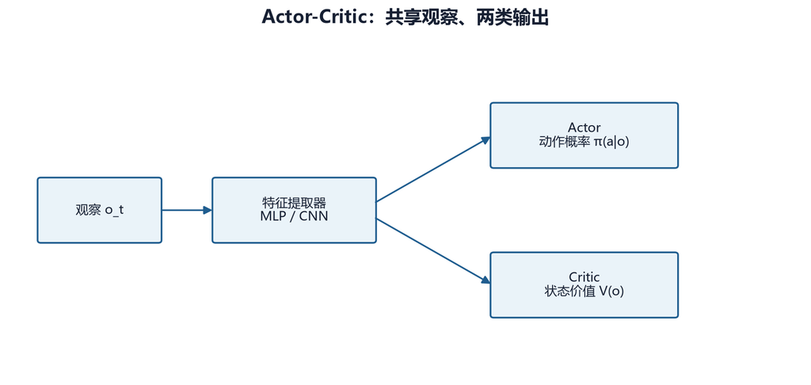

Actor-Critic

## 14.2 A2C 的含义

A2C 通常解释为 Advantage Actor-Critic 的同步版本。它从一个或多个环境收集短 rollout，计算 n 步回报和优势，然后同步更新策略与价值网络。

相比异步 A3C，A2C 在一次批更新前等待并组合多个环境的数据，工程实现更适合现代批计算。

## 14.3 n 步目标

$$R_t^{(n)}=
\sum_{k=0}^{n-1}\gamma^k r_{t+k+1}
+\gamma^nV(s_{t+n})$$

优势估计：

$$\hat A_t=R_t^{(n)}-V(s_t)$$

若两步奖励为 1、2，$\gamma=0.9$，两步后的价值估计为 5：

$$R_t^{(2)}=1+0.9\times2+0.9^2\times5=6.85$$

若当前价值为 4，优势为 2.85。

## 14.4 联合损失

策略损失：

$$L_{\mathrm{policy}}=-\mathbb{E}[\log\pi_\theta(a_t|s_t)\hat A_t]$$

价值损失：

$$L_{\mathrm{value}}=\mathbb{E}[(R_t^{(n)}-V_\phi(s_t))^2]$$

熵奖励鼓励探索：

$$\mathcal{H}(\pi)=-\sum_a\pi(a|s)\log\pi(a|s)$$

常见总损失：

$$L=L_{\mathrm{policy}}+c_vL_{\mathrm{value}}-c_e\mathcal{H}(\pi)$$

负号表示最小化损失时会提高熵。$c_v$ 和 $c_e$ 分别控制价值项和熵项。

## 14.5 与 PPO 的差别

A2C 没有 PPO 的新旧概率比裁剪。一次更新过大时，策略可能发生显著变化。A2C 每批通常只做较直接的更新，结构简单、速度快，但在复杂任务上对学习率和奖励尺度更敏感。

| A2C | PPO |
| --- | --- |
| 直接策略梯度更新 | 裁剪概率比 |
| rollout 通常较短 | 常收集更长 rollout |
| 每批利用较少 | 同一批多 epoch |
| 实现简单 | 更新更保守、超参更多 |

## 14.6 项目实现路径

基础 CLI 构造：

```python
A2C(
    "MultiInputPolicy",
    env,
    learning_rate=3e-4,
    n_steps=5,
)
```

SB3 A2C 支持 MultiDiscrete，因此在默认动作空间下可构造。问题在于基础 CLI 使用普通环境和普通 A2C，没有把合法动作掩码加入策略分布。

在 103,680 个组合空间中，普通 A2C 会大量采样无效动作。环境的 -10 无效惩罚可能主导回报，重演旧 PPO 的接口学习问题。当前 `sb3-contrib` 没有与 MaskablePPO 对等的 MaskableA2C 主线，因此需要自定义分布或改用精确 Flat 空间。

## 14.7 为什么保留 A2C

- 展示最直接的 Actor-Critic；
- 训练循环比 PPO 更容易理解；
- 可作为 PPO 裁剪价值的对照；
- 在小型、合法动作简单的环境上是合理基线。

但本项目选择 MaskablePPO 作为主线，是因为动作合法性和策略更新稳定性比算法结构简洁更重要。

## 14.8 实验设计

若比较 A2C 与 PPO，应固定：

- 相同观察和特征提取器；
- 相同动作空间；
- 相同对手、地图和奖励；
- 相同总环境步；
- 多训练种子；
- 相同评估协议。

不能直接拿 A2C 默认 `n_steps=5` 与 PPO 课程配置比较，然后把差异全部归因于算法。

## 14.9 常见问题

| 现象 | 诊断 |
| --- | --- |
| 回报极低且无效率高 | 没有掩码 |
| 熵快速趋近 0 | 学习率大、熵系数小或惩罚捷径 |
| value loss 爆炸 | 终局尺度过大、归一化不足 |
| 训练很快但完全不赢 | 短 rollout 与长信用链，或奖励投机 |
| 评估结果抖动 | 策略更新大、样本少、评估局数不足 |

## 14.10 本章练习

1. 用给定数字计算两步回报和优势。
2. Actor 与 Critic 分别输出什么？
3. 熵项为何在总损失中带负号？
4. A2C 在默认动作空间可构造，为什么仍不推荐作为主线？

# 第 15 章 PPO：受约束的策略更新

## 15.1 PPO 要解决的稳定性问题

策略梯度根据采样动作更新概率。如果一次更新把高优势动作概率从 0.01 推到 0.8，策略分布会发生巨大变化；同一批数据对新策略已不再具有代表性，价值估计也可能失效。

PPO（Proximal Policy Optimization）通过限制新策略相对旧策略的变化，让每批数据的更新更保守。

## 15.2 新旧策略概率比

$$r_t(\theta)=
\frac{\pi_\theta(a_t|s_t)}
{\pi_{\theta_{\mathrm{old}}}(a_t|s_t)}$$

- $r=1$：动作概率未变；
- $r=1.2$：新概率是旧概率的 1.2 倍；
- $r=0.7$：新概率降到旧概率的 70%。

实现中用 log probability：

$$r_t=\exp\left(
\log\pi_\theta(a_t|s_t)
-\log\pi_{\mathrm{old}}(a_t|s_t)
\right)$$

若旧概率 0.25、新概率 0.30，比例为 1.2。

## 15.3 未裁剪代理目标

$$L^{PG}(\theta)=\mathbb{E}[r_t(\theta)\hat A_t]$$

正优势希望 $r$ 增大，负优势希望 $r$ 减小。若反复在同一批数据上优化，比例可能离 1 很远。

## 15.4 裁剪目标

$$L^{CLIP}(\theta)=
\mathbb{E}\left[
\min\left(
r_t\hat A_t,
\operatorname{clip}(r_t,1-\epsilon,1+\epsilon)\hat A_t
\right)
\right]$$

常见 $\epsilon=0.2$，裁剪区间为 $[0.8,1.2]$。

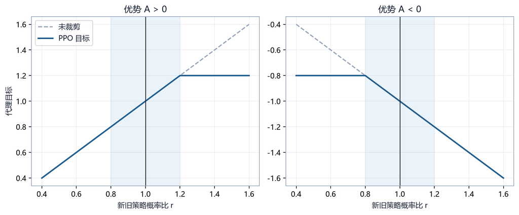

PPO 裁剪目标

### 正优势数字例

$\hat A=2,r=1.5,\epsilon=0.2$：

$$r\hat A=3,\qquad
\operatorname{clip}(1.5,0.8,1.2)\hat A=2.4$$

取较小值 2.4。超过 1.2 的继续增益被截断。

### 负优势数字例

$\hat A=-2,r=0.5$：

$$r\hat A=-1,\qquad
0.8\times(-2)=-1.6$$

取较小值 -1.6。概率降低超过边界不会继续带来有利目标。

裁剪不是把所有梯度限制在固定范围，也不是保证 KL 永不超标；它只对代理目标形成悲观下界。

## 15.5 GAE

TD 误差：

$$\delta_t=r_{t+1}+\gamma V(s_{t+1})-V(s_t)$$

GAE：

$$\hat A_t=\delta_t+(\gamma\lambda)\delta_{t+1}
+(\gamma\lambda)^2\delta_{t+2}+\cdots$$

$\lambda$ 控制偏差与方差。项目默认常用 0.95。对长微动作 episode，$\gamma\lambda$ 决定优势向后传播速度：

$$0.99\times0.95=0.9405$$

相隔 50 步的 TD 误差权重约 $0.9405^{50}\approx0.047$。

## 15.6 PPO 总损失

SB3 以最小化形式组合：

$$L(\theta)=
-L^{CLIP}
+c_vL_V
-c_e\mathcal{H}(\pi)$$

价值损失：

$$L_V=\mathbb{E}[(V_\theta(s_t)-\hat R_t)^2]$$

熵项鼓励探索。三项量级不同，`vf_coef` 和 `ent_coef` 用于权衡。若环境终局为 ±5000，价值损失可能远大于策略项；仅调 `vf_coef` 不能替代奖励缩放。

## 15.7 一次 PPO 更新

```
用旧策略收集 n_steps × n_envs 条转移
→ 计算 value、return、GAE advantage
→ 固定 old_log_prob
→ 打乱为多个 minibatch
→ 重复 n_epochs：
     计算新 log_prob 与 ratio
     计算裁剪策略损失、价值损失、熵
     反向传播、梯度裁剪、优化
→ 丢弃 rollout，重新采样
```

同一批数据重复 `n_epochs` 提高样本利用率，但 epoch 太多会使新策略偏离收集策略，表现为 `approx_kl` 和 `clip_fraction` 增大。

## 15.8 超参数解释

| 参数 | 主要作用 | 过大风险 | 过小风险 |
| --- | --- | --- | --- |
| `learning_rate` | 每次参数更新尺度 | KL 大、崩溃 | 学习缓慢 |
| `n_steps` | 每环境 rollout 长度 | 内存和延迟 | 长期信息不足 |
| `batch_size` | 小批大小 | 更新次数少 | 梯度噪声 |
| `n_epochs` | 同批重复利用 | 过拟合旧批 | 利用不足 |
| `gamma` | 长期折扣 | 方差高 | 终局太远 |
| `gae_lambda` | 优势平滑 | 方差高 | 偏差高 |
| `clip_range` | 更新限制 | 约束弱 | 学不动 |
| `ent_coef` | 探索 | 难收敛 | 过早坍缩 |
| `vf_coef` | 价值损失权重 | Critic 主导 | 价值学不准 |
| `max_grad_norm` | 梯度裁剪 | 约束弱 | 持续削弱更新 |

参数相互作用，不能用“单参数最佳值”概括。

## 15.9 项目为何选择 PPO

- 支持 Dict 观察和 MultiDiscrete/Discrete；
- 能结合自定义 CNN 特征提取器；
- sb3-contrib 提供 MaskablePPO；
- on-policy 数据与变化对手的语义较清晰；
- 课程、回调、评估和模型 Bot 已围绕 SB3 建立。

代价是样本利用率低，长局训练昂贵；掩码和奖励错误仍会使它稳定地学到错误策略。

## 15.10 历史困难

项目长期 PPO 训练的主要障碍不是 clip 公式本身，而是系统层：

- 逐维动作掩码产生大量无效组合；
- $\gamma=0.99$ 对数百微动作终局过短；
- 展平特征缺乏空间归纳偏置；
- 奖励项鼓励刷伤害、拖延或落后状态；
- 课程晋级受评估噪声与 checkpoint 交接影响；
- 单随机种子无法区分改进与偶然。

PPO 章节必须与第十一、十二、十七和二十三章一起使用。

## 15.11 监控指标

- `approx_kl` 持续过高：更新过大；
- `clip_fraction` 接近 1：大量样本被裁剪；
- entropy 迅速归零：策略坍缩；
- explained variance 长期接近 0 或为负：价值预测无解释力；
- value loss 极大：回报尺度或 Critic 失配；
- 平均回报涨而胜率不涨：检查奖励分解。

## 15.12 本章练习

1. 旧概率 0.4、新概率 0.5，计算比例。
2. $\epsilon=0.2,A=3,r=1.4$ 时裁剪目标取多少？
3. 为什么 PPO 仍属于 on-policy？
4. 列出两个 clip 公式之外导致项目 PPO 失败的系统原因。

# 第 16 章 MaskablePPO 与第一次可验证训练

## 16.1 MaskablePPO 改变什么

MaskablePPO 保留 PPO 的 rollout、GAE 和裁剪更新，只把策略分布限制在合法动作上。它解决的是“动作合法性”，不是奖励、观察或信用分配。

对合法集合 $\mathcal{A}(s)$：

$$\pi'(a|s)=
\begin{cases}
\dfrac{\pi(a|s)}{\sum_{b\in\mathcal{A}(s)}\pi(b|s)},
&a\in\mathcal{A}(s)\\
0,&a\notin\mathcal{A}(s)
\end{cases}$$

合法动作重新归一化，策略梯度只在可执行选择之间比较。

## 16.2 环境构造

推荐从小地图、noop 对手、Flat Discrete 开始验证：

```python
from reinforcetactics.rl.masking import make_maskable_env

env = make_maskable_env(
    map_file="maps/1v1/starter.csv",
    opponent="noop",
    action_space_type="flat_discrete",
    max_flat_actions=128,
    max_steps=32,
)
```

Flat 模式使掩码精确。noop 对手只用于接口与冷启动检查，不代表合理长期教师。

## 16.3 模型构造

```python
from sb3_contrib import MaskablePPO

model = MaskablePPO(
    "MultiInputPolicy",
    env,
    learning_rate=3e-4,
    n_steps=32,
    batch_size=32,
    n_epochs=1,
    gamma=0.99,
    gae_lambda=0.95,
    clip_range=0.2,
    seed=42,
    device="cpu",
    verbose=1,
)
```

这里的数值专为 64 步冒烟。生产配置通常使用更大 rollout、更多 epoch、并行环境和空间特征提取器。

## 16.4 训练与预测

```python
model.learn(total_timesteps=64)

obs, info = env.reset(seed=43)
mask = env.action_masks()
action, _ = model.predict(
    obs,
    action_masks=mask,
    deterministic=True,
)
obs, reward, terminated, truncated, info = env.step(action)
```

若忘记 `action_masks`，`predict` 不知道当前合法集合。训练 callback 也应使用 MaskablePPO 专用评估逻辑。

## 16.5 可直接运行的 CPU 冒烟

```powershell
python agents/learning-guide-v2/tools/smoke_labs.py
```

脚本会：

1. 构造 MultiDiscrete 与 Flat 环境；
2. 验证 PPO、A2C、DQN、MaskablePPO 的空间兼容性；
3. 比较逐维掩码组合数与领域合法动作数；
4. 运行 64 步 Flat MaskablePPO；
5. 运行两次模拟的 MCTS 接口检查；
6. 写出 `assets/data/smoke-results.json`。

成功标准是脚本退出码 0、数值有限、预测动作可执行。不是胜率标准。

## 16.6 第一次正式训练应怎样定义

第一次训练的合理验收分三层：

### 管线层

- 环境、模型和 callback 能创建；
- rollout 完成；
- 无 NaN、动作越界或掩码全空；
- checkpoint 与日志产生。

### 学习信号层

- episode 回报存在方差；
- 动作分布不是只剩 `end_turn`；
- value loss 有限；
- 终局原因不全为相同截断。

### 能力层

- 固定对手和地图上胜率高于随机波动；
- 多种子方向一致；
- 回放显示目标行为；
- 对未用于训练的固定锚仍有效。

64 步只覆盖第一层。

## 16.7 为什么不是直接运行基础 CLI

`main.py --algorithm ppo` 构造普通 `stable_baselines3.PPO`，不使用 MaskablePPO 工厂。因此教学主线显式使用 `sb3_contrib.MaskablePPO` 或 Bootstrap 脚本。

基础 CLI 仍可用于说明 SB3 接口，但不应作为本项目复杂动作空间的推荐长训命令。

## 16.8 MultiDiscrete 与 Flat 选择

| 项目 | MultiDiscrete | Flat Discrete |
| --- | --- | --- |
| 输出 | 六个分类头 | 一个索引头 |
| 掩码 | 逐维过度近似 | 完整动作精确 |
| 跨地图 | 维度随 W/H 变化 | 固定上限可统一 |
| 大地图 | 头较紧凑 | 上限可能很大 |
| 动作语义 | 字段稳定 | 索引位置动态 |

初学实操先用 Flat 验证合法性；研究大地图时应评估自回归或合法动作评分网络。

## 16.9 向量环境注意

SubprocVecEnv 在子进程中计算掩码，环境类必须原生实现 `action_masks`。不能把只存在主进程的闭包当作唯一掩码来源。

评估环境必须复用训练时的：

- 动作空间类型和上限；
- 地图 padding；
- 特征提取器；
- enabled units；
- gamma 与奖励配置；
- 对手参数与最大回合。

## 16.10 失败诊断

| 现象 | 优先检查 |
| --- | --- |
| `ValueError` 无合法动作 | `end_turn` 掩码与领域合法动作 |
| 训练合法、评估非法 | 评估漏传掩码 |
| Flat 索引越界 | `_current_actions` 重建时序与上限 |
| 只结束回合 | 奖励、对手、探索、动作列表排序 |
| 小图可训、大图加载失败 | observation/action shape 与 padding |
| 回报涨、胜率 0 | 奖励分解和终局原因 |

## 16.11 结果记录模板

```
提交：
环境版本：
地图 / 对手：
动作空间 / 上限：
观察提取器：
奖励配置哈希：
PPO 超参数：
训练种子：
总步数与运行时间：
评估地图 / 对手 / 局数 / 座次：
胜负和、置信区间、终局原因：
回放结论：
```

## 16.12 本章练习

1. MaskablePPO 相比 PPO 改变了哪个概率分布？
2. 为什么 64 步冒烟不能说明模型会赢？
3. 为什么训练和评估环境的 `max_flat_actions` 必须一致？
4. 设计三个从“管线可运行”到“能力有效”的递进验收条件。

# 第 17 章 课程学习与 Bootstrap

## 17.1 冷启动问题

初始策略接近随机。在完整地图、全部单位和强对手下，它很难偶然完成“生产—行军—战斗—占领总部”的长链。若所有轨迹都失败且回报相似，优势估计缺乏可区分信号。

课程学习把任务按难度排列，使当前策略面对“略高于已有能力”的数据分布。Bootstrap 指通过弱对手、小地图、受限兵种、行为克隆或塑形让策略离开随机冷启动区。

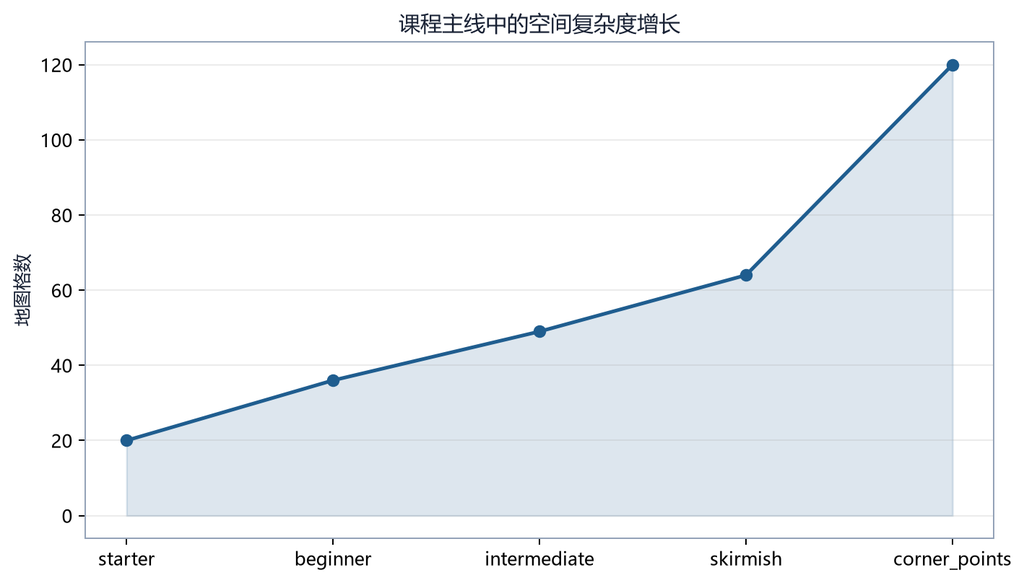

课程地图规模增长

## 17.2 课程阶段

项目阶段可抽象为：

$$\mathcal{C}_i=
(\text{map},\text{opponent},\tau_i,p_i,T_i,
\text{reward},\text{entropy},\text{rules})$$

| 量 | 含义 |
| --- | --- |
| $\tau_i$ | 晋级胜率阈值 |
| $p_i$ | 连续达标次数 patience |
| $T_i$ | 最大训练步预算 |
| map | 地图及观察/动作复杂度 |
| opponent | 对手类型与参数 |

阶段不是只换对手。地图尺寸、回合上限、奖励、熵系数和规则覆盖都可能变化。

## 17.3 训练状态机

```
加载配置与模型
→ 构建阶段 i 的训练/评估环境
→ 训练 eval_freq 步
→ 固定协议评估
→ 连续 p 次胜率 ≥ τ 且满足最低步数？
   ├─ 是：恢复阶段最佳 checkpoint，进入 i+1
   └─ 否：预算是否耗尽？
          ├─ 否：继续训练
          └─ 是：抛出 CurriculumStalled
```

停滞应显式失败并保留历史，不能静默进入下一关。否则最终模型看似“完成课程”，实际可能跳过未掌握技能。

## 17.4 晋级噪声

评估胜率：

$$\hat w=\frac{W}{n}$$

若真实胜率 0.7、评估 20 局，标准误约：

$$\sqrt{\frac{0.7\times0.3}{20}}\approx0.102$$

一次 85% 可能只是波动。`patience=2` 要求连续两次达标，降低偶然晋级；增加评估局数降低噪声。二者仍不能消除 winner’s curse：恰好被选为“最佳”的 checkpoint 可能包含正向噪声。

## 17.5 MixedBot 难度桥

从 RandomBot 直接换 SimpleBot 可能改变的不只是强度，还包括行为分布。MixedBot 每局以概率 $p_h$ 选择 hard，否则选择 easy：

$$O\sim
\begin{cases}
O_{\mathrm{hard}},&p_h\\
O_{\mathrm{easy}},&1-p_h
\end{cases}$$

每局内部保持同一个 Bot，使对手策略连贯。课程可用 25%、50% 等难度桥逐步改变分布。

## 17.6 阶段交接：峰值而非末值

on-policy 策略在达到高胜率后仍会继续更新，可能向塑形捷径漂移。若下一阶段从“预算耗尽时的最后权重”开始，会丢掉阶段内最佳能力。

当前设计可在晋级时恢复 `best_model`。但“最佳”必须由与阶段一致的评估环境确定，且 checkpoint 保存时点要真实包含触发指标的参数。

历史审查发现 `best_model.zip` 有时仍是阶段带入模型，晋级后恢复会撤销本阶段学习。解决这类问题要核对：

- 首次评估前是否保存 carry-in 基准；
- 达到更好指标时是否覆盖；
- 回调调用顺序；
- 恢复后总步数与优化器状态；
- stage 目录中的时间戳和指标。

## 17.7 早期失败：确定性 noop 教师

完全不行动的对手适合检查造兵、移动和占领接口，但若作为长期唯一老师：

- 轨迹高度重复；
- 策略可用单一剧本获胜；
- 回报方差趋近零；
- 迁移到会争夺地图的对手时崩溃。

因此 noop 是单元测试和最初台阶，不是课程的能力终点。

## 17.8 地图迁移与价值错位

从 starter 到 beginner，空间尺寸、路径长度、收入节奏和终局距离改变。即使观察 padding 统一，价值网络对旧地图回报分布的估计也可能不适合新地图。

缓解方式：

- 中间地图；
- 地图切换时提高探索；
- 使用空间特征与坐标通道；
- 阶段首部做诊断评估；
- 允许 Critic 重新适应；
- 避免同时改变太多奖励和规则。

## 17.9 课程漂移与错误修复链

长期 Bootstrap 复盘可归纳为以下因果链。

### 现象

一些运行通过早期阶段，却在 `beginner_random_15/20` 或更大地图处形成大量和局；另一些在阶段内先达到高胜率，之后退化。

### 证据

- 胜率曲线先升后降；
- 平均回合靠近最大回合；
- 塑形回报继续增长；
- 伤害/击杀多而占领减少；
- 不同单种子运行分歧很大。

### 排除过程

实验依次检查熵、耐心、兵种限制、对手强度、checkpoint 交接、引擎常量、行为克隆和奖励项。多次结论后来被配置或评估环境不一致推翻，说明实验隔离比调参速度更重要。

### 已落地改进

- 恢复阶段最佳 checkpoint；
- 将规则常量显式放入 `engine_overrides`；
- 增加 MixedBot 与中间地图；
- 改进随机 Bot 与 RNG；
- 记录终局原因和行为组成；
- 调整战斗、占领、受伤与和局奖励；
- 支持最低训练步、patience 和停滞异常；
- 使用空间特征提取器。

### 当前开放问题

- 长微动作下 $\gamma$ 的系统性消融；
- 多训练种子；
- Flat 动作索引的语义不稳定；
- 更适合大地图的结构化动作网络；
- 课程阈值的统计决策方法。

## 17.10 `max_timesteps` 是安全阀

阶段预算应表示“最多允许消耗多少数据后认定停滞”，不是保证这么多步一定足够。若指标长期不动，简单扩大预算可能只强化错误吸引子。

诊断顺序：

1. 是否有合法且多样的动作；
2. 回报是否有方差；
3. 终局原因；
4. 奖励分解；
5. 行为直方图；
6. 评估环境一致性；
7. 最后才考虑增加预算。

## 17.11 最小管线实验

本书提供一阶段配置：

```powershell
python scripts/train/train_bootstrap.py `
  --config agents/learning-guide-v2/labs/bootstrap-smoke.yaml `
  --device cpu `
  --output-dir tmp/guide-bootstrap-smoke `
  --skip-plots `
  --skip-videos `
  --sanity-episodes 0 `
  --no-gcs
```

该阶段阈值为 0、最低步数 32、预算 64，只验证模型创建、评估、晋级和输出目录。它不验证课程是否能学习游戏。

## 17.12 本章练习

1. 为什么 patience 能降低偶然晋级却不能消除 winner’s curse？
2. MixedBot 为何按 episode 选对手而不是每一步切换？
3. 阶段末模型与阶段最佳模型为何可能不同？
4. 看到 `CurriculumStalled` 后应先检查哪些证据，而不是立即加预算？

# 第 18 章 行为克隆

## 18.1 用专家动作初始化策略

行为克隆（Behavior Cloning, BC）把专家轨迹当作监督学习数据：

$$\mathcal{D}=\{(o_i,a_i)\}_{i=1}^N$$

训练策略提高专家动作概率：

$$L_{BC}(\theta)=
-\frac1N\sum_{i=1}^{N}\log\pi_\theta(a_i|o_i)$$

BC 不直接使用奖励。它学习“在专家访问过的观察上模仿动作”，适合让随机策略先掌握基本操作，再交给 PPO 优化长期目标。

## 18.2 数据如何采集

项目由脚本 Bot 产生对局，并在示范方行动时记录：

- Dict 观察；
- 六字段或 Flat 动作；
- 动作掩码；
- episode 结果与场景；
- 地图和示范者座次。

只记录示范者动作，不能把对手动作错误地配到示范者观察。地图尺寸和动作空间必须与待初始化模型一致。

## 18.3 交叉熵的数字例

若某观察下专家动作概率为 0.1：

$$-\log(0.1)\approx2.303$$

训练后提高到 0.8：

$$-\log(0.8)\approx0.223$$

损失显著下降。它只说明模型更像数据中的专家，不保证对分布外状态更会行动。

## 18.4 多字段动作的损失

MultiDiscrete 动作可把各字段负对数概率相加：

$$L_i=-\sum_{d=1}^{6}\log p_\theta(a_i^{(d)}|o_i)$$

若各字段独立，仍存在组合语义问题。Flat 动作使用单一分类，但动态索引必须在数据记录和训练重建间保持一致。自回归策略则按条件概率分解损失。

## 18.5 类别不平衡

一回合只结束一次，却可能有很多移动和攻击；`end_turn` 在数据中的频率低，但执行错误会使回合无法推进。项目允许提高 `end_turn_weight`：

$$L=-\frac1N\sum_i w(a_i)\log\pi(a_i|o_i)$$

权重改变的是该样本的梯度，不是直接给 `end_turn` 增加推理 logit。权重太大可能让模型过早结束回合。

## 18.6 分布偏移

BC 只见过专家状态。部署时一次错误会进入专家很少访问的局面；模型更易犯第二次错误，误差逐步累积。这叫 covariate shift。

缓解方式：

- 收集多地图、多对手、多座次示范；
- 为脚本 Bot 引入受控随机性；
- 用 PPO 继续交互学习；
- 迭代加入模型失败状态的专家纠正；
- 评估不仅看 BC loss，还看真实对局。

## 18.7 历史失败 A：确定性 Bot 产生重复轨迹

表面采集 100 局，若 Bot、地图和决胜规则完全确定，可能只有一条独特轨迹。模型会迅速把训练 loss 降低，却没有状态覆盖。

诊断：

- 轨迹哈希；
- 独特观察/动作比例；
- 每场长度和动作分布；
- 不同座次的终局；
- 场景级统计。

修复包括随机决胜、独立 RNG、MixedBot 内部随机传播和多场景配置。

## 18.8 历史失败 B：测量环境漏参数

BC sanity evaluation 曾漏传生产环境的 `stochastic_tiebreak` 或其他 kwargs，导致评估环境与数据采集环境不同。结果看似“BC 使模型退化”，实际是测量工厂不一致。

可复用教训：训练、数据采集和评估都应从同一环境配置对象构造，而不是三处手写参数。

## 18.9 历史失败 C：好看的 loss 不等于策略强

确定性重复数据使训练准确率很高；模型可能只学会：

- 高频移动；
- 固定购买顺序；
- `end_turn` 时机；
- 单一地图路线。

价值头在纯 BC 中没有从回报学习，即使策略头已初始化，PPO 开始时 Critic 仍可能很差。BC warm-start 保存的 MaskablePPO 参数要与后续特征提取器、动作空间和地图形状完全一致。

## 18.10 BC → PPO

流程：

```
脚本 Bot 示范
→ 检查场景与独特轨迹
→ 建立同架构 MaskablePPO
→ 监督训练策略分布
→ 保存 warm-start
→ 在交互环境中 PPO
→ 固定 Bot 梯评估
```

BC 解决“最初怎样产生像样动作”，PPO 解决“怎样根据长期回报改进和纠正专家局限”。

## 18.11 项目入口

核心实现在 `reinforcetactics/rl/imitation.py`：

- `collect_demonstrations` / `collect_demonstrations_multi`；
- `DemonstrationDataset`；
- `behavior_clone`；
- `make_warm_started_model`；
- `evaluate_bc_against_bot_ladder`。

最小正确性测试：

```powershell
python -m pytest tests/test_imitation.py -q --no-cov
```

测试验证记录形状、只记录示范方、loss 可下降以及 BC 后 PPO 能运行。它不验证长期能力。

## 18.12 本章练习

1. 专家动作概率从 0.2 提高到 0.6，负对数损失怎样变化？
2. 为什么 100 条重复轨迹不能等价于 100 条多样轨迹？
3. BC 为什么不能直接学好价值函数？
4. 为什么 BC 模型与 PPO 环境必须使用相同特征提取器和动作空间？

# 第 19 章 自对弈

## 19.1 为什么需要自对弈

固定脚本 Bot 提供稳定课程，却有能力上限和可利用模式。自对弈让策略面对自己的历史版本，训练分布随能力增长。

最简单形式：

$$\pi_t \text{ 对战 } \pi_t$$

但只对战当前镜像容易产生同步退化和策略循环。项目使用快照与对手池稳定训练。

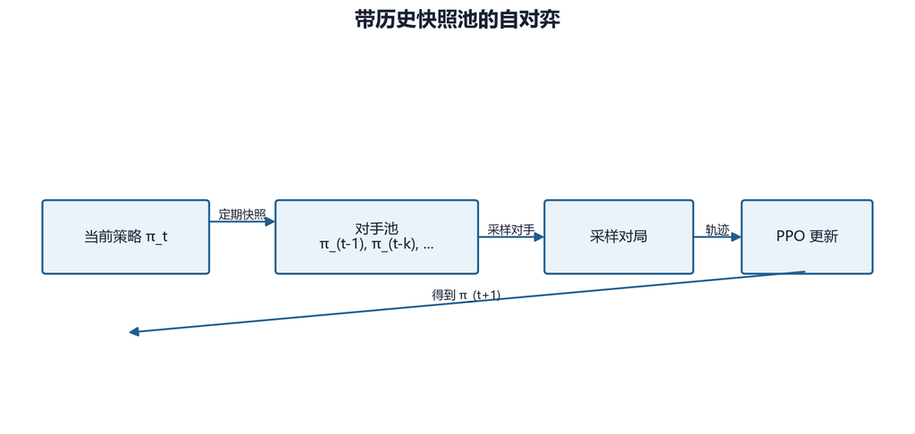

历史快照池自对弈

## 19.2 非平稳性

普通单智能体 MDP 假定环境转移固定。自对弈中对手随训练更新，策略看到的转移分布变为：

$$P_t(s'|s,a;\pi^{opp}_t)$$

若每几步就把对手替换为当前网络，学习者追逐移动目标。更新太快会不稳定，太慢则容易过拟合旧对手。

## 19.3 快照池

对手池：

$$\mathcal{P}_t=\{\pi_{t_1},\pi_{t_2},\ldots,\pi_{t_K}\}$$

每个 episode 从池中采样对手。选择策略：

- uniform：所有快照等概率；
- recent：偏向近期对手；
- prioritized：按胜率或难度加权。

均匀采样简单且提供历史覆盖；偏近期更聚焦当前前沿；优先采样需要可靠难度估计，否则会形成反馈偏差。

## 19.4 为什么历史对手重要

策略可能存在非传递关系：

```
A 克制 B，B 克制 C，C 克制 A
```

只对战最新对手可能忘记较早策略，出现战略循环。历史池相当于持续复习旧考试。

## 19.5 对手快照与权重安全

对手不应引用会在优化器更新时变化的同一参数对象。应复制或保存稳定快照。若为了推理临时交换权重，必须在异常时通过 `finally` 恢复，否则训练模型可能被对手权重污染。

项目的自对弈工厂在 episode reset 时创建绑定当前 `GameState` 的 ModelBot；快照更新频率和池大小由配置控制。

## 19.6 玩家视角与座次

随机交换座次可以减少先手偏差，但需要完整翻转：

- grid 和 unit 归属；
- own/opp 金币；
- 当前玩家；
- 可见性；
- 奖励符号；
- winner 判断；
- 合法动作查询玩家。

任何漏项都会让“对手视角观察”内部矛盾。战争迷雾下尤其要防止用原玩家可见性。

## 19.7 固定评估锚

如果训练和评估都面对不断变强的自对弈对手，胜率可能一直约 50%，无法判断绝对能力。必须保留固定锚：

- RandomBot；
- Simple/Medium/AdvancedBot；
- 固定历史 checkpoint；
- 固定地图与座次协议。

自对弈训练指标回答“相对当前对手如何”，固定锚回答“绝对能力是否进步”。

## 19.8 混合训练

混合策略以概率 $\rho$ 对脚本 Bot，其余对自对弈：

$$O\sim
\begin{cases}
O_{\mathrm{bot}},&\rho\\
O_{\mathrm{self}},&1-\rho
\end{cases}$$

脚本 Bot 提供稳定技能锚，自对弈提供不断变化的挑战。比例不是越偏自对弈越先进；冷启动策略的镜像对手同样不会提供高质量战术。

## 19.9 与课程和 BC 的组合

合理顺序：

```
BC（可选）掌握基本操作
→ Bot 课程建立造兵、占领、战斗能力
→ 自对弈扩展策略
→ 固定 Bot 梯与锦标赛持续评估
```

直接让两个随机策略自对弈，双方可能共同稳定在拖延或无效行为。

## 19.10 项目实现

`reinforcetactics/rl/self_play.py` 提供：

- `OpponentPool`；
- `SelfPlayEnv`；
- `make_self_play_env`；
- `make_self_play_vec_env`。

训练脚本：

```powershell
python scripts/train/train_self_play.py `
  --mode self-play `
  --use-opponent-pool `
  --pool-size 4 `
  --n-envs 1 `
  --no-subprocess `
  --total-timesteps 64 `
  --n-steps 32 `
  --batch-size 32 `
  --n-epochs 1 `
  --device cpu `
  --max-steps 32 `
  --eval-freq 32 `
  --n-eval-episodes 1 `
  --checkpoint-freq 64 `
  --log-dir tmp/guide-self-play-smoke
```

这是接口冒烟；64 步不足以形成有意义对手池能力。

## 19.11 RNG 与推理热路径

2026-07-24 审查指出自对弈 RNG 和对手推理路径存在可复现与性能风险。应记录池采样 RNG、环境种子和对手推理设备；对手网络应使用 `eval()`、`no_grad()`，避免不必要梯度和随机层。

## 19.12 常见失败

| 现象 | 原因 |
| --- | --- |
| 自对弈胜率恒 50% | 指标相对且对手同步变化 |
| 对固定 Bot 退化 | 灾难遗忘、池太偏近期 |
| 多环境结果不复现 | 子进程种子或池 RNG |
| 训练越来越慢 | 对手推理在热路径、设备切换 |
| 一方观察异常 | 视角翻转不完整 |
| 两边一起拖延 | 冷启动和奖励共同形成坏均衡 |

## 19.13 本章练习

1. 为什么只对战当前镜像不足以避免战略遗忘？
2. 自对弈胜率约 50% 时，怎样判断绝对能力？
3. 说明座次翻转至少要同步改变的四类信息。
4. 为什么自对弈通常应放在 Bot 课程或 BC 之后？

# 第 20 章 Feudal RL：用层级决策分解长期战略

## 20.1 为什么需要层级

前面的 PPO、MaskablePPO 都在同一个时间尺度上作决定：策略每接收一次观察，就直接输出一次环境动作。这个做法适合局部决策，却很难自然表达“先夺取中央资源点，再集结远程单位，最后进攻基地”这样的多步意图。

策略游戏同时包含两种时间尺度：

- **战略层**决定一段时间内应当追求什么；
- **执行层**决定下一步具体移动、生产、攻击还是结束回合。

Feudal Reinforcement Learning（封建式强化学习，简称 Feudal RL）把一个策略拆成 Manager 和 Worker。Manager 以较低频率提出目标，Worker 在接下来的若干微动作中，依据当前观察和目标选择具体动作。

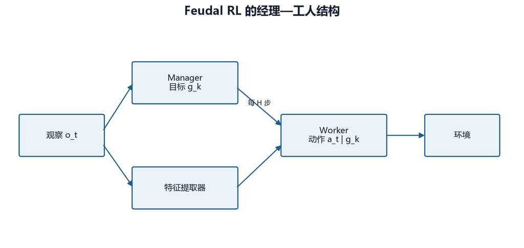

Reinforce Tactics 的层级结构

这不是把两个完全独立的智能体放进游戏。二者共享同一环境轨迹，只是承担不同职责，并分别拥有策略网络、价值网络和训练数据。

## 20.2 从时间抽象理解 Manager 与 Worker

设环境微动作编号为 $t$，Manager 每隔 $c$ 个微动作输出一次目标：

$$g_k \sim \pi_M(g\mid s_{kc})$$

其中：

- $k$ 是 Manager 的决策段编号；
- $c$ 是 `manager_horizon`；
- $s_{kc}$ 是该段开始时的状态；
- $g_k$ 是这一段要追求的目标；
- $\pi_M$ 是 Manager 策略。

在段内，Worker 每一步都接收同一个目标：

$$a_t \sim \pi_W(a\mid s_t,g_k),\qquad kc\le t<(k+1)c$$

与普通策略相比，Worker 多了一个条件变量 $g_k$。相同状态下，目标不同，动作分布也应不同。例如，目标位于左上资源点时，向左移动的概率应提高；目标是防守基地时，召回单位或结束冒进的概率应提高。

这种设计的关键不是网络数量，而是**时间抽象**：Manager 的一个动作对应 Worker 的一段动作序列。

## 20.3 项目中的目标表示

本项目的 Manager 输出三维连续目标，概念上可写为

$$g=(x_g,y_g,z_g)$$

前两个分量描述地图目标位置，第三个分量描述目标类别或高层语义。网络输出会被限制到规定范围，再转换为 Worker 能消费的目标向量。这样做有两个好处：

1. 目标空间远小于完整微动作组合，Manager 不必直接选择单位、动作类型和目标坐标；
2. 目标位置可以与卷积提取出的空间特征对齐。

连续目标并不意味着环境存在“移动到坐标”这一原子动作。Worker 仍然需要选择真实合法动作，一步步改变状态。

### 目标条件不是命令执行器

Manager 的目标只改变 Worker 的概率分布，并不保证 Worker 一定到达目标。训练早期尤其可能出现：

- Manager 给出的目标没有战略意义；
- Worker 尚未学会响应目标；
- Worker 忽略目标，只依赖环境奖励；
- 目标在当前局面不可到达；
- 目标频繁变化，尚未执行就被替换。

因此，层级方法比单层 PPO 多出一个“协同学习”问题：Manager 要提出 Worker 能完成且有价值的目标，Worker 又要表现出足够稳定的目标响应，Manager 才能学到目标的后果。

## 20.4 内在奖励：怎样告诉 Worker 目标是否有进展

只把终局胜负奖励交给 Worker，目标变量很容易被忽略。项目使用内在奖励衡量单位与目标的空间关系。抽象地写，可以把一个简单版本表示为

$$r_t^{\text{int}}
=d(s_t,g)-d(s_{t+1},g)+b\cdot \mathbf{1}[\text{reach}(s_{t+1},g)]$$

逐项解释：

- $d(s,g)$：状态中相关单位到目标的距离；
- $d(s_t,g)-d(s_{t+1},g)$：距离缩短时为正，远离时为负；
- $\mathbf{1}[\cdot]$：指示函数，条件成立取 1，否则取 0；
- $b$：到达目标的额外奖励；
- 单位：与环境奖励一样，都是“每个微动作的奖励值”，但数值尺度可能不同。

假设单位到目标的曼哈顿距离从 5 降到 3，未到达目标，且距离改善系数为 1，那么内在奖励为 $5-3=2$。若下一步从距离 1 到达目标，且到达奖励为 5，则奖励为 $1+5=6$。

这里的关键是，内在奖励只回答“是否按照 Manager 的目标行动”，并不直接回答“这个目标能否赢得游戏”。后者由外在环境奖励和 Manager 学习承担。

## 20.5 Worker 奖励：必须以实际代码为准

项目当前缓冲区中的合成公式是：

```python
self.w_rewards.append(
    intrinsic_reward
    + worker_reward_alpha * extrinsic_reward
)
```

因此，Worker 实际接收

$$r_t^W=r_t^{\text{int}}+\alpha r_t^{\text{ext}}$$

其中：

- $r_t^{\text{int}}$ 是目标进展奖励；
- $r_t^{\text{ext}}$ 是经过 `reward_scale` 缩放后的环境奖励；
- $\alpha$ 对应 `worker_reward_alpha`，默认配置为 0.5；
- $r_t^W$ 是进入 Worker GAE 和 PPO 更新的奖励。

这不是

$$(1-\alpha)r^{\text{int}}+\alpha r^{\text{ext}}$$

形式的凸组合。换句话说，`worker_reward_alpha=1.0` 在当前实现中表示“完整内在奖励加上一倍外在奖励”，并不表示“只保留外在奖励”。如果命令帮助或旧实验注释把它描述为内外奖励的插值比例，应当把那种描述视为不精确说明，以这段实际数据路径为准。

### 数值例子

假设：

- 原始环境奖励为 100；
- `reward_scale=0.001`；
- 内在奖励为 2；
- `worker_reward_alpha=0.5`。

先缩放外在奖励：

$$r^{\text{ext}}=100\times 0.001=0.1$$

再合成 Worker 奖励：

$$r^W=2+0.5\times 0.1=2.05$$

这个例子揭示了尺度关系：若内在奖励经常在 1 到 5，而缩放后外在奖励只有 0.1，Worker 的短期行为主要受目标塑形控制。Manager 则需要通过累计外在奖励判断这个目标是否真正有利于胜利。

## 20.6 Manager 奖励与段级回报

Manager 的一个动作持续 $k_t$ 个环境微动作。项目在目标段结束时记录该段累计的外在奖励和实际段长：

```python
def end_manager_segment(self, cumulative_reward, done, segment_length):
    self.m_rewards.append(cumulative_reward)
    self.m_dones.append(done)
    self.m_segment_lengths.append(segment_length)
```

段长不能被忽略。若仍对每个 Manager 段固定乘一次 $\gamma$，就相当于把持续 2 步和持续 10 步的目标视为具有相同时间跨度。当前 `_compute_gae` 对 Manager 使用

$$\gamma_t=\gamma^{k_t}$$

并把 TD 残差写为

$$\delta_t=R_t^M+\gamma^{k_t}(1-d_t)V(s_{t+1})-V(s_t)$$

其中：

- $R_t^M$ 是整个目标段的累计外在奖励；
- $k_t$ 是该段真实持续的微动作数；
- $d_t$ 表示段末是否终局；
- $V$ 是 Manager 价值估计。

若 $\gamma=0.99$，段长为 10，则跨段折扣为

$$0.99^{10}\approx 0.904$$

而不是 0.99。这样才能保持与逐微动作时间尺度一致。

Manager 的 GAE 递推也要使用段折扣：

$$A_t=\delta_t+\gamma^{k_t}\lambda(1-d_t)A_{t+1}$$

这是一处很容易被“照抄普通 PPO”遗漏的实现细节。

## 20.7 两套 Worker 动作头

项目保留两类 Worker。

### 20.7.1 传统多头 Worker

传统 Worker 为 MultiDiscrete 的各维分别输出概率，例如动作类型、来源坐标、单位类型和目标坐标。训练时可保存每一维的布尔掩码，并在 PPO 重算对数概率时应用同一组掩码。

优点是结构简单、并行计算方便。局限与第 11 章讨论的一样：逐维掩码只能说明单个取值是否在某些合法动作中出现，不能保证各维组合后仍然合法。

### 20.7.2 自回归 Worker

自回归 Worker 按条件顺序生成结构化动作：

$$p(a\mid s,g)
=p(a_{\text{type}}\mid s,g)
\times p(a_{\text{src}}\mid a_{\text{type}},s,g)
\times p(a_{\text{unit}}\mid a_{\text{type}},a_{\text{src}},s,g)
\times p(a_{\text{target}}\mid \text{previous},s,g)$$

取对数以后才变为各阶段对数概率之和：

$$\log p(a\mid s,g)=\sum_j\log p(a_j\mid a_{<j},s,g)$$

每个阶段使用依赖前面选择的条件掩码。项目缓冲区会保存 `atype`、`src`、`unit_type` 和 `target` 四组采样时掩码，在 PPO 更新时重放，避免“采样分布与训练分布不一致”。

这比传统多头更接近精确动作掩码，但代价是：

- 推理要顺序执行多个头；
- 缓冲区必须保存更多条件信息；
- 某个早期头选择不佳，会限制后续所有选择；
- 实现与测试明显更复杂。

## 20.8 Manager 和 Worker 都使用 PPO

项目不是用一种新损失完全替代 PPO，而是在两个时间尺度上分别应用 PPO。对任一层 $X\in\{M,W\}$，策略损失为

$$L_X^{\text{clip}}
=-\mathbb{E}\left[
\min\left(
r_t^X A_t^X,\,
\operatorname{clip}(r_t^X,1-\epsilon,1+\epsilon)A_t^X
\right)\right]$$

再加价值损失、减去熵奖励：

$$L_X=L_X^{\text{clip}}+c_vL_X^V-c_eH_X$$

项目为 Manager 和 Worker 分别统计 policy loss、value loss 和 entropy。诊断时不能只看总回报：

- Worker 内在奖励持续升高，但胜率不升：Worker 会执行目标，Manager 目标可能无用；
- Manager 回报有改善，但 Worker 到达目标率低：高层意图没有可靠落地；
- 两层价值损失都很大：奖励尺度或终局脉冲可能过强；
- 熵迅速接近零：某一层过早形成确定性策略。

## 20.9 为什么项目尝试 Feudal RL

本项目的长回合、空间地图和组合动作天然具有层级结构。Feudal RL 的潜在优势是：

1. **延长信用分配范围。** Manager 以段为单位学习，不必把每个微动作分别关联到终局；
2. **形成可解释中间变量。** 目标坐标可绘制、统计到达率；
3. **复用执行技能。** 一个会“向目标移动与作战”的 Worker 可以服务多个高层目标；
4. **匹配策略语言。** 占点、集结、进攻等计划本来就跨越多个动作。

代价同样明显：

1. 两层同时变化，训练分布非平稳；
2. 内在奖励设计会引入新的偏好；
3. 目标空间是否足够表达战略并无保证；
4. 样本和调参成本高于单层 MaskablePPO；
5. 传统 Worker 仍承受组合动作掩码的近似误差。

因此，Feudal RL 在本项目中属于进阶实验路径，不应因为结构更复杂就预设它一定优于主线 MaskablePPO。

## 20.10 历史困难的因果整理

### 当时现象

- 训练能够运行，但 Worker 内在奖励与胜率不同步；
- Manager 的价值损失容易受大额终局奖励影响；
- 逐维动作头仍会形成非法组合；
- 多环境采集、断点恢复和自对弈快照需要保存额外层级状态；
- 配置中的环境平衡、奖励和单位限制曾有未完整传递的风险。

### 调查证据

单看 episode reward 无法判断问题来自哪一层。后来增加了 Worker 内在/外在奖励、到达目标率、Manager/Worker 各自损失等诊断；缓冲区也显式保存动作掩码和 Manager 段长。

### 已排除的简单解释

“层级网络没有学会”过于笼统。至少要分别检查目标是否可完成、Worker 是否响应目标、Manager 是否获得正确段奖励，以及掩码在更新时是否与采样一致。

### 已落地修复

- 外在奖励进入层级缓冲区前支持 `reward_scale`；
- Manager GAE 使用真实段长的 $\gamma^{k_t}$；
- Worker 采样掩码可随轨迹保存并重放；
- 增加自回归 Worker 与阶段条件掩码；
- 训练配置把环境奖励、引擎覆盖、单位集合和观察尺度传给 Feudal 环境；
- checkpoint 保存训练计数、最佳指标和快照节奏。

### 当前仍开放的问题

- 三维目标是否是最合适的高层表示；
- 内在奖励是否诱导“抵达坐标”而非“取得战略收益”；
- Manager horizon 是否应随局面变化；
- 自回归 Worker 的额外复杂度能否稳定转化为胜率；
- 在相同计算预算下，层级方法是否显著优于更充分训练的 MaskablePPO。

## 20.11 最小实操

先运行单元与集成测试：

```powershell
pytest -q tests/test_feudal_rl.py tests/test_feudal_rl_integration.py
```

再用教材配置作 CPU 冒烟训练：

```powershell
python scripts/train/train_feudal_rl.py `
  --mode feudal `
  --config agents/learning-guide-v2/labs/feudal-smoke.yaml
```

冒烟训练的验收目标不是胜率，而是：

- 能完成一次 rollout 和两层 PPO 更新；
- Manager 与 Worker 的损失均为有限数；
- 轨迹长度、段长和奖励分量可记录；
- checkpoint 可写入临时目录；
- 使用自回归 Worker 时，四组条件掩码数量与 Worker 步数一致。

正式实验应至少比较：

| 实验 | Worker | `reward_scale` | 目的 |
| --- | --- | --- | --- |
| F0 | 传统多头 | 1.0 | 原始尺度基线 |
| F1 | 传统多头 | 0.001 | 检查价值损失稳定性 |
| F2 | 自回归 | 0.001 | 检查精确条件掩码收益 |
| F3 | 自回归 | 0.001 | 改变 horizon，检查时间抽象 |

所有比较都应固定地图、对手、训练步数、评估种子和评估局数。

## 20.12 常见误解

**误解一：Manager 直接控制游戏。**  
Manager 只产生目标；环境动作全部由 Worker 输出。

**误解二：内在奖励越高，策略越强。**  
它只说明 Worker 更符合目标。目标本身可能无助于胜利。

**误解三：`worker_reward_alpha=1` 等于只用外在奖励。**  
当前实现是内在奖励加一倍外在奖励。

**误解四：Manager 每段折扣一次普通 $\gamma$ 即可。**  
段长不同，应使用 $\gamma^{k_t}$。

**误解五：层级网络天然比单层网络强。**  
它提供了归纳偏置，也引入了协同、奖励设计和非平稳问题，结论必须由等预算实验给出。

## 20.13 本章小结

Feudal RL 通过 Manager—Worker 把长期目标与微动作执行分开。项目当前实现包含独立的两层 PPO、目标内在奖励、段级 GAE、掩码重放和可选自回归 Worker。理解这一实现最重要的三点是：目标不是原子动作；Worker 奖励是实际代码规定的加法结构；Manager 的时间折扣必须反映真实段长。

## 20.14 练习

1. 当 $\gamma=0.98$、Manager 段长为 8 时，跨段折扣是多少？为什么不能直接使用 0.98？
2. 若内在奖励为 3、原始外在奖励为 500、`reward_scale=0.001`、`worker_reward_alpha=0.2`，计算 Worker 奖励。
3. 解释“到达目标率上升但胜率下降”可能对应的两种原因。
4. 为什么 PPO 更新时必须重放采样时使用的条件掩码？
5. 设计一个消融实验，区分自回归动作头和奖励缩放各自的作用。

# 第 21 章 蒙特卡洛树搜索：在行动之前进行推演

## 21.1 从反应式策略到显式搜索

PPO 或 DQN 的网络通常只做一次前向传播，就给出当前状态下的动作。MCTS 则在真正执行动作之前，复制当前局面并反复模拟可能的后续分支，以访问次数形成改进后的决策。

这两种方法回答不同问题：

- 神经网络回答“凭已有经验，这个局面看起来怎样”；
- 树搜索回答“如果沿着若干候选动作继续推演，哪些分支更值得选择”。

Reinforce Tactics 的 AlphaZero 实验把二者结合：网络提供先验概率和叶节点价值，MCTS 在当前局面内重新分配搜索预算。

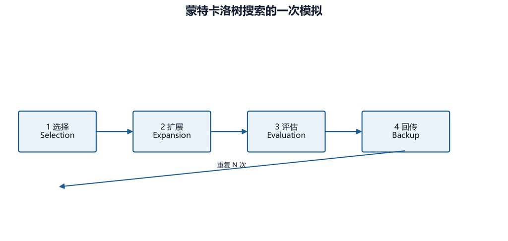

MCTS 的四个阶段

## 21.2 搜索树中的统计量

树中每个节点代表一个游戏状态，边代表一个合法动作。对父节点 $s$ 和动作 $a$，需要维护：

- $P(s,a)$：神经网络给出的先验概率；
- $N(s,a)$：这条边被访问的次数；
- $W(s,a)$：经过这条边得到的累计价值；
- $Q(s,a)=W(s,a)/N(s,a)$：平均价值。

第一次访问时 $N=0$，项目把对应 $Q$ 视为 0，避免除零。

### 数值例子

假设三个合法动作的统计如下：

| 动作 | $P$ | $N$ | $W$ | $Q$ |
| --- | --- | --- | --- | --- |
| 攻击 | 0.50 | 20 | 8 | 0.40 |
| 占点 | 0.30 | 5 | 3 | 0.60 |
| 结束回合 | 0.20 | 1 | 0 | 0.00 |

攻击的平均价值不如占点，但访问更多；结束回合证据最少。选择公式要同时利用现有价值与探索不足。

## 21.3 Selection：PUCT 选择

项目使用 AlphaZero 风格 PUCT：

$$\operatorname{score}(s,a)
=Q(s,a)
+c_{\text{puct}}P(s,a)
\frac{\sqrt{N(s)+1}}{1+N(s,a)}$$

其中：

- $N(s)$ 是父节点访问次数；
- $c_{\text{puct}}$ 控制探索强度；
- $P(s,a)$ 使网络认为较可能的动作优先得到搜索机会；
- 分母 $1+N(s,a)$ 会降低已经充分访问的分支的探索奖励。

假设父节点访问 25 次、$c_{\text{puct}}=1.5$。对上表“占点”：

$$U=1.5\times 0.30\times
\frac{\sqrt{26}}{1+5}
\approx 0.382$$

所以总分约为 $0.60+0.382=0.982$。

对“攻击”：

$$U=1.5\times0.50\times
\frac{\sqrt{26}}{21}
\approx0.182$$

总分约为 $0.582$。虽然攻击先验更高，但占点当前的价值和访问不确定性使它更值得继续探索。

### 玩家视角的符号

两人零和游戏中，“对当前玩家有利”通常意味着“对对手不利”。项目节点保存玩家身份，选择与回传时依据节点玩家和根玩家关系翻转 $Q$ 或累积价值的符号。

这是实现 MCTS 最容易出错的部分之一。若所有层都不翻号，搜索会假设对手配合根玩家；若重复翻号，又会把本来正确的价值变反。阅读代码时必须同时确认：

1. 网络价值从谁的视角输出；
2. 终局价值从谁的视角定义；
3. 回传存储统一根视角还是节点视角；
4. 选择时是否还需翻转。

当前实现的约定是：网络估值最初来自叶节点当前玩家视角，必要时转为根玩家视角；回传依据节点玩家与根玩家关系加减；选择子节点时再使 $Q$ 与当前父节点视角一致。

## 21.4 Expansion：只扩展合法动作

到达未扩展叶节点后，搜索取得真实合法动作，把它们映射到 Flat Discrete 索引，然后只为这些索引创建子节点。

项目平坦动作空间大小为：

$$|\mathcal A|=10\times W\times H$$

其中 10 是动作类别数，$W,H$ 为地图宽高。对 $20\times20$ 地图，策略头输出 4000 个 logit，但每个局面只扩展合法索引。

先验概率在网络中已经用动作掩码归一化。非法动作 logit 被设为约 $-10^8$，softmax 后概率接近零。树仍以游戏引擎给出的合法动作表为最终依据，而不是假设所有高概率索引均可执行。

### 惰性复制

项目创建子节点时不立即复制并推进全部状态。只有某个子节点首次在 Selection 中被选中，才：

1. 深复制父状态；
2. 把保存的动作引用解析到复制后的对象；
3. 执行动作；
4. 更新当前玩家和终局标志。

这样可避免为从未访问的分支支付完整状态复制成本。代价是动作对象不能直接从原状态复用，因为深复制后的单位与建筑是不同对象；必须按坐标或稳定标识重新解析。

## 21.5 Evaluation：策略头与价值头

叶节点不再进行随机 rollout，而由网络一次输出：

$$(p,v)=f_\theta(s)$$

- $p$ 是 Flat Discrete 动作空间上的概率；
- $v\in[-1,1]$ 是当前玩家视角的终局结果估计。

若节点已经终局，则不调用网络：

$$v=
\begin{cases}
+1,&\text{根玩家获胜}\\
0,&\text{和局}\\
-1,&\text{根玩家失败}
\end{cases}$$

网络减少了从叶节点一直随机模拟到终局的成本，但估值质量会直接限制搜索质量。未经训练的随机网络仍能完成流程测试，却不能提供可靠棋力。

## 21.6 Backup：把叶节点证据传回根

一条模拟路径得到叶节点价值 $v$ 后，对路径上的节点更新：

$$N\leftarrow N+1$$

$$W\leftarrow W+\sigma v$$

其中 $\sigma$ 根据节点玩家与根玩家是否一致取 $+1$ 或 $-1$。然后

$$Q=\frac{W}{N}$$

访问次数增加会使同一分支的平均价值逐渐稳定，也会降低它在 PUCT 中的探索项。

需要注意，MCTS 的一次“simulation”并不是一局完整游戏；它通常只从根沿当前树走到一个未展开叶节点，评估一次，再回传。

## 21.7 根节点狄利克雷噪声

自对弈若始终沿最大先验搜索，很快会反复产生相似轨迹。项目训练搜索在根节点混入狄利克雷噪声：

$$P'(s,a)
=(1-\varepsilon)P(s,a)+\varepsilon\eta_a$$

$$\boldsymbol\eta\sim
\operatorname{Dirichlet}(\alpha,\ldots,\alpha)$$

其中 `dirichlet_epsilon` 决定噪声权重，`dirichlet_alpha` 决定噪声形态。

- 较小 $\alpha$：概率质量集中到少数随机动作，探索更尖锐；
- 较大 $\alpha$：噪声更平均；
- $\varepsilon=0$：完全不注入根噪声。

项目默认 `dirichlet_alpha=0.3`、噪声权重 0.25。评估时应设置 `add_noise=False`，否则同一模型比较会混入不必要的搜索随机性。

## 21.8 从访问次数得到动作分布

搜索结束后，项目先用访问比例构造完整动作分布：

$$\pi(a\mid s)
=\frac{N(s,a)}{\sum_b N(s,b)}$$

这既是选动作的依据，也是 AlphaZero 训练策略头的监督目标。

温度 $\tau$ 进一步控制采样：

$$\pi_\tau(a\mid s)
=\frac{N(s,a)^{1/\tau}}
{\sum_bN(s,b)^{1/\tau}}$$

- $\tau=1$：保持访问比例；
- $0<\tau<1$：分布更尖锐；
- $\tau\to0$：趋向访问次数最大的动作；
- 项目对 `temperature=0` 直接使用 `argmax`。

假设访问次数为 $[50,30,20]$。$\tau=1$ 时概率为 $[0.5,0.3,0.2]$；$\tau=0.5$ 时平方后归一化：

$$[2500,900,400]/3800
\approx[0.658,0.237,0.105]$$

训练前期使用较高温度可增加局面多样性，后期和评估使用贪心选择可提高稳定性。

## 21.9 当前代码的完整调用路径

核心搜索接口是：

```python
action_probs, root_value = mcts.search(
    game_state,
    add_noise=True,
)
```

或者直接选动作：

```python
flat_action, action_probs = mcts.select_action(
    game_state,
    temperature=1.0,
    add_noise=True,
)
```

`search` 返回二元组，而不是包含字段的字典：

1. `action_probs`：长度为 $10WH$ 的访问分布；
2. `root_value`：根节点累计价值的均值。

搜索内部链路为：

```
GameState
  -> build_observation + legal flat mask
  -> AlphaZeroNet.predict
  -> expand legal children
  -> repeat PUCT / lazy state transition / evaluate / backup
  -> visit-count policy
```

## 21.10 计算成本

若每个真实动作运行 $S$ 次 simulation，一局有 $T$ 个微动作，那么至少约有 $S\times T$ 次叶节点网络评估，还伴随大量 Python 状态深复制、合法动作枚举和引擎执行。

例如 $S=100,T=300$，单局就可能需要约 3 万次模拟扩展。训练又需要许多自对弈局，因此 MCTS/AlphaZero 的 CPU 成本远高于一次前向传播选动作的 PPO。

可采用的工程优化包括：

- 批量评估多个叶节点；
- 缓存状态评估；
- 更紧凑的可复制状态；
- 减少无意义的微动作；
- 并行自对弈；
- 训练初期用较少 simulations，后期增加；
- 对等预算比较，而不是只比较训练迭代数。

项目当前实现更偏向清晰、可验证的实验原型，不能把它的吞吐率直接等同于高度优化的棋类 AlphaZero 系统。

## 21.11 失败模式与诊断

### 全零访问分布

可能原因包括：合法动作映射为空、simulation 数为 0、动作执行异常或根节点没有成功扩展。项目选择动作时有结束回合的 fallback，但 fallback 只能防止崩溃，不能说明搜索正确。

### 所有价值都接近零

随机初始化网络常出现这种情况。检查访问分布是否仍由先验和探索项形成；真正训练后再判断价值头是否有区分力。

### 搜索偏爱非法动作

检查三层一致性：

1. 网络掩码形状是否为 $10WH$；
2. flat 索引编码/解码是否一致；
3. 深复制后动作引用是否重新解析。

### 加大 simulation 数却没有提升

可能是价值网络误差形成系统性误导，也可能是动作粒度过细：大量搜索预算花在同一游戏回合内的排列选择，尚未看到长期局面变化。

### 评估结果波动

需要固定随机种子、关闭根噪声、使用 `temperature=0`，并扩大对局数。搜索本身的随机性与对局随机性必须分开控制。

## 21.12 为什么 MCTS 适合又不完全适合本项目

适合之处：

- 游戏规则可准确模拟；
- 状态可以深复制；
- 动作合法性可枚举；
- 双方对抗、终局胜负明确；
- 空间局面适合策略价值网络。

困难之处：

- 微动作分支多、对局长；
- 动作顺序可能产生大量近似等价分支；
- 状态复制和 Python 引擎执行较重；
- 不完全信息开启后，单一真实状态树会泄露隐藏信息；
- 训练网络之前，搜索缺乏可靠叶节点评估。

当前主线训练默认不启用战争迷雾，AlphaZero 路径也建立在可观测 `GameState` 上。若未来在 POMDP 条件下使用搜索，需要考虑信念状态、信息集合或 determinization，而不能直接让智能体搜索它本不应看到的信息。

## 21.13 最小实操

先运行 MCTS/AlphaZero 单元测试：

```powershell
pytest -q tests/test_alphazero.py
```

教材冒烟工具使用小网络与极少 simulation：

```powershell
python agents/learning-guide-v2/tools/smoke_labs.py --only mcts
```

预期检查项是：

- 搜索返回长度正确的概率数组；
- 所有概率有限且非负；
- 有访问时概率和约为 1；
- 非零概率只出现在合法 flat 索引；
- `root_value` 位于合理范围；
- 原始 `GameState` 没有被模拟修改。

这仍然是结构验证，不是棋力评估。

## 21.14 本章小结

MCTS 通过 Selection、Expansion、Evaluation 和 Backup，把网络的即时判断变成经过局面推演的访问分布。PUCT 平衡平均价值、网络先验和访问不确定性；根噪声与温度负责自对弈探索。对本项目而言，最关键的正确性条件是玩家视角、合法动作映射、状态复制和动作引用解析的一致性。

## 21.15 练习

1. 计算父访问次数为 99、子访问 9、先验 0.2、$Q=0.3$、$c_{\text{puct}}=1.5$ 时的 PUCT 分数。
2. 为什么评估时要关闭狄利克雷噪声并令温度为 0？
3. 若访问次数为 $[9,4,1]$，分别计算 $\tau=1$ 与 $\tau=0.5$ 的动作概率。
4. 说明深复制状态后不能直接复用原单位对象引用的原因。
5. 战争迷雾下直接搜索完整 `GameState` 会产生什么信息泄露？

# 第 22 章 AlphaZero：让搜索生成更强的学习目标

## 22.1 核心闭环

AlphaZero 不是“神经网络加 MCTS”这一静态组合，而是一个循环：

1. 当前网络指导 MCTS；
2. MCTS 产生比网络原始策略更强的访问分布；
3. 双方按该分布自对弈，得到终局结果；
4. 用访问分布训练策略头，用结果训练价值头；
5. 候选网络与当前最佳网络比较；
6. 达到门槛后替换最佳网络，再开始下一轮。

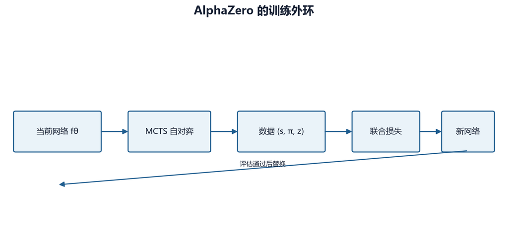

AlphaZero 训练闭环

网络为搜索提供方向，搜索又为网络提供改进目标。这种“策略改进—策略评估”循环与动态规划思想相通，只是使用神经网络近似大状态空间中的策略与价值。

## 22.2 训练样本 $(s,\pi,z)$

自对弈每一步保存：

$$(s_t,\pi_t,z_t)$$

其中：

- $s_t$：玩家相对视角编码的观察；
- $\pi_t$：MCTS 访问次数归一化后的动作分布；
- $z_t\in\{-1,0,+1\}$：对局结束后，从 $s_t$ 当前玩家视角回填的结果。

这里的策略目标不是实际采样出的单个动作，而是完整分布 $\pi_t$。例如一次搜索访问三个动作的次数是 50、30、20，那么目标为 $[0.5,0.3,0.2]$。它保留了搜索对多个候选分支的相对判断，比 one-hot 动作标签包含更多信息。

终局结果要按样本视角回填。若最后玩家 0 获胜：

- 玩家 0 回合采集的状态标签为 $+1$；
- 玩家 1 回合采集的状态标签为 $-1$；
- 和局则双方状态均为 0。

若忘记视角翻转，价值头会被同一局中的互相矛盾标签训练。

## 22.3 项目的双头网络

`AlphaZeroNet` 先把三部分观察组合起来：

1. `grid` 空间通道；
2. `units` 空间通道；
3. 广播到每个网格位置的 `global_features`。

张量从 $(B,H,W,C)$ 转为 PyTorch 卷积使用的 $(B,C,H,W)$，经过输入卷积和若干残差块，再分成两个头。

### 策略头

策略头输出：

$$\mathbf l_\theta(s)\in\mathbb R^{10WH}$$

其中 $\mathbf l$ 是 logits。预测时将非法动作位置设为约 $-10^8$，再做 softmax：

$$p_\theta(a\mid s)
=\frac{\exp l_a}
{\sum_{b\in\mathcal A_{\text{legal}}}\exp l_b}
,\quad a\in\mathcal A_{\text{legal}}$$

非法动作概率近似为 0。

### 价值头

价值头输出一个标量：

$$v_\theta(s)=\tanh(u_\theta(s))\in[-1,1]$$

这个范围与胜、和、负标签 $+1,0,-1$ 相匹配。

### 为什么使用残差块

残差块计算

$$y=x+F(x)$$

网络只需学习相对输入的修正 $F(x)$。跳连有助于梯度跨越较深网络，并允许多层卷积逐渐扩大感受野。项目默认 6 个残差块、128 个通道；教材冒烟会缩到 1 个块和少量通道，以验证流程而非模型容量。

## 22.4 联合损失

对一个 batch，项目策略损失是目标访问分布与网络 log-softmax 的交叉熵：

$$L_p
=-\frac1B\sum_{i=1}^{B}
\sum_a \pi_i(a)\log p_\theta(a\mid s_i)$$

价值损失是均方误差：

$$L_v
=\frac1B\sum_{i=1}^{B}
\left(v_\theta(s_i)-z_i\right)^2$$

代码组合为：

$$L=L_p+L_v$$

并由优化器的 `weight_decay` 实现参数正则化。书写成理论形式可记为

$$L(\theta)
=(z-v_\theta(s))^2
-\pi^\top\log p_\theta(\cdot\mid s)
+c\lVert\theta\rVert^2$$

### 数值例子

设搜索目标为

$$\pi=[0.7,0.2,0.1]$$

网络输出

$$p=[0.5,0.4,0.1]$$

则策略损失为

$$L_p
=-\left(
0.7\ln0.5+0.2\ln0.4+0.1\ln0.1
\right)
\approx0.899$$

若终局标签 $z=1$，价值预测 $v=0.4$，则

$$L_v=(1-0.4)^2=0.36$$

忽略正则项，总损失约为 1.259。

逐符号理解：

- $\pi$ 不是网络旧策略，而是搜索后的教师分布；
- $p_\theta$ 是网络当前预测；
- $z$ 是完整对局结束后的真实结果；
- $v_\theta$ 是当前状态下的结果预测。

## 22.5 搜索为何可看作策略改进

网络先验 $p_\theta$ 只经过一次前向传播。MCTS 利用规则模型向后推演，把计算集中到看起来更有价值或证据不足的分支，最后得到 $\pi$。

在理想情况下：

$$\pi \approx \operatorname{Improve}(p_\theta,v_\theta)$$

训练再使

$$p_{\theta'}\approx\pi$$

于是新网络把这次搜索获得的知识“摊销”进一次前向传播。下一轮搜索从更好的先验和价值出发，可以产生更好的目标。

这并不保证每轮都改进：

- 搜索预算太小，$\pi$ 可能主要反映噪声；
- 价值头错误会误导深层选择；
- 自对弈数据过于相似会导致策略覆盖变窄；
- 训练过度会过拟合最近 buffer；
- 候选评估样本过少会误判晋级。

## 22.6 Replay Buffer 与数据时效

项目的 `ReplayBuffer` 保存多个自对弈迭代的样本，容量由 `buffer_size` 控制。训练从中采样 batch。

保留历史数据的优点：

- 降低相邻自对弈局之间的相关性；
- 防止网络只记住最近候选策略；
- 提高样本复用率。

代价是数据由旧网络和旧搜索产生。容量太大时，训练目标可能滞后；容量太小时，数据多样性不足。需要联合考虑：

- 每轮自对弈局数；
- 每局样本数；
- buffer 容量；
- 每轮 epoch 数；
- 网络更新幅度。

“更大的 buffer 一定更稳定”不是普遍结论。

## 22.7 自对弈中的探索日程

项目用 `temperature_threshold` 控制一局中的探索阶段：

- 前若干动作按访问分布采样；
- 超过阈值后用低温或贪心选择。

原因是开局需要覆盖多种布局和战略，后期则希望减少随机失误，使终局标签更能反映策略质量。根节点狄利克雷噪声仅在自对弈时打开。

如果从第一步就完全贪心，buffer 很快被少数开局占据；如果全局一直高温，许多本可获胜的局会因后期随机动作而丢失，价值标签噪声上升。

## 22.8 候选模型晋级

每轮训练后，项目可让候选网络与上一最佳网络对局。设评估 $n$ 局，候选胜 $w$ 局，则经验胜率：

$$\hat p=\frac{w}{n}$$

达到 `eval_threshold` 才接受候选。默认阈值为 0.55。

若只评估 20 局，55% 对应 11 胜。11 比 10 只多一局，统计证据很弱。以二项分布的近似标准误差估计，在 $p\approx0.5,n=20$ 时：

$$\operatorname{SE}(\hat p)
\approx\sqrt{\frac{0.5(1-0.5)}{20}}
\approx0.112$$

一次随机波动就足以跨越门槛。因此：

- 冒烟测试可用少量对局检查流程；
- 正式晋级应扩大对局数；
- 双方交换先后手；
- 固定评估种子与搜索预算；
- 关闭根噪声；
- 报告胜/和/负，而不只给单一胜率。

如果候选未达门槛，当前实现恢复最佳网络参数，而不是继续以失败候选作为下一轮起点。这是“候选—最佳”门控机制。

## 22.9 当前实现状态

项目已经具备：

- 残差策略价值网络；
- 合法动作掩码；
- 神经网络引导的 MCTS；
- 根噪声和温度选动作；
- 自对弈样本生成；
- replay buffer；
- 联合策略/价值训练；
- 候选对最佳网络评估；
- checkpoint 与恢复入口；
- `AlphaZeroBot` 推理接入；
- 单元与冒烟测试。

同时必须保持准确定位：这是项目中的实验路径，并非已经由大规模、多种子、等计算预算实验确认优于 MaskablePPO 的生产级主线。MCTS 的 Python 状态复制和微动作搜索成本也使完整训练远比命令表面上的“100 次迭代”昂贵。

## 22.10 历史困难的因果整理

### 当时现象

- 搜索流程可以运行，但训练耗时很高；
- 小样本候选评估波动明显；
- flat 动作索引、合法掩码与真实引擎动作需要三方一致；
- 状态复制后，动作中的对象引用可能指向原状态；
- 价值的玩家视角容易在自对弈、叶估值和回传之间混淆。

### 调查证据

对应测试分别验证了网络输出形状与范围、掩码归一化、MCTS 返回分布、动作解析、自对弈样本以及训练损失。性能问题则来自每个真实微动作都要进行多次状态复制与叶评估，而不是单一网络前向本身。

### 已落地措施

- 使用 Flat Discrete 的统一编码；
- 搜索扩展只依据合法动作；
- 子状态惰性创建；
- 深复制后重新解析动作引用；
- 明确网络价值和终局标签的玩家相对视角；
- 自对弈与评估分别控制噪声、温度；
- 通过最佳模型门控避免每个候选自动成为新基线。

### 当前开放问题

- 如何降低状态复制和动作枚举成本；
- 微动作层搜索是否应改为游戏回合级宏动作；
- 候选评估应采用多大样本与何种置信门；
- 网络规模、搜索预算与自对弈数量的最优分配；
- 长期是否需要并行自对弈和批量叶评估。

## 22.11 最小训练

教材提供的 CPU 冒烟命令为：

```powershell
python scripts/train/train_alphazero.py `
  --map-file maps/1v1/starter.csv `
  --res-blocks 1 `
  --channels 16 `
  --num-simulations 1 `
  --iterations 1 `
  --games-per-iter 1 `
  --epochs-per-iter 1 `
  --batch-size 2 `
  --buffer-size 128 `
  --max-game-steps 4 `
  --temperature-threshold 2 `
  --eval-games 0 `
  --checkpoint-dir tmp/learning-guide-v2/alphazero `
  --device cpu
```

该命令已在基准环境中验证：生成 4 个自对弈样本，完成一次联合损失更新，并写出 iteration 与 final checkpoint。`eval-games=0` 在当前脚本中表示跳过候选晋级对局。

冒烟成功只表示：

- 自对弈能生成至少一个样本；
- policy target 形状为 $10WH$；
- 价值标签在 $[-1,1]$；
- 一次反向传播损失有限；
- checkpoint 可保存和读取。

## 22.12 结果应怎样阅读

训练日志至少同时看：

- `policy_loss`：网络与 MCTS 分布的差异；
- `value_loss`：结果预测误差；
- buffer 样本数；
- 每局平均长度；
- 搜索访问分布熵；
- 候选对最佳的胜/和/负；
- 每秒生成的自对弈步数；
- 每个真实动作的搜索时间。

策略损失下降不是充分成功条件。若 MCTS 教师本身质量差，网络只是更准确地模仿一个弱教师。价值损失下降也可能来自大量和局，使网络统一预测 0。必须结合对局和固定锚点评估。

## 22.13 与 PPO、自对弈 PPO 的区别

| 方面 | MaskablePPO | 自对弈 PPO | AlphaZero |
| --- | --- | --- | --- |
| 动作目标 | PPO 优势 | PPO 优势 | MCTS 访问分布 |
| 价值目标 | GAE 回报 | GAE 回报 | 终局结果 |
| 是否显式搜索 | 否 | 否 | 是 |
| 数据来源 | 环境对手 | 历史策略池 | 双方同源自对弈 |
| 每步推理成本 | 一次策略前向 | 一次策略前向 | 多次模拟与前向 |
| 主动作空间 | MultiDiscrete/掩码 | 同左 | Flat Discrete |
| 当前项目定位 | 主训练路径 | 进阶训练策略 | 实验路径 |

AlphaZero 并不是 PPO 加一个自对弈开关。它改变了训练标签、动作表示、推理过程与计算预算结构。

## 22.14 常见误解

**误解一：MCTS 分布是真实最优策略。**  
它只是给定网络、搜索预算和探索参数下的改进近似。

**误解二：价值头直接回归每步即时奖励。**  
项目目标是终局结果 $z$，不是单步 shaped reward。

**误解三：候选胜率 55% 就已证明更强。**  
结论强度取决于评估局数、置信区间和先后手控制。

**误解四：增加 simulations 总会线性提高实力。**  
弱价值网络、冗余动作树和计算瓶颈都可能产生收益递减。

**误解五：一次冒烟训练可与完整 AlphaZero 结果比较。**  
冒烟验证软件路径，不验证算法极限。

## 22.15 本章小结

AlphaZero 用网络指导搜索，再用搜索生成的访问分布与终局结果训练网络。项目实现了双头残差网络、合法动作掩码、MCTS、自对弈 buffer、联合损失与候选晋级。正确理解它需要同时把握三个视角：$\pi$ 是搜索教师，$z$ 是玩家相对终局标签，候选评估是带统计误差的实验而不是确定性裁决。

## 22.16 练习

1. 已知 $\pi=[0.6,0.4]$、$p=[0.75,0.25]$，计算策略交叉熵。
2. 为什么每个历史状态的 $z$ 必须按当时行动玩家的视角回填？
3. 分析 buffer 太大和太小各自可能产生的问题。
4. 20 局评估中 11 胜是否足以确信候选更强？请用标准误差解释。
5. 设计一组等计算预算实验，比较 MaskablePPO 与 AlphaZero，而不是简单比较“训练迭代数”。

# 第 23 章 实验设计、统计误差与可复现性

## 23.1 训练成功不是单次曲线上升

强化学习结果同时受初始化、环境随机性、探索动作、对手行为和评估样本影响。一次训练中胜率上升，只能说明“这一条随机轨迹在这一套条件下得到这个结果”，不能自动证明算法或配置更好。

一个可解释实验至少要明确：

- 研究问题；
- 对照组与实验组；
- 唯一主动改变的因素；
- 训练预算；
- 随机种子；
- 评估协议；
- 主要指标与次要指标；
- 失败判据；
- 代码、配置和环境版本。

## 23.2 先写假设，再运行

以“精确掩码是否优于逐维掩码”为例，合格的预注册式描述是：

> 在相同地图、对手、网络、总环境步数和随机种子集合下，自回归精确掩码将降低无效动作率，并提高固定评估集上的平均胜率。

它包含：

- 自变量：动作头与掩码方法；
- 因变量：无效动作率、胜率；
- 控制变量：地图、对手、网络、步数、种子；
- 方向性预测：降低或提高。

“试试这个参数是否更好”没有说明“好”的指标，也没有排除同时变化的因素。

## 23.3 随机种子控制了什么

项目训练可能涉及 Python `random`、NumPy、PyTorch、Gymnasium 环境以及 Bot 内部 RNG。只调用一次 `torch.manual_seed` 不等于完整复现。

理想做法是为每次 run 记录一个主种子 $s$，再确定性派生：

$$s_{\text{env}},s_{\text{policy}},s_{\text{opponent}},s_{\text{eval}}
=h(s,\text{component})$$

这样各组件既可复现，又不会意外共享完全相同的随机流。

训练和评估种子应分离。若训练过程不断在同一组评估种子上选 checkpoint，就会对评估集过拟合；应保留最终测试种子，只在模型选择完成后使用。

## 23.4 均值、方差与标准误

设 $n$ 个种子的最终胜率为 $x_1,\ldots,x_n$。样本均值：

$$\bar x=\frac1n\sum_{i=1}^n x_i$$

样本标准差：

$$s=\sqrt{
\frac1{n-1}\sum_{i=1}^n(x_i-\bar x)^2
}$$

均值标准误：

$$\operatorname{SE}(\bar x)=\frac{s}{\sqrt n}$$

假设五个种子的胜率为 0.40、0.55、0.45、0.60、0.50，均值是 0.50，样本标准差约 0.079，标准误约 0.035。

标准差描述单次 run 的离散程度；标准误描述对总体均值估计的不确定性。不能用“均值 ± 标准差”冒充均值置信区间。

## 23.5 胜率是二项比例

如果每局只有胜或负，胜局数

$$W\sim\operatorname{Binomial}(n,p)$$

经验胜率为 $\hat p=W/n$。简单正态近似标准误为

$$\sqrt{\frac{\hat p(1-\hat p)}n}$$

当样本很少或胜率接近 0/1 时，更适合 Wilson 区间，而不是对称正态区间。Wilson 95% 区间可写为

$$\frac{
\hat p+\frac{z^2}{2n}
\pm z\sqrt{
\frac{\hat p(1-\hat p)}n+\frac{z^2}{4n^2}
}}
{1+\frac{z^2}{n}}$$

其中 $z=1.96$。

若 20 局赢 12 局，点估计是 60%，但区间仍很宽。项目中的课程晋级和候选模型门控因此需要耐心、最小阶段步数或更多评估局，不能把一次略过阈值视为稳定能力。

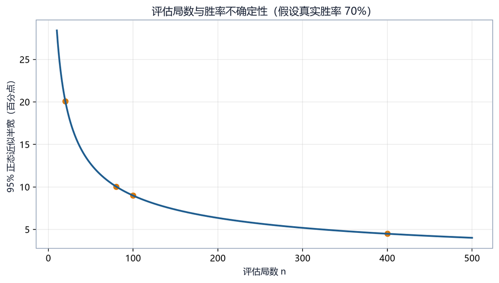

评估样本量与置信区间

## 23.6 和局与截断不能随意并入失败

策略游戏常有三种结果：胜、负、和。还要区分和局原因：

- `max_turns_draw`：游戏回合上限；
- `max_steps_truncate`：环境微动作上限；
- 规则定义的其他和局。

可报告：

$$\text{win rate}=\frac{W}{N}$$

$$\text{non-loss rate}=\frac{W+D}{N}$$

也可给和局半分的 score：

$$\text{score}=\frac{W+0.5D}{N}$$

但三者含义不同。若奖励塑形产生拖延吸引子，模型可能通过增加和局提高 non-loss rate，却没有提高获胜能力。因此本项目评估工具保留 wins、losses、draws 和 `end_reason` 分解。

## 23.7 训练曲线不是独立样本

同一 run 中相邻评估点共享绝大多数训练历史，不能把 100 个时间点当作 100 个独立实验。平滑曲线只用于看趋势，不增加独立证据。

绘图时建议：

- 横轴使用环境步数，而非日志行号；
- 多种子画均值线与置信带；
- 同时保留每个种子的细线；
- 标记阶段切换和配置改变；
- 不用过强平滑掩盖崩溃；
- 指标定义改变时分图，不强行拼接。

## 23.8 消融实验

消融实验通过移除或替换一个机制，判断改进来自哪里。以 Bootstrap 某版本为例，若同时改了奖励、对手、动作空间和晋级门，即使结果变好，也不能知道贡献来源。

一个 $2\times2$ 设计：

| 组别 | 精确掩码 | 势能塑形 |
| --- | --- | --- |
| A | 否 | 否 |
| B | 是 | 否 |
| C | 否 | 是 |
| D | 是 | 是 |

可以估计：

- 掩码主效应；
- 奖励主效应；
- 两者交互：精确掩码是否只有在某种奖励下才有效。

若计算预算有限，先做成对消融：从当前最佳配置只去掉一个机制。不要把不同训练预算的旧 run 当作严格对照。

## 23.9 配对评估

地图和先后手造成的方差可以通过配对降低。对模型 A 与 B：

1. 在地图 $m$、种子 $s$ 上让 A 先手；
2. 同一地图和种子让 B 先手；
3. 对所有地图、种子重复；
4. 对每一对的 score 差做统计。

配对差：

$$d_i=x_i^A-x_i^B$$

比较 $\bar d$ 比比较两组互不对应的均值更容易消除局面难度差异。

## 23.10 多重尝试与选择偏差

如果试了 54 个版本，只报告最好一个，哪怕所有版本真实能力相同，也容易因随机波动找到一个“赢家”。这叫多重比较或研究者自由度问题。

应保留：

- 所有版本清单；
- 每次改动原因；
- 失败结果；
- 选择下一实验的依据；
- 独立最终测试集。

## 23.11 可复现实验记录

每个 run 建议至少保存：

```yaml
experiment_id: mask_ablation_seed0
code_revision: <git commit>
created_at: <ISO-8601 time>
seed: 0
python: 3.12.13
gymnasium: 1.3.0
stable_baselines3: 2.9.0
sb3_contrib: 2.9.0
torch: 2.13.0+cpu
device: cpu
map: maps/1v1/starter.csv
opponent: balanced_random
total_timesteps: 100000
evaluation:
  seed: 10000
  episodes: 100
  deterministic: true
```

还需保存完整解析后的配置，而不只保存用户传入的 YAML。因为默认值可能随代码变化。

## 23.12 本项目的诊断指标

`evaluate_model` 除胜率与回报外，还能统计：

- 动作类型计数；
- `action`、`shaping_delta`、`invalid_penalty`、`terminal` 奖励分量；
- `hq_capture`、`elimination`、`max_turns_draw`、`max_steps_truncate`；
- 单位生产构成；
- captures、kills、attacks、seize attempts、伤害；
- 建筑治疗的 HP 与金币；
- 可夺取动作出现率；
- 最大合法动作数；
- 峰值军队规模与平均金币；
- 指定失败结局的逐步 JSONL trace。

这些指标用于区分“不会”与“不能”：

- `seize_available_rate` 很低：环境中很少出现可夺取机会；
- 机会很多但 seize 次数低：策略不愿选择；
- `max_legal_actions` 接近 flat 上限：动作截断风险；
- 胜率低且伤害高：可能只会战斗，不会完成胜利条件；
- 回报高但终局多为截断：可能奖励吸引子。

## 23.13 一个完整实验模板

研究问题：`reward_scale=0.001` 是否稳定 Feudal 的价值学习？

1. 选择两个配置，只改变 `reward_scale`；
2. 使用种子 0、1、2、3、4；
3. 每个种子训练相同环境步数；
4. 每 10 万步在固定 50 局开发集评估；
5. 最终 checkpoint 在未使用的 200 局测试集评估；
6. 主要指标：测试胜率；
7. 次要指标：Worker/Manager value loss、截断率、到达目标率；
8. 报告五种子均值、标准差和原始点；
9. 若某 run 崩溃，不静默删除，记录失败原因。

## 23.14 本章小结

强化学习实验的基本单位不是一条漂亮曲线，而是定义明确、可复现、带不确定性的比较。随机种子、评估协议、和局原因、配对设计和失败记录共同决定结论是否可信。项目的细粒度评估指标应服务于因果诊断，而不能由单一 episode reward 代替。

## 23.15 练习

1. 五个种子结果为 0.3、0.4、0.4、0.5、0.9。计算均值，并说明只报告均值为何危险。
2. 100 局中 60 胜、20 和、20 负，计算 win rate、non-loss rate 和半分 score。
3. 为什么相邻训练评估点不能当作独立样本？
4. 为“课程学习是否优于固定难度训练”设计一个公平对照。
5. 找出一个同时改变三个因素的错误实验，并改写为可解释的消融。

# 第 24 章 规则 Bot、训练对手与游戏平衡

## 24.1 对手是训练分布的一部分

在单智能体 1v1 包装中，环境内部替玩家 2 调用 Bot。对学习器而言，对手行为决定了状态转移分布：

$$P(s_{t+1}\mid s_t,a_t;\pi_{\text{opp}})$$

更换对手策略 $\pi_{\text{opp}}$，即使地图和奖励完全不变，智能体看到的状态、合法动作、战斗压力和回合长度都会改变。因此，“对手难度”不是界面设置，而是训练任务定义的一部分。

## 24.2 NoopBot：最低层的因果探针

`NoopBot` 不执行任何动作，只结束回合。它的用途不是提供有趣比赛，而是隔离故障：

- 若模型连静止对手都无法击败，问题大概率在探索、动作编码、奖励或胜利条件信用分配；
- 若能击败 Noop，却无法过渡到随机对手，问题更可能是对抗压力和策略鲁棒性；
- 若只会无限积累 shaped reward 而不终结 Noop，对奖励吸引子的判断更明确。

Noop 胜率高不是算法成熟的证据。它只通过了最低功能测试。

## 24.3 RandomBot 与动作吞吐量

`RandomBot` 每次从当前合法的非结束回合动作中均匀采样，最多尝试 `max_actions` 次，然后结束回合。

这带来一个常被忽略的难度维度：每回合动作吞吐量。`max_actions=1` 与 20 不只是同一随机策略的速度差异；前者很可能无法让所有单位行动，后者能持续生产、移动和攻击，造成完全不同的状态分布。

均匀随机合法动作也不等于均匀随机“战略”。如果移动动作数量远多于夺取动作，按动作条目均匀抽样会自然偏向移动。这就是动作集合基数诱导的行为偏差。

## 24.4 BalancedRandomBot：随军队规模增长的随机压力

`BalancedRandomBot` 每回合：

1. 若能生产，随机生产一个单位；
2. 对每个己方单位，从涉及该单位的合法动作中随机执行一个；
3. 结束回合。

它避免 `RandomBot(max_actions=1)` 在失去唯一单位后几乎不生产、形成自我停滞的问题，也避免固定 20 次动作在小军队阶段产生不自然高吞吐。压力大致随军队规模增长，因此适合放在 Noop 与强规则 Bot 之间。

## 24.5 SimpleBot：局部启发式

`SimpleBot` 分成生产、单位行动、结束回合三个阶段。它具有：

- 单位购买优先级；
- Warrior 比例上限，避免军队永久退化为单一廉价单位；
- 占领当前位置结构；
- 受伤单位留在己方治疗地块；
- Cleric 治疗、Mage 麻痹等单位特性；
- 按距离和目标类别寻找敌军或可占结构；
- 可选随机 tie-break。

这类 Bot 的强项是稳定、便宜、可解释。弱点是启发式分阶段固定，缺少跨单位的全局组合优化。

## 24.6 Medium、Advanced 与 Master

难度提升并不是简单增加属性。后续 Bot 在 Simple 的基础上引入更丰富的战术评分、威胁判断、协同、撤退与技能组合。

教材使用的能力梯应理解为经验性序列：

```
Noop
  -> BalancedRandom / 受限 Random
  -> Simple
  -> Medium
  -> Advanced
  -> Master
```

“类名更高级”不构成严格全序。某个 Bot 可能在地图 A 更强、地图 B 更弱；随机 Bot 也可能偶然克制确定性启发式。因此要用多地图、换边循环赛测量，而不是把名称直接当作 Elo。

## 24.7 MixedBot：平滑难度边界

`MixedBot` 在每个 episode 创建时，从 easy 与 hard 两个内部 Bot 中抽取一个：

$$\pi_{\text{opp}}=
\begin{cases}
\pi_{\text{hard}},&u<p_{\text{hard}}\\
\pi_{\text{easy}},&u\ge p_{\text{hard}}
\end{cases}$$

一整个 episode 使用同一个内部 Bot，不会在一局中途切换。这一点重要，因为中途切换会使对手行为突然改变，破坏局内策略一致性。

它可以构造桥接阶段：

- Simple/Medium 混合；
- Medium/Advanced 混合；
- 随课程进度逐步提高 `p_hard`。

混合训练的价值是降低突然换对手造成的分布跃迁，同时防止策略完全遗忘较弱对手上的基本终局能力。

## 24.8 确定性与随机 tie-break

规则 Bot 的排序常出现同分候选。若总按列表顺序取第一个，同一地图和先后手会产生字节级重复轨迹。`games_per_side` 即使大于 1，也可能只是重复同一局。

项目允许向 Bot 注入 `random.Random`，仅在评分相同处随机打破平局。Tournament 的 `rng_seed` 会结合 game id、地图和双方名称派生每局种子：

- 同一总种子可复现整组比赛；
- 同一对阵的多局又不是完全重复；
- 战术启发式质量保持不变，只改变同分选择。

平衡分析应记录该种子；调试确定性 replay 时则可不注入 RNG。

## 24.9 训练对手选择的三个风险

### 过弱

模型学会对手特有漏洞，例如：

- 对手不生产；
- 对手只做一个动作；
- 对手从不防守 HQ；
- 对手固定目标顺序。

在训练对手上胜率很高，换对手立即崩溃。

### 过强

训练早期几乎没有正回报，优势估计主要是失败噪声。更强对手不必然提供更好的学习信号。

### 过窄

即使难度适中，单一确定性策略也会使训练分布狭窄。模型可能记住对手节奏，而非学会通用游戏机制。

解决方法是课程、混合对手、自对弈历史池和固定锚点评估共同使用。

## 24.10 游戏平衡与学习难度

单位数值、经济和地图不只是“游戏设计”，还决定 RL 优化地形。

### 经济滚雪球

占领建筑提高未来每回合收入，收入又增加单位数量：

$$\text{capture}
\to\text{income}
\to\text{army}
\to\text{more capture}$$

这产生长期正反馈。若 shaped reward 只奖励即时伤害，策略可能忽略经济链；若过度奖励占领，又可能反复寻找可刷的结构奖励。

### 单位耐久与和局

高防御、治疗和自动恢复可延长战斗，使 max-turn 和局增多。此时训练曲线可能显示生存奖励提高，却不代表终局能力提高。

### 地图距离

HQ 距离增大使终局回报延迟。对 $\gamma=0.99$，200 步后的单位回报权重约为：

$$0.99^{200}\approx0.134$$

同一奖励在长地图上的信用显著变弱，所以地图课程同时改变了探索与折扣难度。

### 动作分支

单位越多，合法移动与技能动作越多。最大合法动作数是平衡指标，也是学习复杂度指标。

## 24.11 Bot 行为指标

不能只按胜率给 Bot 排名。建议记录：

- 每回合平均动作数；
- 生产单位构成；
- 首次交战与首次占领回合；
- HQ 捕获、消灭与和局比例；
- 平均银行金币；
- 峰值军队规模；
- 伤害交换比；
- 技能使用率；
- 先手优势；
- 地图分层胜率。

一个 Bot 可能胜率相同，但以截然不同方式施压。对训练而言，这种行为差异本身就是多样性资源。

## 24.12 平衡实验范式

假设要判断 Warrior 成本调整是否合理：

1. 保持 Bot 代码、地图和随机种子不变；
2. 用 `engine_overrides` 建立成本基线与候选；
3. 运行换边循环赛；
4. 比较总胜率、生产构成、首战时间和回合长度；
5. 检查是否只在某张地图改变；
6. 再用 RL 训练检查学习难度，而不是只看规则 Bot；
7. 把游戏平衡结论与算法结论分开。

若同时改收入、成本和攻击力，不能把胜率变化归因于某个单位成本。

## 24.13 最小实操

规则 Bot 测试：

```powershell
pytest -q `
  tests/test_noop_bot.py `
  tests/test_random_bot.py `
  tests/test_balanced_random_bot.py `
  tests/test_medium_bot.py `
  tests/test_advanced_bot.py `
  tests/test_master_bot.py `
  tests/test_mixed_bot.py
```

构造训练环境时可直接传递对手及参数：

```python
env = StrategyGameEnv(
    map_file="maps/1v1/starter.csv",
    opponent="mixed",
    opponent_kwargs={
        "easy": "simple",
        "hard": "medium",
        "p_hard": 0.5,
    },
)
```

验证时至少 reset 多个种子，并从实际创建的内部 Bot 或回合行为确认混合比例，而不能只检查配置字典。

## 24.14 本章小结

规则 Bot 同时是对手、课程阶段和诊断仪器。Noop 隔离环境与奖励问题，BalancedRandom 提供随军队规模增长的随机压力，规则启发式 Bot 提供稳定难度，MixedBot 平滑分布边界。对手选择与游戏平衡共同决定学习问题，必须用行为指标、多地图和换边实验测量。

## 24.15 练习

1. 为什么 `RandomBot(max_actions=1)` 与 `max_actions=20` 不能视为同一难度？
2. MixedBot 为什么按 episode 选内部 Bot，而不在每个回合重新抽取？
3. 设计一个能检测确定性重复对局的检查。
4. 给出“模型过拟合 SimpleBot”的三个可观察信号。
5. 设计 Warrior 成本调整的最小消融。

# 第 25 章 模型评估、Elo、循环赛与回放

## 25.1 评估回答的不是“训练奖励有多高”

训练 episode reward 受奖励塑形、探索动作和对手采样影响。评估应回答更直接的问题：

- 能否获胜；
- 以何种方式结束；
- 对哪些地图与对手有效；
- 是否依赖先手；
- 是否稳定复现；
- 是否出现拖延、刷分或动作退化。

因此需要把固定 episode 评估、成对模型比较、循环赛和回放结合起来。

## 25.2 `evaluate_model` 的调用契约

项目统一评估函数可用于普通 PPO 与 MaskablePPO：

```python
results = evaluate_model(
    model,
    env,
    n_episodes=50,
    deterministic=True,
    seed=10_000,
    track_breakdown=True,
    trace_dir="tmp/eval_traces",
)
```

它通过检查 `model.predict` 的签名决定是否传 `action_masks`。这避免把掩码参数错误地传给普通 PPO，也避免 MaskablePPO 在评估时失去掩码。

评估循环的终止条件是：

```python
done = terminated or truncated
```

但结果分类仍保留终局与截断原因。截断不是环境规则胜负，不能只因循环结束就当成失败。

## 25.3 平均回报与胜率的分工

平均回报可用于诊断奖励路径，胜率用于衡量任务结果。两者可能背离：

- 高伤害、高占领 shaped reward，但没有终结对局；
- 快速取胜使累计塑形少，回报反而低；
- 频繁截断获得生存或资源增量；
- 终局奖励尺度变化导致跨配置回报不可比。

所以同一表中应同时给：

| 指标 | 回答的问题 |
| --- | --- |
| 胜/和/负 | 是否完成对抗目标 |
| `end_reason` | 如何结束 |
| episode reward | 奖励函数怎样评价轨迹 |
| episode length/turns | 是否拖延 |
| reward breakdown | 哪一分量主导 |
| action counts | 策略实际做了什么 |

## 25.4 Elo 的基本公式

两个模型 A、B 的 Elo 差转为 A 的预期得分：

$$E_A=\frac{1}{1+10^{(R_B-R_A)/400}}$$

若 $R_A=1600,R_B=1400$：

$$E_A=\frac{1}{1+10^{-0.5}}\approx0.760$$

比赛实际得分 $S_A$ 取胜 1、和 0.5、负 0。更新：

$$R_A'=R_A+K(S_A-E_A)$$

若 A 意外失败，$K=32$：

$$R_A'=1600+32(0-0.760)\approx1575.7$$

B 对称增加约 24.3 分。

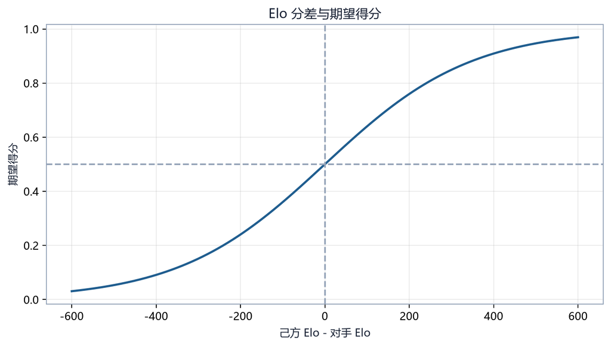

Elo 等级差与期望得分

## 25.5 Elo 的局限

Elo 假设一个近似一维、相对稳定的实力尺度。策略游戏常违反这些假设：

- A 克 B、B 克 C、C 克 A 的非传递循环；
- 地图改变相对强弱；
- 先手优势；
- 搜索预算不同；
- 模型仍在训练，实力非平稳；
- 多局来自同一确定性轨迹，不独立。

因此 Elo 是压缩摘要，不能替代对阵矩阵。至少同时保存：

- 每一对的胜/和/负；
- 地图分层；
- 先后手分层；
- 原始比赛数；
- rating history；
- 计算使用的 $K$ 与初始分。

## 25.6 循环赛调度

有 $m$ 个参赛者，单循环无方向配对数：

$$\binom m2=\frac{m(m-1)}2$$

若每一对在每张地图上双方各先手 $g$ 局，共 $L$ 张地图，总局数：

$$G=\frac{m(m-1)}2\times L\times2g$$

例如 6 个 Bot、3 张地图、每边 2 局：

$$G=15\times3\times4=180$$

比赛预算很快增长。可先用小地图与少量局做冒烟，再用预先固定的完整协议正式评估。

## 25.7 TournamentConfig 的重要字段

项目 `TournamentConfig` 包含：

- `maps` 与 `map_pool_mode`；
- `games_per_side`；
- `max_turns`；
- `output_dir`、replay 目录；
- `save_replays`；
- `enabled_units`；
- `rng_seed`；
- `concurrent_games`；
- 可选 LLM 日志与 API 间隔。

`validate()` 会检查地图存在、局数和回合数为正、模式取值、并发数、单位代码等。正式运行前先验证配置，避免比赛完成一半才发现地图或单位设置错误。

## 25.8 模型公平比较

比较两个 RL 模型时要锁定：

- 相同观察与动作空间；
- 相同 `pad_to_size`；
- 相同单位集合和引擎覆盖；
- 相同战争迷雾；
- 相同动作掩码语义；
- 相同确定性设置；
- AlphaZero 相同 simulation 数；
- 相同硬件或至少报告推理时延；
- 换边和相同地图种子。

若一个模型使用搜索 200 次，另一个只前向一次，只报告胜率是不完整的。应同时报告每步墙钟时间或等计算预算结果。

## 25.9 回放是行为证据

聚合指标能发现异常，回放用来解释异常。应优先检查：

- 高回报但未获胜的局；
- `max_steps_truncate`；
- 置信区间外的异常胜负；
- 先手和后手表现差异；
- 模型排名变化最大的地图；
- 高频无效动作或重复移动；
- 可夺取却不夺取的状态。

回放必须保存足够信息重建动作序列。项目测试包含 replay determinism 和 save replay，目的是确认同一动作记录能够重放为同一终局。

### Trace 与完整 replay

`evaluate_model` 可把特定 `end_reason` 的逐步信息写成 JSONL trace。Trace 适合快速统计和文本诊断；完整 replay 适合在游戏界面中重现。二者都不应只保存最终得分。

## 25.10 模型比较的分层报告

推荐报告结构：

1. **总体结果**：胜/和/负、score、Elo；
2. **地图层**：每张地图结果；
3. **先后手层**：玩家 1/2；
4. **终局层**：HQ 捕获、消灭、回合和局、微动作截断；
5. **行为层**：动作、单位、经济、伤害、占领；
6. **效率层**：每步推理时间、峰值内存；
7. **不确定性**：局数、种子、置信区间；
8. **定性证据**：典型与失败回放。

## 25.11 最小实操

评估与锦标赛测试：

```powershell
pytest -q `
  tests/test_rl_evaluation.py `
  tests/test_tournament_library.py `
  tests/test_tournament_config.py `
  tests/test_tournament.py `
  tests/test_save_replay.py `
  tests/test_replay_determinism.py
```

查看评估入口：

```powershell
python scripts/eval_agent.py --help
python scripts/tournament.py --help
```

不要在正式报告里只引用 `--help`。应把实际调用命令、解析后的配置和输出 JSON 一并保存。

## 25.12 典型误判

**只选 best checkpoint。**  
若 best 由很小评估集挑出，会有赢家诅咒。保留 final、best 和若干中间 checkpoint 的独立测试。

**Elo 高就全面更强。**  
检查非传递对阵和地图分层。

**多跑几次确定性 Bot 就等于增加样本。**  
没有随机 tie-break 时可能是重复 replay。

**回放看起来合理就证明算法有效。**  
回放是解释工具，不代替统计样本。

**截断都算和局就没有问题。**  
大量微动作截断往往是停滞或动作粒度问题，应单独报告。

## 25.13 本章小结

项目评估体系从单模型 episode 统计扩展到换边循环赛、Elo 和回放诊断。Elo 提供简洁相对尺度，但对阵矩阵、地图、先手和计算预算不可省略。可靠结论来自统计结果与行为证据相互验证。

## 25.14 练习

1. 计算 Elo 1500 对 1700 时前者的预期得分。
2. 8 个模型、4 张地图、每边 3 局的完整循环赛有多少局？
3. 为什么 AlphaZero 与 PPO 比较时必须报告搜索预算和推理时间？
4. 给出三类最值得人工查看的失败回放。
5. 设计一份能揭示非传递性的对阵报告。

# 第 26 章 LLM Bot：提示、状态序列化与安全执行

## 26.1 LLM Bot 不是强化学习训练

项目中的 LLM Bot 在每个游戏回合把状态转换成文本/JSON，请外部语言模型返回结构化动作，再校验并执行。它没有：

- rollout buffer；
- 策略梯度；
- Bellman 更新；
- 经验回放训练；
- 通过本局奖励更新模型参数。

因此它是推理型 Bot 与实验对手，不是本项目 RL 训练算法。LLM 可以参与行为比较、数据采集或生成示范，但这不改变它自身未在游戏中在线强化学习的事实。

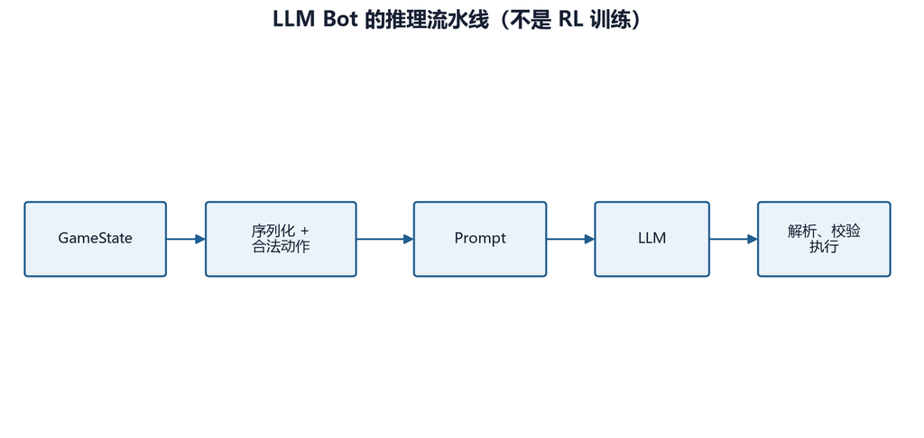

LLM Bot 的数据管线

本章不调用任何付费 API，实操全部使用 mock 响应。

## 26.2 状态为什么要序列化

语言模型不能直接读取 Python `GameState` 对象。`_serialize_game_state()` 要把当前决策所需信息转为 JSON 可表示结构，例如：

- 当前玩家与回合；
- 地图尺寸、地形和建筑；
- 双方金币；
- 单位 ID、类型、坐标、生命、状态；
- 可用技能与冷却；
- 当前合法动作；
- 胜负状态。

序列化有三个目标：

1. **完备性**：做合法决策所需信息不能缺失；
2. **最小性**：删除与决策无关的内部对象，控制 token 和歧义；
3. **稳定性**：字段名、坐标系、单位 ID 不随一次调用意外变化。

序列化不是简单 `str(game_state)`。内部对象引用、枚举和循环关系既不适合 JSON，也会让模型无法精确引用某个单位。

## 26.3 玩家视角与信息边界

若启用战争迷雾，LLM 状态也必须遵守可见性。不能因为 LLM 接口在游戏进程内部，就把完整敌方单位列表直接暴露给它。否则与使用局部观察训练的 RL 模型比较不公平。

相对视角还需要统一：

- 坐标仍是绝对地图坐标，还是旋转到己方视角；
- `player` 字段使用真实编号，还是 `self/opponent`；
- 建筑所有者的编码；
- 单位 ID 是否只在本局稳定。

提示中的规则与序列化字段必须一致。

## 26.4 提示由规则、任务与格式组成

项目提供 basic、strategic 和 two-phase 等提示策略。一个有效的系统提示应包含：

- 胜利条件；
- 单位、建筑和关键战斗规则；
- 可用动作；
- 行动顺序约束；
- JSON 输出模式；
- 禁止额外自然语言的要求。

提示过短会导致规则幻觉，过长会增加延迟、费用和关键信息被淹没的风险。更重要的是，提示中的数值会随游戏平衡变化；若硬编码规则与当前 `UNIT_DATA` 不一致，LLM 即使完全遵循提示也会作出错误判断。

因此应增加“提示规则—当前常量”的一致性测试，而不是把 prompt 当成永远正确的静态文案。

## 26.5 两阶段规划

`two_phase_planning=True` 时，流程分两次调用：

1. 规划阶段输出局势判断、主要目标、动作序列和风险；
2. 执行阶段读取该计划与最新状态，输出可执行动作 JSON。

优点是把“决定做什么”与“填写精确坐标和 ID”分开，便于日志诊断。代价是：

- API 调用、token、费用和延迟约增加；
- 计划可能在动作逐条执行后失效；
- 第二阶段可能不遵守第一阶段；
- 第一阶段计划并不通过游戏引擎验证。

两阶段不是自动获得更强推理的保证，必须通过固定题集与对局实验比较。

## 26.6 结构化动作

典型响应概念上为：

```json
{
  "reasoning": "先清除阻挡单位，再占领建筑。",
  "actions": [
    {"type": "attack", "unit_id": 2, "target_id": 7},
    {"type": "move", "unit_id": 3, "x": 5, "y": 4},
    {"type": "seize", "unit_id": 3},
    {"type": "end_turn"}
  ]
}
```

动作顺序有语义。第一步可能杀死目标、改变合法路径或结束游戏，后续动作必须依据更新后的 `GameState` 执行，不能只在响应开始时统一校验一次。

## 26.7 JSON 提取不是合法性验证

项目 `_extract_json` 依次尝试：

1. 整个文本直接 `json.loads`；
2. Markdown JSON 代码块；
3. 文本中首尾花括号片段。

解析成功只说明语法是 JSON，不说明：

- 存在 `actions`；
- `actions` 是列表；
- 动作类型已知；
- 单位属于当前玩家；
- 目标存在；
- 坐标在地图内；
- 技能未冷却；
- 动作在当前更新后的局面合法。

因此 `_execute_actions` 和各 `_execute_*` 方法仍需把单位 ID 映射回当前对象，并调用游戏规则校验。

## 26.8 逐动作重新校验

假设 LLM 返回：

1. 单位 2 攻击单位 7；
2. 单位 3 移动到单位 7 原位置；
3. 单位 3 占领。

若第一击没有击杀，第二步可能因位置占用而非法；若第一击直接赢得游戏，后续动作都应停止。正确执行器要在每一步：

- 检查 `game_over`；
- 重新取得或验证对象；
- 依据当前状态执行；
- 捕获单步异常；
- 防止异常动作破坏整个回合；
- 最终在需要时安全结束回合。

这与 RL 动作掩码的思想相通：模型输出只是提议，环境规则才是合法性的最终裁决者。

## 26.9 失败恢复

`LLMBot.take_turn()` 的主流程包含重试。若调用失败或响应无效，Bot 应安全回退到结束回合，而不是让游戏主循环崩溃。

需要区分：

- 网络/API 错误；
- 超时或限流；
- 响应被截断；
- JSON 语法错误；
- schema 错误；
- 某个动作因状态变化无效；
- 模型主动 resign。

把所有失败都记为“模型选择 end_turn”会丢失诊断信息。日志应分别记录 stop reason、重试次数、原始响应、执行成功数和失败原因。

## 26.10 状态历史与 token

`stateful=True` 时，会把先前 user/assistant 消息加入后续调用。历史可能帮助模型保持计划，但也会：

- 重复发送大量旧状态；
- 让模型混淆旧单位位置；
- token 和延迟随回合增长；
- 把早期错误计划持续带入。

更稳健的做法是使用结构化短期记忆：保留上回合计划摘要，而把当前 `GameState` 始终作为权威事实。若使用完整历史，应明确最大长度与裁剪规则。

项目跟踪累计输入、输出 token，并可把每回合 prompt、响应、使用量和 stop reason 写入 JSON 日志。这些是比较 LLM Bot 成本不可缺少的数据。

## 26.11 延迟与成本模型

一局近似成本可写为

$$C
=\sum_{t=1}^{T}
\left(
n_t^{\text{in}}c_{\text{in}}
+n_t^{\text{out}}c_{\text{out}}
\right)$$

其中：

- $T$：LLM 决策回合数；
- $n_t^{\text{in/out}}$：第 $t$ 回合输入/输出 token；
- $c_{\text{in/out}}$：每 token 价格。

总延迟近似为

$$L=\sum_t(L_t^{\text{network}}+L_t^{\text{generation}})+L^{\text{retry}}$$

价格与模型可随时间变化，本书不固化供应商报价。实验应记录调用时模型名、日期和实际 usage；本章也不发起真实请求。

## 26.12 安全边界

游戏中的 LLM 输出仍是不可信输入。执行器应：

- 只接受白名单动作；
- 限制每回合动作数量；
- 限制字符串与数组大小；
- 不把响应拼接成 Python 或 shell 执行；
- 不允许模型选择文件路径；
- 对日志中的 API key 做隔离；
- 对异常响应安全失败；
- 在提示中避免暴露不必要的环境变量与路径。

结构化输出降低解析歧义，不等于建立安全边界。

## 26.13 Mock 实操

运行已有测试，不需要 API key：

```powershell
pytest -q tests/test_llm_bot.py tests/test_llm_prompts.py
```

测试应覆盖：

- 固定 `GameState` 的序列化快照；
- 纯 JSON、代码块 JSON、带前后文本 JSON；
- 缺少 `actions`；
- 未知动作类型；
- 错误单位 ID；
- 顺序执行后第二动作失效；
- API 异常后的重试和 end-turn fallback；
- token 统计与日志格式；
- 两阶段规划 mock。

一个最小 mock 的思想是继承 `LLMBot`，让 `_call_llm` 返回固定字符串。这样测试的是本地数据管线，不产生网络费用。

## 26.14 LLM 与 RL 的可比性

比较 LLM Bot 和 RL Bot 时应说明：

- LLM 是否看到完整规则文本；
- 两者是否看到同样的战争迷雾；
- LLM 一次返回整回合动作，RL 每次返回微动作；
- 是否允许两阶段规划；
- 每步/每局延迟；
- token 成本与硬件成本；
- 是否使用外部模型更新后的版本；
- 随机温度；
- 失败 fallback 如何计分。

否则“胜率更高”可能主要来自信息量和计算预算差异。

## 26.15 本章小结

LLM Bot 是一个状态序列化—提示—结构化响应—逐动作校验—安全回退的工程管线，而不是 RL 算法。决定其可靠性的往往不是提示辞藻，而是信息边界、schema、动态合法性校验、日志与失败处理。项目测试可以在完全不调用付费 API 的情况下验证这些关键环节。

## 26.16 练习

1. 解释 JSON 语法正确与游戏动作合法之间的区别。
2. 为什么多个动作必须按执行后的新状态逐个校验？
3. 为 LLM 响应设计一个最小 JSON Schema。
4. 列举 `stateful=True` 的两个收益和三个风险。
5. 设计一组不调用外部 API 的 LLM Bot 回归测试。

# 第 27 章 DEV 工具链与综合研究实践

## 27.1 从“能运行”到“可研究”

强化学习项目同时包含游戏规则、环境适配、算法、配置、评估与可视化。某一层悄悄变化，最终表现可能完全不同。DEV 工具链的职责是把这些层的契约固定下来，使问题能够复现、定位和回归验证。

本项目在 `pyproject.toml` 中把开发依赖列为：

- pytest、pytest-cov；
- pre-commit；
- Ruff；
- mypy。

这些工具不提高策略网络的表达能力，却决定实验结论是否建立在稳定实现之上。

## 27.2 测试金字塔

### 单元测试

验证纯函数或局部契约：

- flat 动作编码/解码；
- 掩码形状与至少一个合法动作；
- GAE 数值；
- Elo 更新；
- JSON 提取；
- 配置验证。

### 集成测试

跨模块验证：

- `StrategyGameEnv.reset/step`；
- MaskablePPO 与 wrapper；
- BC checkpoint 加载到 PPO；
- Feudal rollout 与两层 update；
- MCTS 深复制后执行动作；
- replay 保存与重放。

### 冒烟测试

用极小预算跑完整路径：

- 64 个环境步；
- 1 次训练迭代；
- 1 局短自对弈；
- 1 个 checkpoint；
- 1 次导出。

冒烟成功表示接口贯通，不表示算法效果。

### 统计回归

固定小任务和种子，允许合理波动地检查：

- Noop 最低胜率；
- 无效动作率不超过上限；
- episode 不全部截断；
- loss 为有限数；
- 性能没有数量级退化。

统计回归不能写成要求每次 reward 完全相同，除非环境和算法路径确实确定性。

## 27.3 质量检查命令

项目级检查可依次运行：

```powershell
ruff check .
mypy reinforcetactics
pytest
```

`pyproject.toml` 当前配置 pytest 覆盖率门槛为 65%。只运行少量测试时，全局覆盖率门槛可能导致“测试本身通过，但命令因覆盖率不足退出”。局部调试可明确使用：

```powershell
pytest -q tests/test_alphazero.py --no-cov
```

最终提交前仍应运行项目规定的完整测试与覆盖率检查，不能把 `--no-cov` 当作验收结果。

## 27.4 配置优先级

一个可靠的配置系统应明确：

```
代码默认值
  < 配置文件
  < 命令行显式参数
```

项目训练脚本先从 YAML/JSON 读取配置并设置 argparse 默认值，再由 CLI 覆盖。嵌套的 `reward_config`、`engine_overrides`、`opponent_kwargs` 等不能简单靠标量参数表达，因此需要显式传入环境工厂。

诊断配置时保存三份证据：

1. 原始配置文件；
2. 命令行；
3. 程序实际解析后的完整配置。

只看 YAML 不足以证明训练环境真正收到了字段。

## 27.5 诊断顺序

当训练失败时，按由低到高的顺序排查：

```
规则层
  -> 环境契约
  -> 观察与动作
  -> 奖励与终止
  -> 算法数值
  -> 对手与课程
  -> 统计评估
```

### 规则层

用固定动作或规则 Bot 确认胜负、伤害、占领和经济。

### 环境契约

检查空间包含 observation/action，`terminated` 与 `truncated` 正确。

### 观察与动作

检查玩家相对视角、padding、掩码与真实合法动作一致。

### 奖励与终止

打印 breakdown，确认终局脉冲、势能差分和截断 bootstrap。

### 算法数值

检查 NaN、梯度范数、value loss、entropy、KL 与 clip fraction。

### 对手与课程

确认当前实际对手、地图、阶段、checkpoint 交接和晋级门。

### 统计评估

最后才判断算法是否真的更强。

这个顺序避免在环境动作编码错误时先调整学习率。

## 27.6 最小可复现问题

一个训练问题通常可以缩小为：

- 单地图；
- 单环境；
- CPU；
- 固定种子；
- 64–2048 步；
- 无渲染；
- 最少 callback；
- 输出观察形状、掩码数、奖励分解和终止原因。

若问题在最小版本消失，再逐个恢复 VecEnv、多地图、自对弈、课程和大网络。一次恢复一个因素，才能定位触发条件。

## 27.7 日志与 checkpoint

训练产物应形成一个不可歧义的 run 目录：

```
run/
  resolved-config.yaml
  metadata.json
  tensorboard/
  checkpoints/
  eval/
  traces/
  final_model.zip
```

checkpoint 不只是网络参数。要可继续训练，还可能需要：

- 优化器状态；
- 当前环境步数；
- 学习率日程；
- replay/rollout 相关状态；
- 当前课程阶段；
- 最佳评估指标；
- 自对弈快照池；
- 随机数状态。

缺少这些状态时，“resume”可能只是从权重重新开始一个不同实验。

## 27.8 综合实践：从短训练到研究报告

下面给出一条不依赖旧知识文件的完整路线。

### 阶段 A：环境验收

运行：

```powershell
python agents/learning-guide-v2/tools/smoke_labs.py --only env
python agents/learning-guide-v2/tools/smoke_labs.py --only masks
```

保存 observation 形状、合法动作数、随机合法动作的 step 结果，以及 MultiDiscrete 各维掩码。

### 阶段 B：接口边界

验证：

- DQN + 默认 MultiDiscrete 必须得到清晰的不兼容结果；
- DQN + Flat Discrete 可以构造；
- A2C 可以构造，但普通 A2C 不消费掩码；
- MaskablePPO 构造并学习 64 步。

这一步的结果是软件能力矩阵，不是算法排名。

### 阶段 C：第一条训练曲线

使用 `labs/maskable-ppo-smoke.yaml` 在 CPU 上训练短预算。确认：

- TensorBoard 有 rollout 和 train 指标；
- 模型能保存；
- 固定 5 局评估能运行；
- 结果中有终局原因和奖励分解。

### 阶段 D：课程训练

运行 `labs/bootstrap-smoke.yaml`，门槛设为 0 只验证阶段迁移。正式实验再恢复合理门槛、最小阶段步数、耐心和多局评估。

### 阶段 E：进阶路径

依次执行：

- BC 数据管线与一次交叉熵更新；
- BC 权重加载到 PPO；
- 自对弈快照池采样；
- Feudal 两层 rollout；
- MCTS 2 次 simulation；
- AlphaZero 一个自对弈样本与一次更新。

不要同时调试全部路径。每项先在单独报告中通过，再组合。

### 阶段 F：正式研究问题

选择一个可证伪问题，例如：

> 在 5 个种子、每个 50 万环境步的预算下，Bootstrap 是否比固定 BalancedRandom 训练提高对 MediumBot 的独立测试胜率？

建立两组配置，固定其余变量，预先确定主要指标与测试种子。

### 阶段 G：报告

报告至少包括：

1. 问题与假设；
2. 代码 revision 和环境版本；
3. 完整配置；
4. 训练预算；
5. 多种子曲线；
6. 最终原始结果和置信区间；
7. 终局、动作、奖励分解；
8. 失败 run；
9. 典型回放；
10. 限制与下一实验。

## 27.9 教材构建与验证

新版教材提供四类命令：

```powershell
python agents/learning-guide-v2/tools/generate_figures.py
python agents/learning-guide-v2/tools/smoke_labs.py
python agents/learning-guide-v2/tools/build_book.py
python agents/learning-guide-v2/tools/verify_book.py
```

它们分别：

- 重绘教材静态图；
- 运行低成本接口冒烟；
- 从 `book.json` 的同一章节清单生成连续 HTML 与 PDF；
- 检查章节、链接、图片、算法覆盖、PDF 文本和书签。

PDF 还需通过 Poppler 渲染为逐页 PNG，在 `tmp/pdfs/` 中检查：

- 中文字体缺字；
- 表格或代码越界；
- 公式被截断；
- 标题孤行；
- 图片模糊；
- 空白页；
- 页眉页码冲突。

自动检查不能代替视觉检查。

## 27.10 DEV 中的常见错误

**修复训练问题却没有测试环境契约。**  
算法层可能只是掩盖底层错误。

**复制配置后只改文件名。**  
必须验证解析值真的不同。

**用冒烟结果宣称性能。**  
冒烟只验证路径。

**忽略工作树已有改动。**  
实验和文档修改应保持范围清晰，不覆盖无关用户文件。

**只保存 final model。**  
无法恢复训练上下文，也无法解释 best 与 final 差异。

**测试用 mock，最终却从未做集成测试。**  
mock 隔离外部依赖；真实组件边界仍需本地、免费、可控的集成验证。

## 27.11 研究伦理与结果表述

报告应明确：

- 未运行的实验不能写成已验证；
- 历史结果不能冒充当前代码复现；
- 单种子结果不能表述为一般结论；
- 失败版本不能从实验索引中消失；
- LLM mock 不能冒充真实供应商性能；
- 教材示意数字要标注“算例”，历史数据要标注“历史数据”。

严格表述不会削弱研究价值，反而使下一位读者能准确接续工作。

## 27.12 全书实践终点

完成本章后，读者应能够：

- 从游戏机制定义 MDP/POMDP；
- 推导并解释回报、价值、GAE 和 PPO；
- 理解 PyTorch、Gymnasium、SB3/sb3-contrib 的职责；
- 追踪观察、动作、掩码、奖励和终止的数据链；
- 运行 MaskablePPO 主线；
- 分析 DQN、A2C 的适用边界；
- 使用课程、BC 与自对弈；
- 理解 Feudal、MCTS 和 AlphaZero 的实验实现；
- 设计带置信区间和消融的研究；
- 使用 Bot、Tournament、Elo、回放和 trace 评估；
- 在不调用外部 API 的条件下测试 LLM Bot 管线；
- 构建并验证整本教材。

## 27.13 本章小结

DEV 工具链把游戏、环境、算法和研究结论连接成可验证系统。最有效的排障方式是从规则与契约逐层上升；最可靠的研究流程是先用冒烟确认软件，再以多种子、独立评估和完整记录回答性能问题。

## 27.14 练习

1. 为什么局部 pytest 可能在测试都通过后仍因覆盖率门槛退出？
2. 写出一个训练配置的三层优先级，并说明如何保存解析结果。
3. 把“模型不学习”缩小成一个最小可复现问题。
4. 设计一个 checkpoint 恢复一致性测试。
5. 按本章模板提出一个关于奖励塑形的可证伪研究问题。

# 附录 A 数学符号、公式与术语速查

本附录供连续阅读时回查。它不是对正文的外部依赖：每个核心概念在正文首次出现时仍有完整解释。

## A.1 记号约定

| 符号 | 读法 | 含义 | 常见范围 |
| --- | --- | --- | --- |
| $t$ | t | 环境微动作时间下标 | $0,1,2,\ldots$ |
| $s_t$ | s 下标 t | 时刻 $t$ 的状态 | 状态空间 $\mathcal S$ |
| $o_t$ | o 下标 t | 智能体实际观察 | 观察空间 $\mathcal O$ |
| $a_t$ | a 下标 t | 智能体动作 | 动作空间 $\mathcal A$ |
| $r_t$ | r 下标 t | 一步奖励 | 实数 |
| $\pi(a\mid s)$ | pi | 状态下的动作概率 | $[0,1]$，对动作求和为 1 |
| $\theta$ | theta | 神经网络参数 | 实向量 |
| $\gamma$ | gamma | 折扣因子 | 通常 $[0,1)$ |
| $\lambda$ | lambda | GAE 偏差—方差参数 | $[0,1]$ |
| $\alpha$ | alpha | 学习率或其他权重 | 由上下文决定 |
| $\epsilon$ | epsilon | PPO 裁剪宽度或探索率 | 由上下文决定 |
| $V^\pi(s)$ | V | 状态价值 | 期望折扣回报 |
| $Q^\pi(s,a)$ | Q | 动作价值 | 执行动作后的期望折扣回报 |
| $A^\pi(s,a)$ | A | 优势 | $Q^\pi-V^\pi$ |
| $G_t$ | G | 从 $t$ 开始的回报 | 奖励的折扣和 |
| $\delta_t$ | delta | TD 残差 | 实数 |
| $\mathbb E[X]$ | E | 随机变量的期望 | 实数 |
| $\operatorname{Var}(X)$ | Var | 方差 | 非负 |
| $\nabla_\theta$ | nabla | 对参数的梯度 | 与 $\theta$ 同形 |
| $H(\pi)$ | H | 策略熵 | 非负 |
| $D_{\mathrm{KL}}$ | KL | 分布差异 | 非负 |
| $N(s,a)$ | N | MCTS 访问次数 | 非负整数 |
| $P(s,a)$ | P | MCTS 网络先验 | $[0,1]$ |
| $W(s,a)$ | W | MCTS 累计价值 | 实数 |

同一希腊字母在不同算法中可能有不同含义。比如 $\alpha$ 在 DQN 中常指学习率，在 Feudal 章节中又表示 Worker 外在奖励权重。判断含义必须看公式定义，不能只看字母。

## A.2 集合、下标与条件

$\mathcal S$ 表示所有可能状态的集合，单个状态写作 $s\in\mathcal S$。花体大写通常表示空间或集合。

$$\pi(a\mid s)$$

竖线读作“在……条件下”。它表示已知状态 $s$ 时选择动作 $a$ 的概率，不是除法。

$$x_{1:T}=(x_1,x_2,\ldots,x_T)$$

表示从 1 到 $T$ 的一段序列。

$$\mathbf 1[C]$$

是指示函数：条件 $C$ 成立取 1，否则取 0。它常用于终局、合法性或到达目标奖励。

$$\arg\max_a f(a)$$

返回使 $f(a)$ 最大的动作，而 $\max_a f(a)$ 返回最大数值。两者不要混淆。

## A.3 概率与统计

### 概率分布

离散动作策略满足：

$$\pi(a\mid s)\ge0,\qquad
\sum_{a\in\mathcal A}\pi(a\mid s)=1$$

动作掩码后，求和只在合法集合上进行。

### 期望

离散随机变量：

$$\mathbb E[X]=\sum_xp(x)x$$

若一次攻击 70% 造成 10 点、30% 造成 0 点，期望伤害为 $0.7\times10+0.3\times0=7$。期望 7 不表示某次一定造成 7 点。

### 方差与标准差

$$\operatorname{Var}(X)
=\mathbb E[(X-\mathbb E[X])^2]$$

$$\operatorname{SD}(X)=\sqrt{\operatorname{Var}(X)}$$

平方保证正负偏差不会抵消；开根号使标准差恢复到原变量单位。

### 协方差

$$\operatorname{Cov}(X,Y)
=\mathbb E[(X-\mathbb E[X])(Y-\mathbb E[Y])]$$

正值表示二者倾向同向变化，负值表示反向变化。相关不等于因果。

### 样本均值

$$\bar x=\frac1n\sum_{i=1}^{n}x_i$$

训练曲线若只有一个种子，曲线上的多个时间点不是独立样本，不能用它们代替多种子均值。

### 样本方差

$$s^2=\frac1{n-1}\sum_i(x_i-\bar x)^2$$

分母使用 $n-1$ 是对有限样本估计总体方差的校正。

### 标准误

$$\operatorname{SE}(\bar x)=\frac{s}{\sqrt n}$$

增加独立种子能降低均值估计误差，但收益按平方根增长：把标准误减半，约需四倍样本。

### 置信区间

大样本正态近似：

$$\bar x\pm1.96\operatorname{SE}(\bar x)$$

95% 置信区间的频率学解释是：若重复相同抽样过程，约 95% 的此类区间覆盖真实参数；不是“参数有 95% 概率落在本次区间”。

## A.4 向量与矩阵

向量：

$$\mathbf x=
\begin{bmatrix}
x_1\\x_2\\\vdots\\x_d
\end{bmatrix}$$

可表示全局特征或网络隐藏状态。

点积：

$$\mathbf w^\top\mathbf x
=\sum_{i=1}^{d}w_ix_i$$

每个输入乘权重再求和。线性层：

$$\mathbf y=W\mathbf x+\mathbf b$$

若 $\mathbf x\in\mathbb R^d$、输出 $\mathbf y\in\mathbb R^k$，则 $W\in\mathbb R^{k\times d}$、$\mathbf b\in\mathbb R^k$。

形状检查是调试神经网络的第一工具。矩阵乘法 $AB$ 只有在 A 的列数等于 B 的行数时成立。

## A.5 导数、梯度与链式法则

一元导数：

$$f'(x)=\lim_{h\to0}\frac{f(x+h)-f(x)}h$$

它描述局部斜率。若损失随参数增加而上升，导数为正，梯度下降会减小参数。

多参数梯度：

$$\nabla_\theta L=
\begin{bmatrix}
\partial L/\partial\theta_1\\
\vdots\\
\partial L/\partial\theta_d
\end{bmatrix}$$

梯度下降：

$$\theta\leftarrow\theta-\alpha\nabla_\theta L$$

链式法则：

$$\frac{\partial L}{\partial x}
=\frac{\partial L}{\partial y}
\frac{\partial y}{\partial x}$$

深度网络的反向传播就是把这个规则从输出层反复应用到输入层。PyTorch `loss.backward()` 计算梯度，`optimizer.step()` 才更新参数，`optimizer.zero_grad()` 清除默认累积的旧梯度。

## A.6 激活、softmax 与对数概率

ReLU：

$$\operatorname{ReLU}(x)=\max(0,x)$$

Tanh：

$$\tanh(x)=\frac{e^x-e^{-x}}{e^x+e^{-x}}\in(-1,1)$$

Softmax：

$$p_i=\frac{e^{z_i}}{\sum_j e^{z_j}}$$

为了数值稳定，实际实现会减去最大 logit：

$$p_i=\frac{e^{z_i-z_{\max}}}
{\sum_j e^{z_j-z_{\max}}}$$

概率乘积在长序列中容易下溢，因此策略梯度使用对数概率：

$$\log\prod_t\pi(a_t\mid s_t)
=\sum_t\log\pi(a_t\mid s_t)$$

对数不会改变概率大小次序，并把乘积变为求和。

## A.7 监督学习损失

均方误差：

$$L_{\mathrm{MSE}}
=\frac1B\sum_i(\hat y_i-y_i)^2$$

项目价值网络、Q 网络和 AlphaZero 价值头都会使用平方误差。

交叉熵：

$$L_{\mathrm{CE}}
=-\sum_k y_k\log p_k$$

one-hot 标签时只保留正确类别的 $-\log p$。BC 用它学习专家动作；AlphaZero 则以软目标 $\pi$ 对完整动作分布求和。

类别加权交叉熵：

$$L=-w_y\log p_y$$

可提高少数动作类别的贡献，但不能创造数据中从未出现的状态—动作关系。

## A.8 回报与折扣

有限 episode 回报：

$$G_t=r_t+\gamma r_{t+1}+\gamma^2r_{t+2}+\cdots$$

递推形式：

$$G_t=r_t+\gamma G_{t+1}$$

有效时间尺度粗略为：

$$H_{\mathrm{eff}}\approx\frac1{1-\gamma}$$

$\gamma=0.99$ 时约 100 步。这不是硬截止线，而是理解折扣衰减的尺度。

## A.9 价值、Q 与优势

$$V^\pi(s)=\mathbb E_\pi[G_t\mid s_t=s]$$

$$Q^\pi(s,a)
=\mathbb E_\pi[G_t\mid s_t=s,a_t=a]$$

$$A^\pi(s,a)=Q^\pi(s,a)-V^\pi(s)$$

优势为正表示该动作优于状态下的平均策略，负值表示较差。它不是“会赢的概率”，单位与回报相同。

## A.10 Bellman 方程

状态价值：

$$V^\pi(s)
=\sum_a\pi(a\mid s)
\sum_{s',r}p(s',r\mid s,a)
[r+\gamma V^\pi(s')]$$

最优动作价值：

$$Q^*(s,a)
=\mathbb E[
r+\gamma\max_{a'}Q^*(s',a')
\mid s,a]$$

Bellman 方程把长期量分为“一步奖励 + 下一状态的长期量”，是 TD、DQN 和 Actor-Critic 的共同基础。

## A.11 MC、TD 与 GAE

Monte Carlo 目标使用完整回报：

$$y_t^{MC}=G_t$$

无 bootstrap，偏差低但方差高，必须等待 episode 或片段结束。

一步 TD 目标：

$$y_t^{TD}=r_t+\gamma(1-d_t)V(s_{t+1})$$

TD 残差：

$$\delta_t
=r_t+\gamma(1-d_t)V(s_{t+1})-V(s_t)$$

GAE：

$$\hat A_t^{GAE(\gamma,\lambda)}
=\sum_{l=0}^{\infty}
(\gamma\lambda)^l\delta_{t+l}$$

$\lambda=0$ 接近一步 TD，$\lambda=1$ 接近长回报。对时间限制截断，只要底层 MDP 未终局，就通常应保留下一状态 bootstrap。

## A.12 策略梯度

基本策略梯度：

$$\nabla_\theta J(\theta)
=\mathbb E[
\nabla_\theta\log\pi_\theta(a_t\mid s_t)
G_t]$$

用优势替代回报：

$$\nabla_\theta J(\theta)
\approx\mathbb E[
\nabla_\theta\log\pi_\theta(a_t\mid s_t)
\hat A_t]$$

若优势为正，提高该动作概率；若优势为负，降低概率。baseline $V(s)$ 在不依赖当前动作时不会改变期望梯度方向，却能降低方差。

## A.13 熵与 KL

离散策略熵：

$$H(\pi)=-\sum_a\pi(a)\log\pi(a)$$

均匀分布熵高，确定性分布熵低。熵奖励鼓励探索，但熵过高可能使策略长期随机。

KL 散度：

$$D_{\mathrm{KL}}(p\Vert q)
=\sum_xp(x)\log\frac{p(x)}{q(x)}$$

它不对称，不是严格距离。PPO 日志的 approximate KL 用于监控新旧策略变化幅度。

## A.14 DQN 公式

目标：

$$y_t=r_t+\gamma(1-d_t)
\max_{a'}Q_{\theta^-}(s_{t+1},a')$$

损失：

$$L(\theta)
=\mathbb E[
(Q_\theta(s_t,a_t)-y_t)^2]$$

$\theta^-$ 是目标网络参数，在一段更新期间保持较慢变化；replay buffer 打乱相邻样本相关性。DQN 要枚举单一离散动作的 Q 值，因此不直接兼容项目默认 MultiDiscrete CLI。

## A.15 A2C 公式

A2C 使用同步 rollout，常用 $n$-step 回报：

$$G_t^{(n)}
=\sum_{k=0}^{n-1}\gamma^kr_{t+k}
+\gamma^nV(s_{t+n})$$

Actor 损失：

$$L_{\text{actor}}
=-\log\pi(a_t\mid s_t)\hat A_t$$

Critic 损失：

$$L_{\text{critic}}
=(V(s_t)-\hat G_t)^2$$

总损失加入价值系数和熵项。项目普通 A2C 构造路径不消费动作掩码，这是接口限制而非公式限制。

## A.16 PPO 公式

概率比：

$$r_t(\theta)
=\frac{\pi_\theta(a_t\mid s_t)}
{\pi_{\theta_{\mathrm{old}}}(a_t\mid s_t)}
=\exp[
\log\pi_\theta-\log\pi_{\theta_{\mathrm{old}}}]$$

裁剪目标：

$$L^{CLIP}
=\mathbb E[
\min(
r_t\hat A_t,
\operatorname{clip}(r_t,1-\epsilon,1+\epsilon)\hat A_t)]$$

最小值会在有利于目标、但变化过大的方向上限制收益。它不是把所有概率比强行裁到区间内，也不能单独保证参数距离很小。

总损失：

$$L=-L^{CLIP}+c_vL^V-c_eH$$

实现通常最小化 $L$，所以策略目标前有负号，熵奖励前也有负号。

## A.17 动作掩码

给合法性 $m_i\in\{0,1\}$，masked logits：

$$\tilde z_i=
\begin{cases}
z_i,&m_i=1\\
-M,&m_i=0
\end{cases}$$

$M$ 为很大正数。softmax 后非法概率接近 0。

MaskablePPO 必须在采样和更新时对同一状态使用一致掩码；评估时也必须调用支持掩码的预测接口。

逐维 MultiDiscrete 掩码保证各维取值分别出现过，但不保证笛卡尔积组合合法。自回归条件掩码解决的是组合依赖。

## A.18 奖励塑形

势能塑形：

$$F(s,a,s')=\gamma\Phi(s')-\Phi(s)$$

塑形后奖励：

$$r'=r+F$$

在标准条件下，这种形式保持最优策略不变。任意事件奖励不一定具有该性质。项目中伤害、击杀、占领等分量必须通过 reward breakdown 和终局结果共同诊断。

## A.19 BC

行为克隆最大化专家动作似然：

$$\max_\theta
\sum_i\log\pi_\theta(a_i\mid s_i)$$

等价最小化交叉熵。BC 的核心问题是分布偏移：部署时一次错误进入专家数据很少覆盖的状态，后续错误会累积。BC→PPO 用示范建立初始技能，再以环境交互修正。

## A.20 自对弈

对手从历史池采样：

$$\pi_{\text{opp}}\sim P_{\text{pool}}$$

如果只对当前最新模型训练，对手随自己同步变化，容易循环与遗忘。历史快照、规则锚点和多样采样能减轻非平稳。

## A.21 Feudal

Manager：

$$g_k\sim\pi_M(g\mid s_{kc})$$

Worker：

$$a_t\sim\pi_W(a\mid s_t,g_k)$$

项目 Worker 奖励：

$$r_t^W=r_t^{int}
+\alpha r_t^{ext}$$

Manager 段折扣：

$$\gamma^{k_t}$$

不要把 `worker_reward_alpha` 误读成内外奖励凸组合。

## A.22 MCTS

PUCT：

$$Q(s,a)
+c_{\mathrm{puct}}P(s,a)
\frac{\sqrt{N(s)+1}}{1+N(s,a)}$$

访问策略：

$$\pi(a\mid s)
=\frac{N(s,a)^{1/\tau}}
{\sum_bN(s,b)^{1/\tau}}$$

玩家视角翻号、合法 flat 索引与深复制后的动作引用是项目实现的关键正确性点。

## A.23 AlphaZero

样本：

$$(s,\pi,z)$$

联合损失：

$$L=(z-v)^2-\pi^\top\log p+c\|\theta\|^2$$

$\pi$ 来自 MCTS，不是实际单一动作；$z$ 是玩家相对终局标签。

## A.24 项目术语

**环境微动作（env step）**：一次 `env.step(action)`。  
**游戏回合（game turn）**：一名玩家的一组单位行动与结束回合。  
**episode**：从 reset 到 terminated 或 truncated 的一局。  
**stage**：Bootstrap 中固定地图、对手、奖励与门槛的一段训练。  
**rollout**：on-policy 算法采集的一段连续交互。  
**buffer**：保存训练样本的数据结构；不同算法语义不同。  
**wrapper**：包裹环境并修改接口或行为的对象。  
**VecEnv**：让 SB3 同时管理一个或多个环境的接口。  
**checkpoint**：训练中间状态；是否能完整恢复取决于保存内容。  
**snapshot**：自对弈历史策略的冻结副本。  
**anchor**：长期固定、用于跨阶段比较的评估对手。  
**shaping attractor**：高 shaped reward 但不完成真实目标的策略区域。  
**invalid combination**：MultiDiscrete 每维看似可选、组合后违反规则的动作。  
**exact mask**：相对当前条件精确描述合法选择的掩码。  
**historical result**：旧代码、旧配置或旧环境得到的记录，未自动代表当前复现。

# 附录 B 命令、配置与参数参考

## B.1 统一执行环境

本书验收基线：

```
日期                  2026-07-29
Conda 环境            reinforce-tactics
Python                3.12.13
Gymnasium             1.3.0
Stable-Baselines3     2.9.0
sb3-contrib           2.9.0
PyTorch               2.13.0+cpu
```

在未激活环境时，所有命令可加前缀：

```powershell
conda run -n reinforce-tactics python <script> <arguments>
```

先确认版本：

```powershell
conda run -n reinforce-tactics python -c `
  "import sys,gymnasium,stable_baselines3,sb3_contrib,torch; print(sys.version); print(gymnasium.__version__,stable_baselines3.__version__,sb3_contrib.__version__,torch.__version__)"
```

本书不包含 Cloud/Vertex 执行命令，也不要求任何 LLM API key。

## B.2 教材构建

生成静态图：

```powershell
conda run -n reinforce-tactics python `
  agents/learning-guide-v2/tools/generate_figures.py
```

运行所有教材冒烟：

```powershell
conda run -n reinforce-tactics python `
  agents/learning-guide-v2/tools/smoke_labs.py
```

只运行一个项目：

```powershell
conda run -n reinforce-tactics python `
  agents/learning-guide-v2/tools/smoke_labs.py --only masks
```

允许的 `--only` 值由脚本固定，发布版包括环境、掩码、算法兼容、MaskablePPO、MCTS/AlphaZero 等低成本检查。

构建同源 HTML 与 PDF：

```powershell
conda run -n reinforce-tactics python `
  agents/learning-guide-v2/tools/build_book.py
```

PDF 构建阶段使用 Chromium/Edge 打印同源 HTML，使 MathML 公式在 PDF 中保留真正的上下标、分式、根号和希腊字母。构建器自动查找系统 Chrome/Edge；非标准安装位置可通过 `GUIDE_BROWSER` 指定。还需保证 Node.js 能解析 Playwright，Codex 工作区运行时已内置该依赖。

验证章节、链接、图片、算法覆盖、HTML、PDF 文本与书签：

```powershell
conda run -n reinforce-tactics python `
  agents/learning-guide-v2/tools/verify_book.py
```

输出位置：

```
agents/learning-guide-v2/export/Reinforce-Tactics-RL-Learning-Guide-combined.md
agents/learning-guide-v2/export/Reinforce-Tactics-RL-Learning-Guide.html
output/pdf/Reinforce-Tactics-RL-Learning-Guide-v2.pdf
```

## B.3 测试命令

完整测试和覆盖率：

```powershell
conda run -n reinforce-tactics pytest
```

环境、观察和动作：

```powershell
conda run -n reinforce-tactics pytest -q `
  tests/test_rl_env.py `
  tests/test_rl_observation.py `
  tests/test_rl_action_mask.py `
  --no-cov
```

具体测试文件名以仓库当前文件为准。本教材验证器会检查正文引用路径是否存在；若测试重命名，应同步更新教材命令。

Feudal：

```powershell
conda run -n reinforce-tactics pytest -q `
  tests/test_feudal_rl.py `
  tests/test_feudal_rl_integration.py `
  --no-cov
```

AlphaZero：

```powershell
conda run -n reinforce-tactics pytest -q `
  tests/test_alphazero.py `
  --no-cov
```

LLM mock：

```powershell
conda run -n reinforce-tactics pytest -q `
  tests/test_llm_bot.py `
  tests/test_llm_prompts.py `
  --no-cov
```

Tournament 与 replay：

```powershell
conda run -n reinforce-tactics pytest -q `
  tests/test_tournament_library.py `
  tests/test_tournament_config.py `
  tests/test_tournament.py `
  tests/test_save_replay.py `
  tests/test_replay_determinism.py `
  --no-cov
```

`--no-cov` 只用于局部快速反馈。最终验收运行完整 `pytest`，接受 `pyproject.toml` 中 65% 覆盖率门槛。

## B.4 环境构造参数

`StrategyGameEnv` 的关键概念字段：

| 参数 | 类型 | 用途 |
| --- | --- | --- |
| `map_file` | 路径或 `None` | 固定 CSV 地图或随机地图 |
| `opponent` | 字符串 | 规则 Bot / 模型对手类型 |
| `opponent_kwargs` | 字典 | 对手构造参数 |
| `max_steps` | 整数 | 环境微动作截断上限 |
| `max_turns` | 整数或 `None` | 游戏回合上限 |
| `max_actions_per_turn` | 整数或 `None` | 单游戏回合的智能体微动作上限 |
| `action_space_type` | 字符串 | `multi_discrete` 或 `flat_discrete` |
| `max_flat_actions` | 整数 | Flat 路径合法动作容量/防护参数 |
| `fog_of_war` | 布尔 | 是否启用局部可见性 |
| `enabled_units` | 列表或 `None` | 允许单位代码 |
| `pad_to_size` | 二元组或 `None` | 跨地图统一观察尺寸 |
| `reward_config` | 字典或 `None` | 奖励分量 |
| `engine_overrides` | 字典或 `None` | 经济、单位数据等稀疏覆盖 |
| `gold_scale` | 浮点 | 全局金币特征归一化尺度 |
| `turn_scale` | 浮点 | 回合特征尺度 |
| `unit_count_scale` | 浮点 | 单位数量尺度 |
| `render_mode` | 字符串或 `None` | 训练通常为 `None` |

最小交互：

```python
from reinforcetactics.rl.gym_env import StrategyGameEnv

env = StrategyGameEnv(
    map_file="maps/1v1/starter.csv",
    opponent="noop",
    max_steps=64,
    action_space_type="multi_discrete",
    render_mode=None,
)

obs, info = env.reset(seed=0)
action = env.action_space.sample()
obs, reward, terminated, truncated, info = env.step(action)
env.close()
```

若使用掩码，随机采样必须从合法分布产生；直接 `action_space.sample()` 主要用于接口压力测试，会产生大量无效组合。

## B.5 PPO 与 MaskablePPO 参数

| 参数 | 含义 | 影响 |
| --- | --- | --- |
| `learning_rate` | 优化器步长 | 过大不稳，过小学习慢 |
| `n_steps` | 每环境每次 rollout 步数 | 越大回报统计更长、更新更慢 |
| `batch_size` | minibatch 大小 | 必须适配 rollout 样本数 |
| `n_epochs` | 同一 rollout 重用轮数 | 过大可能使策略偏离旧策略 |
| `gamma` | 折扣 | 越高重视更远回报 |
| `gae_lambda` | GAE 参数 | 调节偏差—方差 |
| `clip_range` | PPO 裁剪宽度 | 限制有利方向更新收益 |
| `ent_coef` | 熵系数 | 鼓励探索 |
| `vf_coef` | 价值损失系数 | 平衡 critic 与 actor |
| `max_grad_norm` | 梯度范数上限 | 防止单次极端更新 |
| `policy_kwargs` | 网络与 extractor | 决定表示能力 |
| `device` | `cpu/cuda/auto` | 运行设备 |

rollout 大小：

$$N_{\text{rollout}}=n_{\text{steps}}\times n_{\text{envs}}$$

例如 4 个环境、`n_steps=256`，一次更新收集 1024 个样本。`batch_size=64` 时每 epoch 约 16 个 minibatch。

MaskablePPO 要求：

- 环境暴露 `action_masks()`；
- 训练采样使用 MaskablePPO；
- 评估使用 `MaskableEvalCallback` 或显式向 `predict` 传 `action_masks`；
- 自定义 SubprocVecEnv 场景中，掩码方法要存在于子环境内部。

## B.6 MaskablePPO 最小配置

教材 `labs/maskable-ppo-smoke.yaml` 的目标是短训练，不是推荐正式超参数：

```yaml
algorithm: maskable_ppo
total_timesteps: 64
seed: 0
env:
  map_file: maps/1v1/starter.csv
  opponent: noop
  max_steps: 64
  max_turns: 12
  action_space_type: multi_discrete
  n_envs: 1
ppo:
  learning_rate: 0.0003
  n_steps: 32
  batch_size: 16
  n_epochs: 1
  gamma: 0.99
  gae_lambda: 0.95
  clip_range: 0.2
  ent_coef: 0.01
  vf_coef: 0.5
  max_grad_norm: 0.5
  device: cpu
```

短预算把 `n_epochs` 降为 1 以减少 CPU 时间；不能据此比较最终性能。

## B.7 Bootstrap

运行教材最小课程：

```powershell
conda run -n reinforce-tactics python `
  scripts/train/train_bootstrap.py `
  --config agents/learning-guide-v2/labs/bootstrap-smoke.yaml `
  --output-dir tmp/learning-guide-v2/bootstrap `
  --device cpu `
  --skip-plots `
  --skip-videos `
  --sanity-episodes 0 `
  --no-gcs
```

通用入口：

```powershell
conda run -n reinforce-tactics python `
  scripts/train/train_bootstrap.py `
  --config configs/ppo/bootstrap.yaml `
  --output-dir benchmarks/bootstrap/local-run `
  --device cpu `
  --set ppo.learning_rate=0.0003 `
  --skip-videos `
  --no-gcs
```

重要 CLI：

| 参数 | 作用 |
| --- | --- |
| `--config` | Bootstrap YAML |
| `--output-dir` | run 目录 |
| `--device` | `cpu/cuda/auto` |
| `--set KEY=VALUE` | 可重复的点路径覆盖 |
| `--build-bc` | 课程前创建 BC warm start |
| `--bc-scenarios` | 示范场景 YAML |
| `--bc-epochs` | BC epoch |
| `--skip-plots` | 跳过图 |
| `--skip-videos` | 跳过 replay 视频 |
| `--sanity-episodes` | 最终 sanity eval 局数，0 跳过 |
| `--no-gcs` | 强制不上传；本书本地实验使用 |

阶段配置常见字段：

```yaml
curriculum:
  stages:
    - name: starter_noop
      map_file: maps/1v1/starter.csv
      opponent: noop
      promotion_win_rate: 0.0
      n_eval_episodes: 2
      eval_freq: 32
      max_timesteps: 64
      patience: 1
```

正式训练需要合理的 `promotion_win_rate`、`min_timesteps_before_promotion`、`patience`、`eval_freq`、评估局数和阶段预算。门槛为 0 只验证控制流。

## B.8 行为克隆

构建 checkpoint：

```powershell
conda run -n reinforce-tactics python `
  scripts/build_bc_warmstart.py `
  --scenarios configs/imitation/bc_beginner_warmstart.yaml `
  --curriculum-config configs/ppo/bootstrap_sweep/v33_production_bc_warmstart.yaml `
  --output tmp/learning-guide-v2/bc/bc_warmstart.zip `
  --epochs 1 `
  --batch-size 32 `
  --learning-rate 0.0003 `
  --seed 0 `
  --map-file maps/1v1/beginner.csv `
  --enabled-units W M C A K `
  --max-turns 75 `
  --end-turn-weight 30
```

参数解释：

- `--scenarios`：示范对手、地图和采样组合；
- `--curriculum-config`：读取下游 PPO 的 extractor 与 net architecture，保证精确加载；
- `--output`：生成的 MaskablePPO checkpoint；
- `--epochs`、`--batch-size`、`--learning-rate`：监督训练；
- `--seed`：示范与训练随机种子；
- `--end-turn-weight`：结束回合样本权重，修正示范类别不均衡；
- `--enabled-units`、`--map-file`、`--max-turns`：必须与下游空间匹配。

`--end-turn-weight=1` 关闭额外加权。自动值或较大权重用于对抗“永不结束回合”的类别不平衡吸引子，但必须用 held-out expert action accuracy 和实际 rollout 共同验证。

## B.9 自对弈

下列命令是完整 mixed 训练入口。`n_envs` 必须至少为 2，因为脚本会把环境分别分配给规则 Bot 与自对弈对手。当前基准环境还需要安装 SB3 进度条的可选依赖 `rich` 与 `tqdm`；若没有这两个包，脚本会在创建进度条时退出，而不是进入训练：

```powershell
conda run -n reinforce-tactics python `
  scripts/train/train_self_play.py `
  --config agents/learning-guide-v2/labs/self-play-smoke.yaml `
  --mode mixed `
  --use-opponent-pool `
  --pool-size 2 `
  --pool-strategy uniform `
  --n-envs 2 `
  --no-subprocess `
  --total-timesteps 64 `
  --n-steps 32 `
  --batch-size 16 `
  --n-epochs 1 `
  --eval-freq 64 `
  --n-eval-episodes 1 `
  --checkpoint-freq 64 `
  --device cpu `
  --log-dir tmp/learning-guide-v2/self-play
```

教材的零依赖冒烟验证不安装额外软件，而是直接检查历史池、采样权重、换边环境、动作掩码以及一步交互：

```powershell
conda run -n reinforce-tactics python `
  agents/learning-guide-v2/tools/smoke_labs.py `
  --only self-play
```

这一组件级命令不等价于完成一次策略更新；它的目的，是把“自对弈数据管线可用”和“完整 CLI 在当前依赖集下可以运行”区分开来。

池参数：

| 参数 | 含义 |
| --- | --- |
| `--opponent-update-freq` | 当前对手更新间隔 |
| `--use-opponent-pool` | 启用历史池 |
| `--pool-size` | 最大快照数 |
| `--pool-strategy` | `uniform/recent/prioritized` |
| `--add-to-pool-freq` | 添加候选快照间隔 |
| `--min-win-rate-for-pool` | 加入池的门槛 |
| `--bot-ratio` | mixed 模式规则 Bot 比例 |
| `--swap-players` | 随 episode 换边；当前帮助显示默认开启 |

只有 64 步时，池可能还没到添加周期。教材冒烟会直接测试池对象，不能把“训练命令退出成功”当成已验证历史采样。

## B.10 Feudal

运行：

```powershell
conda run -n reinforce-tactics python `
  scripts/train/train_feudal_rl.py `
  --mode feudal `
  --config agents/learning-guide-v2/labs/feudal-smoke.yaml
```

关键参数：

| 参数 | 含义 |
| --- | --- |
| `manager_horizon` | 一个目标持续的最大微动作数 |
| `worker_reward_alpha` | 外在奖励在 Worker 合成奖励中的乘数 |
| `manager_lr_scale` | Manager 相对基础学习率 |
| `worker_lr_scale` | Worker 相对基础学习率 |
| `autoregressive_worker` | 使用阶段条件 Worker |
| `reward_scale` | 外在奖励进入层级 buffer 前的缩放 |

当前 Worker 公式：

$$r^W=r^{int}
+\texttt{worker\_reward\_alpha}\times
\texttt{reward\_scale}\times r^{env}$$

不要把 alpha 当作 $(1-\alpha,\alpha)$ 插值。

## B.11 AlphaZero

完整脚本入口：

```powershell
conda run -n reinforce-tactics python `
  scripts/train/train_alphazero.py `
  --map-file maps/1v1/starter.csv `
  --res-blocks 1 `
  --channels 16 `
  --num-simulations 1 `
  --c-puct 1.5 `
  --dirichlet-alpha 0.3 `
  --iterations 1 `
  --games-per-iter 1 `
  --epochs-per-iter 1 `
  --batch-size 2 `
  --buffer-size 128 `
  --max-game-steps 4 `
  --temperature-threshold 2 `
  --eval-games 0 `
  --eval-threshold 0.55 `
  --lr 0.001 `
  --weight-decay 0.0001 `
  --checkpoint-dir tmp/learning-guide-v2/alphazero `
  --device cpu
```

如果只验证搜索而不希望候选比赛耗时，使用：

```powershell
conda run -n reinforce-tactics python `
  agents/learning-guide-v2/tools/smoke_labs.py --only mcts
```

关键参数：

| 参数 | 作用 |
| --- | --- |
| `--res-blocks`、`--channels` | 网络容量 |
| `--num-simulations` | 每真实动作搜索次数 |
| `--c-puct` | PUCT 探索 |
| `--dirichlet-alpha` | 根噪声形态 |
| `--games-per-iter` | 每轮自对弈局数 |
| `--epochs-per-iter` | buffer 训练轮数 |
| `--buffer-size` | 历史样本容量 |
| `--temperature-threshold` | 一局内从采样转向贪心的步数 |
| `--eval-games` | 候选对最佳对局数 |
| `--eval-threshold` | 接受候选胜率 |

## B.12 评估

查看精确接口：

```powershell
conda run -n reinforce-tactics python scripts/eval_agent.py --help
```

库接口：

```python
from reinforcetactics.rl.evaluation import evaluate_model

result = evaluate_model(
    model,
    env,
    n_episodes=100,
    deterministic=True,
    seed=10_000,
    track_breakdown=True,
    trace_dir="tmp/eval/traces",
    trace_end_reasons=("max_steps_truncate",),
)
```

正式报告保存 `rewards`、`lengths` 原始数组，而不只保留均值。

## B.13 Tournament

查看入口：

```powershell
conda run -n reinforce-tactics python scripts/tournament.py --help
```

配置核心：

```json
{
  "name": "local-bot-ladder",
  "maps": [
    {"path": "maps/1v1/starter.csv", "max_turns": 50}
  ],
  "games_per_side": 2,
  "map_pool_mode": "all",
  "output_dir": "tmp/learning-guide-v2/tournament",
  "save_replays": true,
  "rng_seed": 20260729,
  "concurrent_games": 1
}
```

`rng_seed` 使整体可复现，同时让同一对阵的多局在 tie-break 上产生差异。没有 RNG 的确定性 Bot 可能重复完全相同轨迹。

## B.14 TensorBoard

从 run 根目录启动：

```powershell
conda run -n reinforce-tactics tensorboard `
  --logdir tmp/learning-guide-v2 `
  --port 6006
```

重点指标：

- `rollout/ep_rew_mean`、`ep_len_mean`；
- `train/entropy_loss`；
- `train/value_loss`；
- `train/approx_kl`；
- `train/clip_fraction`；
- `train/explained_variance`；
- 课程阶段胜率、终局原因；
- Feudal 两层 loss 与奖励分量；
- AlphaZero policy/value loss。

不同奖励配置的 `ep_rew_mean` 不能直接横向比较。

## B.15 配置覆盖与审计

Bootstrap `--set` 示例：

```powershell
--set ppo.learning_rate=0.0001
--set env.enabled_units='[W,M,C,A,K]'
--set env.reward_config.draw=-50
```

PowerShell 中列表和字符串的引号要保留给 Python 解析。运行后检查 resolved config，而不是仅相信命令行输出。

配置审计清单：

1. 地图存在；
2. 所有阶段空间形状一致，或正确 padding；
3. warm start 的网络与空间完全匹配；
4. reward 字段进入环境；
5. engine override 已应用；
6. 评估对手与训练对手按设计分离；
7. `max_steps` 与 `max_turns` 的单位没有混淆；
8. 掩码训练与评估均开启；
9. 输出目录不覆盖旧 run；
10. 版本、种子和完整解析配置落盘。

# 附录 C 历史实验索引与因果证据表

## C.1 怎样阅读本附录

本附录整理仓库保留的 Bootstrap 实验配置和两次 2026 年 7 月审查。所有数值与结论均标记为**历史记录**，其含义是：

- 当时的代码、配置、硬件与随机轨迹产生过该现象；
- 当前仓库可能已经修复、重构或改变默认值；
- 除非教材冒烟或独立复现实验明确说明，不能把历史结果当作 2026-07-29 当前代码的重复验证。

证据分为五栏：

1. **当时现象**：日志或结果中看到了什么；
2. **调查证据**：支持某个解释的指标、回放或消融；
3. **已排除原因**：至少有对照证据反对的解释；
4. **已落地变化**：代码或配置中已经存在的修正；
5. **开放问题**：仍需新的独立实验。

配置文件名是溯源坐标，不代替本附录中的解释。

## C.2 v15–v23：课程门槛与熵调度阶段

| 版本 | 主要变更 | 历史现象 | 后续证据如何修正理解 |
| --- | --- | --- | --- |
| v15 | 降低后段 entropy floor | 在 random_10 附近停滞 | 不能只归因于对手；使用五单位 roster 和当时奖励/经济 |
| v16 | 加入 turn penalty 等多项变化 | 形成新的课程墙 | 同时改 roster、奖励与经济，混杂严重 |
| v17 | random 阶段 patience 调整 | 仍在 random_15 附近停滞 | 延长/耐心不是充分修复 |
| v18 | 全局推广 random patience | 与 v17 相近 | 说明局部门槛波动并非唯一根因 |
| v19 | random_10 consolidation | 当时记录为较深高水位 | 后续发现“最佳配置”判断受混杂影响 |
| v20 | 降低 balanced-random entropy | 更早退化 | 熵太低可使探索提前收缩 |
| v21 | 拆分 consolidation 的 entropy 变化 | 未突破 | 同种子重复阶段也显示 CUDA/评估噪声 |
| v22 | 缩减单位 roster | 当时表现差，曾被解释为 roster 失败 | 后续 v26 等证明“缩减 roster 必败”是错误结论；v22 还缺 Cleric 并叠加其他变化 |
| v23 | 降低 random_15/20 晋级门 | 仍未解决根因 | 放松门槛只能改变晋级判定，不能创造稳定策略 |

### 这一阶段最重要的方法论结论

当时曾形成三类过早结论：

- 缩减单位集合会灾难性失败；
- random_15 是单纯容量墙；
- 调整 patience/threshold 可能解决。

后续 v24–v27 的配置复现与单变量消融表明，奖励项和版本不一致才是关键混杂。这个案例说明：在没有逐字段配置 diff 之前，不能把“版本号相邻”当作“只有一个变量不同”。

## C.3 v24–v28：复现与奖励项隔离

### v24：看似忠实、实际不忠实的复现

`v24_reproduce_deep_config` 试图复现历史深进度配置，却仍在较早阶段停滞。最初由此怀疑现代引擎或经济变化。

后续调查发现，v24 仍携带三个与真正深配置不同的奖励项：

- `win_speed_bonus`;
- `enemy_neutral_capture`;
- `enemy_owned_capture`.

因此 v24 不是严格的忠实复现。

### v25：random_10 二分诊断

v25 用更窄阶段缩小问题位置。它的价值主要是定位，而不是提供最终训练方案：单阶段探针可以回答“checkpoint 在这个对手上是否仍有能力”，却不能替代完整课程的分布迁移。

### v26：真正对齐奖励后的复现

`v26_faithful_deep_reward_on_head` 在现代代码上把上述三个项归零，并重现更深进度。由此排除“现代引擎必然导致课程失败”这一宽泛解释，确认关键差异可由配置表达。

历史对照的核心关系：

| 配置 | 代码时代 | 三个奖励项 | 历史结果 |
| --- | --- | --- | --- |
| v24 | 现代 | 开启/含惩罚 | 较早停滞 |
| v26 | 现代 | 全部归零 | 清过对应课程块 |

### v27a/b/c：单项回加

| 版本 | 仅回加的项 | 历史结果 | 因果判断 |
| --- | --- | --- | --- |
| v27a | `win_speed_bonus: 50` | 停滞，峰值约 0.80 | 独立有害证据 |
| v27b | `enemy_neutral_capture: -8` | 5/5 清除，约 0.9875 | 在该条件下相对无害 |
| v27c | `enemy_owned_capture: -15` | 停滞，峰值约 0.90 | 独立有害证据 |

这组消融比“v24 对 v26”更强，因为每次只回加一个候选项。结果还说明，有害项不一定使胜率归零；它们可能让策略偶尔越过门槛，却不能维持 patience 所需的连续评估。

### v28：生产奖励修正版

v28 把 v26/v27 的结论合入较完整课程，并改进阶段 handoff。它成为后续多项实验的基线之一。其深度不应被简化为“奖励已经全部解决”，因为 random_15 的策略漂移、评估噪声和后续阶段仍存在。

## C.4 v29–v32：时间上限、warm start 与晋级噪声

| 版本 | 变更 | 历史观察 | 结论 |
| --- | --- | --- | --- |
| v29 | random_15 的 `max_turns` 探针 | 从更长前缀进入仍可停滞 | 仅增加游戏回合上限不是充分条件 |
| v30 | 从 random_10 峰值 checkpoint 单阶段 warm start | 能清 random_15 | checkpoint 质量与交接点重要；不是“给同一 stage 更多任意训练” |
| v31 | 加 `min_timesteps_before_promotion=500k` | 比 v28 更早停在 random_10 | 强制等待可错过暂时但真实的可晋级窗口 |
| v32 | 去掉强制门，random_15 评估局数 80→160 | 目标是降低门判噪声 | 更多评估降低方差，但不修复策略本身 |

v31 的具体历史轨迹中，350k 与 400k 的评估曾达到约 0.925 和 0.8375，却因最小步数门不能晋级，之后能力下降。这说明“训练更久”不是单调改进；on-policy 策略会继续漂移。

v30 与 v31 不矛盾：前者从特定峰值 checkpoint 开始单阶段训练，后者改变完整课程中的晋级时机。实验问题不同。

## C.5 v33：BC warm start

v33 使用规则示范训练 BC 初始策略，再进入 PPO。历史上它帮助跨过 random_15 墙，并暴露新的问题：

- 示范动作类别严重不均衡；
- `end_turn` 在每回合只出现一次，非结束动作很多；
- 未加权交叉熵会形成“永不结束回合”倾向；
- BC checkpoint 与下游 PPO 的 observation/action space、extractor、net architecture 必须精确匹配。

已落地机制包括结束回合样本权重、按下游配置构造同结构模型和 BC→PPO 加载检查。BC 解决的是探索与初始技能，不自动解决后续奖励吸引子。

## C.6 v34–v40：单一单位构成吸引子

### v34：深进度不等于策略多样

v34 开启更积极的战斗塑形，历史上清过多个阶段，但单位构成几乎完全是 Warrior。这证明：

- 课程深度和胜率不能充分描述策略；
- shaped reward 可以加速已有行为，却不一定创造多样战略；
- 应记录 `units_built` 和构成比例。

### v35–v37：四类杠杆

| 版本 | 主要杠杆 | 历史结果摘要 |
| --- | --- | --- |
| v35 | Warrior 攻防削弱，加入 intermediate r10/r15，放宽回合 | 在 beginner r10 附近漂移 |
| v36 | v35 + r10 预算 1.5M→3M | 仍不能证明构成问题解决 |
| v37a | 撤销削弱 + MixedBot 桥接 | 能通过桥接，构成仍可能单一 |
| v37b | 撤销削弱 + 更高门槛 | 清 15 个阶段且每段曾达 100%，仍为单一 Warrior |

v37b 是关键反例：更高晋级门和更深课程没有自动产生单位多样性。

### v38 与 v39：结构削弱和成本削弱

- v38 把 Warrior 攻击、防御、HP 一起降低；
- v39 保留战斗数值，只把成本 200 提到 300。

两者都在紧时钟 starter 地图遇到新墙。它说明平衡改动会改变学习可达性，尤其在地图时间预算很短时。不能只根据目标构成判断 nerf 是否合理。

### v40：跳过 starter

v40 从 beginner 开始课程，使成本 nerf 有足够经济与时间空间发挥。它把“学习通用能力”和“在极短 starter 时钟下适应成本变化”分开。

开放问题是：跳过 starter 后的模型是否仍在 starter 上可靠。课程不训练某分布，就不能假定泛化。

## C.7 v41–v46：击杀刷分、和局与对手多样性

### v41：kill-farm draw plateau

v41 在 r10 使用多项稳定杠杆，较快清除部分阶段，却在 r15 形成高战斗、低终结的和局平台。历史行为证据表现为：

- 能击杀、能获得战斗塑形；
- 夺取比例低；
- 大量对局到达回合或微动作上限；
- episode reward 与胜率脱钩。

这比“容量不足”更符合奖励吸引子。

### v42：去掉战斗刷分

v42 仅把 `damage_scale` 与 `kill` 归零。方向上减少了击杀刷分，却仍停在相近墙，并出现训练更稀疏、廉价支持单位偏好等新表现。

因而“加战斗奖励”和“完全去掉战斗奖励”都不是完整解。需要考虑对称代价、终局、占领可达性和对手分布。

### v43a/b：对手多样性与容量配对

| 版本 | 变更 | 历史峰值/阶段 | 解释 |
| --- | --- | --- | --- |
| v43a | Mixed 对手多样性，网络 [256,256] | r15 峰值约 0.8375，较深 |  |
| v43b | v43a + [512,512] | 反而早一阶段停 | 容量不是当时主要瓶颈 |

v43a 能通过更难的 mixed r10，支持“对手多样性减轻策略漂移”。但它仍没有单独消除可获利和局。

### v44–v46

- v44 调整 HQ 收入，考察经济肉墙与治疗循环；
- v45 调整 r15 entropy floor，考察探索收缩；
- v46 去掉 unit-difference 奖励，考察屯兵与单位数塑形。

这些版本继续从经济、探索和奖励三条轴隔离问题。它们必须结合各自配置 diff 与 run 结果阅读，不能把后续版本号视为单调改进。

## C.8 v48–v54：动作空间、对称战斗、截断与可占结构

仓库没有 v47 配置。版本号缺口不是文档错误；实验索引应忠实保留。

| 版本 | 主要实验轴 | 需要回答的问题 |
| --- | --- | --- |
| v48 | MultiDiscrete + opponent diversity | flat 路径容量/截断是否是主因 |
| v49 | 对称战斗代价、负和局、强化 HQ 胜利 | 让受伤也付代价、和局不再是安全港后是否终结 |
| v50 | HP-scaled damage model | 机制层伤害与奖励尺度是否更一致 |
| v51 | 预算、entropy floor、patience | 在新奖励下是否需要更稳阶段节奏 |
| v52a | 按 `max_turns` 缩放 draw | 不同地图时间上限下和局惩罚是否可比 |
| v52b | v52a + 更高 `max_flat_actions` | flat 合法动作容量是否截断 |
| v53 | 可占结构相关变化 | 夺取瓶颈是“不能夺”还是“不愿夺” |
| v53b | v53 + HQ income | HQ 经济是否造成防守/恢复吸引子 |
| v53c | entropy stability | 全局熵设置是否造成 100% 和局平台 |
| v54 | 放宽微动作上限与前沿配置 | `max_steps` 是否提前截断深局，同时检查关闭 guard 的风险 |

### v49 的奖励几何

历史配置的核心意图：

- `win_by_hq_capture` 提高；
- draw 改为明显负值；
- `unit_diff` 归零；
- 增加承受伤害的对称代价；
- 提高 HQ capture 的即时价值。

这不是简单“奖励更大”，而是试图让战斗奖励接近净交换，并让结束游戏优于持续安全刷分。

### v52a 与 v52b

v52a 针对不同阶段 `max_turns` 缩放和局惩罚。v52b 在此基础上提高 flat 动作容量，用于排除大军队局面的合法动作截断。若 `max_legal_actions` 接近上限，只有提高容量后仍观察相同瓶颈，才能较有力排除截断。

### v53 系列

该系列把注意力从“策略为什么不选 seize”推进到：

- 当前决策点是否真的出现 seize；
- 哪类结构可占；
- HQ 收入和恢复是否让对手形成肉墙；
- entropy 是否使策略永远保持过度随机。

这也是当前 `evaluate_model` 保留 `seize_available_rate`、`captures_by_type`、治疗经济与军队/金币指标的背景。

### v54

v54 提高 `max_steps`，给长对局更多微动作空间。2026-07-24 审查提醒：提高上限只减少“被提前截断”，也可能关闭防止“永不结束回合”策略无限拖延的护栏。必须同时看：

- `max_steps_truncate` 比例；
- `max_turns_draw`；
- 每回合微动作数；
- end-turn 频率；
- 终局类型。

## C.9 2026-07-12 训练审查

该次审查集中于“为什么 Bootstrap run 不能稳定清课”。主要历史发现：

1. 默认 `bootstrap.yaml` 与深 run 的奖励修正不完全一致；
2. 多个深 run 在仍晋级时因外部停止结束，不能简单写成算法停滞；
3. 高正回报可与 100% 和局并存；
4. Mixed 对手、多样性、负和局和 entropy floor 是相关杠杆；
5. 许多结论基于单种子，证据强度不足；
6. 需要把奖励、终止、动作空间和观察尺度的最终解析值落盘。

这次审查的重要贡献不是提出一个万能新配置，而是把“训练停滞”拆成外部终止、评估噪声、奖励吸引子和配置漂移。

## C.10 2026-07-24 全管线审查

第二次审查扩展到 RL pipeline：

- self-play RNG 与对手推理热路径；
- flatten 与空间 extractor；
- `lr_schedule` 等配置字段是否真正传到 SB3；
- 最大合法动作数与 flat 容量；
- reward 默认值与实验最佳值漂移；
- auto-heal、收入、军队规模等诊断；
- 50/56 run 使用同一种子，无法支持强泛化结论；
- 历史 run 与当前代码的比较边界。

审查还强调：修复观察、动作或奖励语义后，修复前后的数字不再严格可比。此时应重跑一个明确基线，而不是把旧曲线继续拼在新曲线上。

## C.11 跨版本因果链

### 奖励吸引子链

```
终局回报稀疏
  -> 加入战斗/单位/占领塑形
  -> 早期学习变快
  -> 策略发现可重复获得塑形但不终局
  -> 高 reward + 高和局
  -> 对称代价、负和局、HQ 目标与行为诊断
```

### 课程交接链

```
短评估偶然越门
  -> checkpoint 交到更难阶段
  -> 能力漂移或崩溃
  -> patience / 最小步数 / 更多评估
  -> 发现强制训练也会错过能力峰值
  -> 保留 best、固定锚与交接审计
```

### 单位构成链

```
便宜单位在多个轴占优
  -> PPO 收敛到单一单位
  -> 课程胜率仍很高
  -> 战斗塑形进一步强化
  -> 统计 units_built 暴露问题
  -> 成本/属性/地图时钟消融
```

### 对手分布链

```
固定对手轨迹窄
  -> 策略学会特定节奏
  -> 切换阶段时分布跃迁
  -> MixedBot / 历史池
  -> 提高多样性但引入非平稳
  -> 固定锚点评估
```

## C.12 当前应如何复现历史结论

推荐顺序：

1. 固定当前代码 revision；
2. 选择一个结论，不一次复现全部 v15–v54；
3. 找到最小成对配置；
4. 用配置 diff 确认只有目标变量不同；
5. 至少 3–5 个种子；
6. 使用独立固定评估集；
7. 保存 resolved config；
8. 报告胜/和/负、终局、奖励与行为；
9. 将结果写为“当前复现”并与“历史记录”分栏；
10. 若不能复现，先检查版本、默认值与数据管线，不直接判定旧记录错误。

## C.13 版本总索引

```
v15  lower_entropy_floors
v16  turn_penalty
v17  random_patience
v18  random_patience_global
v19  consolidate_random10
v20  lower_balanced_random_entropy
v21  split_consolidate
v22  reduced_units
v23  lower_random_threshold
v24  reproduce_deep_config
v25  bisect_random10_repro
v26  faithful_deep_reward_on_head
v27a ablate_win_speed_bonus
v27b ablate_enemy_neutral_capture
v27c ablate_enemy_owned_capture
v28  production_reward_fixed
v29  random15_maxturns_probe
v30  random15_warmstart_probe
v31  production_minsteps_gate
v32  drop_gate_higher_eval
v33  production_bc_warmstart
v34  aggressive_combat
v35  warrior_nerf
v36  warrior_nerf_more_budget
v37a revert_nerf_mixed_bridge
v37b revert_nerf_higher_thresholds
v38  structural_warrior_nerf
v39  cost_only_nerf
v40  skip_starter
v41  r10_stability
v42  remove_combat_farm
v43a opponent_diversity
v43b opponent_diversity_capacity
v44  opp_diversity_hq_income_cut
v45  opp_diversity_r15_entropy_floor
v46  opp_diversity_no_unit_diff
v47  仓库无对应配置
v48  multidiscrete_opp_diversity
v49  symmetric_combat_negative_draw
v50  hp_scaled_damage
v51  budget_floor_patience2
v52a maxturn_scaled_draw
v52b maxturn_scaled_draw_plus_maxflat
v53  capturable_structures
v53b capturable_structures_hq_income
v53c entropy_stability
v54  uncapped_frontier
```

# 附录 D 章节练习参考答案

参考答案给出一种可接受解法。设计题通常没有唯一答案，判断重点是变量、数据路径和证据是否清楚。

## D.00 第 0 章

1. 策略游戏的占领、经济与终局常隔着几十到数百个微动作，早期动作的价值必须由远期结果回传，因而直接展示信用分配；单步分类的标签在当前样本就已给出。
2. 训练短跑只覆盖很少状态，主要验证环境、反向传播和保存接口。偶然一胜或 loss 下降不能证明在多地图、多对手上形成稳定策略。
3. 若运行了错误解释器，依赖版本、包路径甚至项目代码都可能不对。此时调学习率不可能修复 import 或 ABI 问题，应先确认 `sys.executable` 与版本。
4. 领域层执行规则与状态转移；环境层把规则包装成 observation/action/reward/termination；算法层根据轨迹更新策略或价值。

## D.01 第 1 章

1. 生产单位会立即减少金币，却增加未来占领、作战和防守能力；从当前余额看是负，从长期回报看可能为正。
2. 何时结束回合影响行动顺序、被反击风险和未来收入。若环境自动结束，智能体无法学习“继续行动还是交权”的权衡，也无法表达整回合组合策略。
3. 不足以。评估任务变难本身会降低胜率。要在相同地图、对手、种子和协议上比较新旧 checkpoint，才能判断模型是否退化。
4. 前一个动作会改变单位位置、生命、金币、冷却和占领状态，使原合法动作失效，也会创造新动作。

## D.02 第 2 章

1. GUI 动画帧数、按钮高亮或音效属于显示信息，通常不应直接作为奖励；它们与战略目标没有稳定因果关系。
2. 完整真实状态不能由当前观察唯一确定：被迷雾遮挡的敌军位置不同，可能产生相同观察。最优决策需依赖观察历史或信念状态。
3. $0.99^{200}\approx0.134$。也就是 200 步后的终局奖励在 $G_0$ 中只保留约 13.4% 权重。
4. 依赖表示包已安装或某些模块可使用；当前主训练 `StrategyGameEnv` 仍是 Gymnasium 单智能体接口，对手在环境内部推进，并没有暴露 PettingZoo 的逐 agent API。

## D.03 第 3 章

1. 胜率 $\hat p=14/20=0.7$。正态近似标准误：
   $$\sqrt{0.7\times0.3/20}\approx0.102$$
   小样本更宜报告 Wilson 区间。
2. 它们共享相同初态与确定性决策，不含新的随机信息。样本数形式上增加，信息量没有增加，是伪重复。
3. 相同均值可能来自稳定中等表现，也可能来自一半极高、一半极低；还可能一个多胜负、另一个多和局。部署风险和能力含义不同。
4. 标准误与 $1/\sqrt n$ 成正比：
   $$\sqrt{25/100}=1/2$$

## D.04 第 4 章

1. $1\times2+2\times0+3\times(-1)=-1$。
2. 更新 $\theta'=\theta-0.05(-4)=\theta+0.2$，所以增加 0.2。
3. 多个线性层复合仍是一个线性变换，不能表示弯曲决策边界。非线性激活使网络能逼近复杂函数。
4. 卷积共享局部模式参数，保留邻接与平移结构；纯展平把相邻格与远格仅视为不同列，需要更多数据重新学空间关系。

## D.05 第 5 章

1. $$G_0=2+0.9\times0+0.9^2\times3=4.43$$
2. $A=Q-V=4-7=-3$。在其他条件相同时，策略梯度应降低该动作概率。
3. MC 使用完整真实回报，bootstrap 偏差低但受整条随机轨迹影响、方差高；一步 TD 使用当前价值估计，方差低但引入函数近似偏差。
4. 更高 $\gamma$ 只减慢折扣，仍有探索不足、奖励尺度、价值误差、长方差和动作组合问题；过高还会增大方差并使 critic 更难拟合。

## D.06 第 6 章

1. `x.permute(0, 3, 1, 2)` 得到 `(8,32,10,12)`。
2. `eval()` 切换 dropout/batch norm 等模块行为；`no_grad()` 停止记录自动求导图、降低内存。推理通常两者都要。
3. 梯度裁剪只限制更新幅度。奖励正负号错会让优化目标方向错，裁剪只能使错误方向走得慢。
4. 普通平均把补零区也算进分母，不同地图 padding 比例会改变特征尺度。掩码平均只除以真实有效格数量。

## D.07 第 7 章

1. `observation, reward, terminated, truncated, info`。
2. `max_turns` 是游戏规则定义的和局，可作为终局；`max_steps` 是环境采样时间限制，底层游戏未必结束，属于截断。
3. $512\times4=2048$ 条转移。
4. 空间、返回值和 dtype 正确只证明 API 合规；状态是否满足 Markov、奖励是否表达目标、截断是否正确 bootstrap 仍是建模问题。

## D.08 第 8 章

1. `MultiInputPolicy` 是处理 Dict observation 的策略网络/特征入口；PPO 是用 rollout、GAE 和裁剪目标更新该策略的算法。
2. PPO 的概率比依赖生成样本的旧策略。策略多次更新后，久远数据与当前分布偏离，普通 PPO 目标不再可靠；DQN 是 off-policy，并用 Bellman 目标处理历史转移。
3. 否则评估分布允许训练时概率为零的非法动作，测到的是另一种策略，并可能制造大量 invalid penalty。
4. observation 字段/形状/dtype、action space、padding、单位集合、feature extractor、net architecture、掩码形式和环境语义。

## D.09 第 9 章

1. reset 会创建或替换局面对象。旧 Bot 若仍引用旧 `GameState`，会在不可见的旧局面行动，当前环境状态不变或错乱。
2. 势能差分第一步会多出 $\gamma\Phi(s_1)-0$，把初始局面的绝对势能误当作智能体动作创造的进展。
3. CLI 默认构造 MultiDiscrete，而 SB3 DQN 只支持单一 Discrete action space；必须显式走 Flat Discrete 路径。
4. `GameState` 经观察编码生成 `grid(H,W,Cg)`、`units(H,W,Cu)`、`global_features(F)`；VecEnv 增加 batch；CNN 将空间张量转为 `(B,C,H,W)`，与全局特征融合，再由策略头输出各动作维 logits 或 flat logits。